# ADHD management

# Intervention: Cognitive training

### Outcome: functional:continuous Intervention: Cognitive training

| ID | measure | mean_ctrl_cont | SD_ctrl_cont | n_ctrl_cont | mean_int_cont | SD_int_cont | n_int_cont | yi | se | study.design |
| --- | --- | --- | --- | --- | --- | --- | --- | --- | --- | --- |
| Stern, 2016{#1751} AttenFocus | COPM (Canadian Occupational Performance Measure) | 4.28 | 1.1 | 13 | 5.08 | 1.82 | 26 | -0.4831726 | 0.3440605 | RCT |

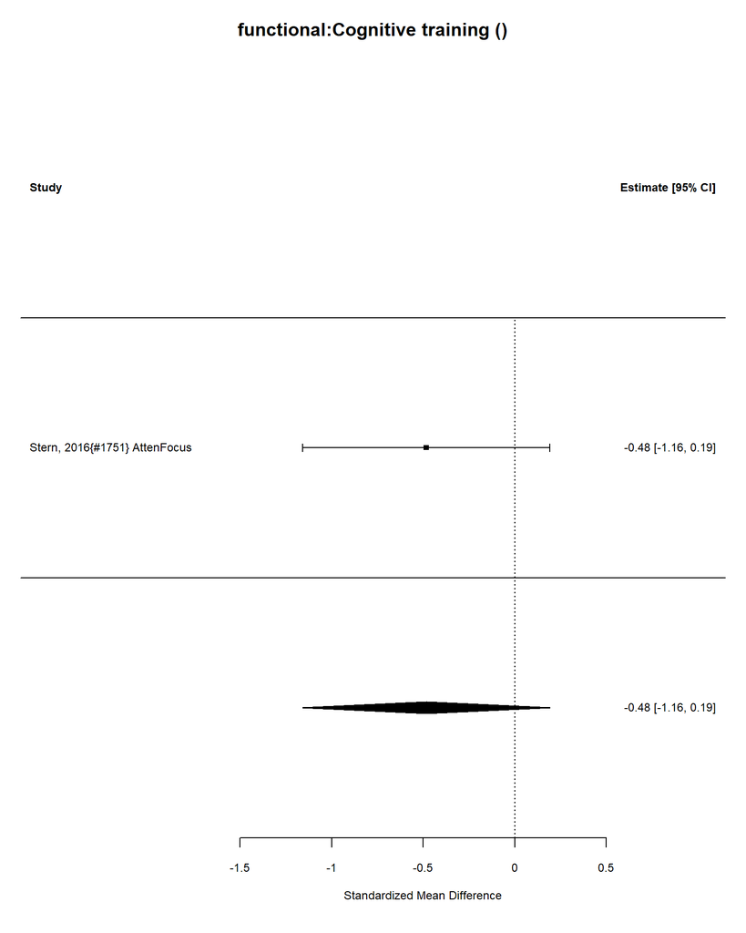

| estimate | conf.low | conf.high |
| --- | --- | --- |
| -0.48 | -1.16 | 0.19 |

Number of studies = 1

Intervention sample = 26

Control sample = 13

Total sample = 39.

I-squared = 0 %

Convert Effect Size to Real Units

Estimated effect in original units = -0.53.

### Outcome: functional:categorical Intervention: Cognitive training

Outcome name: functional Analyzing 1 studies.

Analyzing 1 studies.

### Control Types

| control | n |
| --- | --- |
| Attention-matched control | 1 |

| ID | measure | yi | se | study.design |
| --- | --- | --- | --- | --- |
| Stern, 2016{#1751} AttenFocus | COPM (Canadian Occupational Performance Measure) clinically significant change (2 or more points) | 1.1 | 1.03 | RCT |

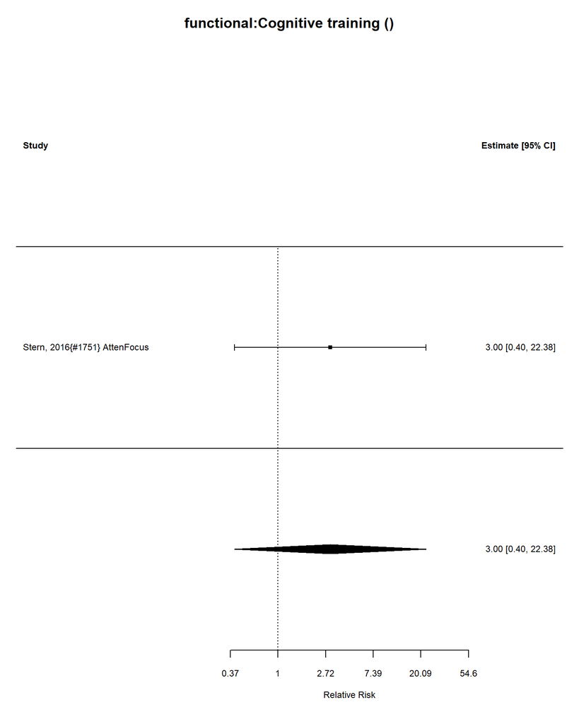

Number of studies = 1  
Intervention sample = 26  
Control sample = 13  
Total sample = 39

### Relative Risk Estimate

|  | estimate | se | zval | pval | ci.lb | ci.ub |
| --- | --- | --- | --- | --- | --- | --- |
| intrcpt | 3.004166 | 2.801066 | 2.915379 | 1.32313 | 0.4025242 | 22.42104 |

I-squared = 0 %

### Outcome: cognitive:continuous Intervention: Cognitive training

| ID | measure | mean_ctrl_cont | SD_ctrl_cont | n_ctrl_cont | mean_int_cont | SD_int_cont | n_int_cont | yi | se | study.design |
| --- | --- | --- | --- | --- | --- | --- | --- | --- | --- | --- |
| Stern, 2016{#1751} AttenFocus | IntegNeuro working memory | 47.96 | 7.91 | 13 | 47.92 | 7.63 | 26 | -0.0050742 | 0.3396836 | RCT |
| Virta, 2010{#3410} CBT | CNSVS ( Central Nervous System Vital Signs computerized neurocognitive test battery) neurocognitive index | 102.50 | 10.10 | 10 | 97.60 | 11.90 | 9 | -0.4260837 | 0.4646382 | RCT |
| Dentz, 2020{#1256} Cogmed | WAIS-II (Wechsler Abbreviated Scale of Intelligence, 2nd ed.) Digit Span Verbal Working Memory | 9.95 | 2.24 | 21 | 11.43 | 3.51 | 23 | 0.4887516 | 0.3062872 | RCT |
| Mawjee, 2015{#1540} Cogmed | AQT (A Quick Test of Cognitive Speed) | 8.79 | 4.50 | 32 | 7.57 | 3.99 | 33 | 0.2837184 | 0.2493436 | RCT |
| ThinkNowInc, 2015{#10950} SAC | CPT (Conners Continuous Performance Test) reaction time variability, change from baseline | 1.84 | 14.80 | 30 | -6.65 | 13.75 | 29 | 0.5861061 | 0.2659460 | RCT |

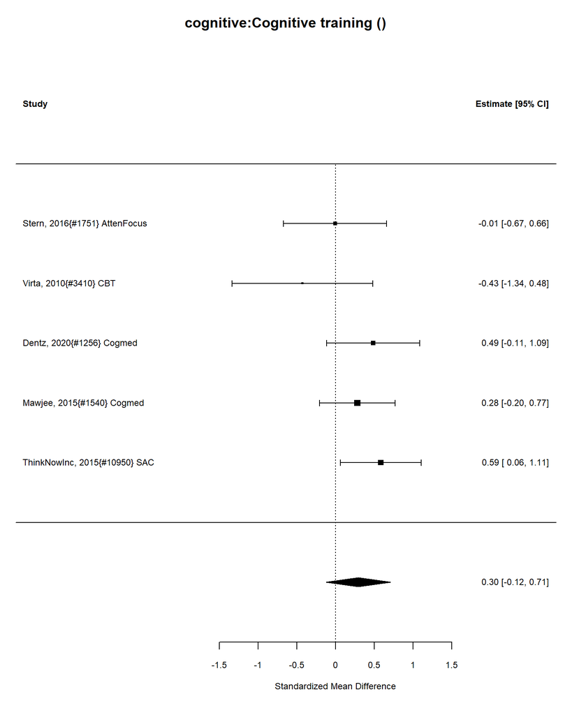

| estimate | conf.low | conf.high |
| --- | --- | --- |
| 0.3 | -0.12 | 0.71 |

Number of studies = 5

Intervention sample = 120

Control sample = 106

Total sample = 226.

I-squared = 0 %

Convert Effect Size to Real Units

Estimated effect in original units = 2.34.

##### Publication Bias Tests

###### Begg (non-parametric)

Rank Correlation Test for Funnel Plot Asymmetry Kendall’s tau = -0.6000, p = 0.2333

###### Egger (parametric)

Regression Test for Funnel Plot Asymmetry

Model: mixed-effects meta-regression model Predictor: standard error

Test for Funnel Plot Asymmetry: t = -2.2598, df = 3, p = 0.1089 Limit Estimate (as sei -> 0): b = 1.4612 (CI: -0.2129, 3.1353)

###### Trim and Fill

Estimate and Cis

|  | estimate | ci.lb | ci.ub |
| --- | --- | --- | --- |
| intrcpt | 0.36 | 0.08 | 0.64 |

### Meta-regression: stimulant vs non-stimulant

0 stimulant studies

0 nonstimulant studies

Not enough studies to compare stimulant and nonstimulant

### Meta-regression: AMPH vs MPH

### AMPH vs MPH meta-regression

0n AMPH studies

0 nMPH studies

Not enough studies to compare AMPH and MPH

## Meta-regression: Indirect comparison between combined vs(medication plus psychosocial) and medication

0 medication studies

0 combined studies

Not enough studies to compare medication and combined

## Meta-regression: Indirect comparison between combined vs(medication plus psychosocial) and psychosocial

1 psychosocial studies

0 combined studies

Not enough studies to compare psychosocial and combined

### Outcome: cognitive:categorical Intervention: Cognitive training

Outcome name: cognitive Analyzing 0 studies.

No data.

### Outcome: symptom:continuous Intervention: Cognitive training

| ID | measure | mean_ctrl_cont | SD_ctrl_cont | n_ctrl_cont | mean_int_cont | SD_int_cont | n_int_cont | yi | se | study.design |
| --- | --- | --- | --- | --- | --- | --- | --- | --- | --- | --- |
| Stern, 2016{#1751} AttenFocus | ASRS (Adult ADHD Self-Report Scale) | 36.92 | 8.92 | 13 | 36.73 | 10.00 | 26 | -0.0192610 | 0.3396901 | RCT |
| Virta, 2010{#3410} CBT | BADDS (Brown Attention Deficit Disorder Scale – Adult Version) | 70.00 | 14.20 | 10 | 61.20 | 17.80 | 9 | -0.5254635 | 0.4673085 | RCT |
| Dentz, 2020{#1256} Cogmed | CAARS (Conners’ Adult ADHD Rating Scale), Inattention Scale | 11.95 | 2.69 | 21 | 9.82 | 3.17 | 23 | -0.7087664 | 0.3111364 | RCT |
| Mawjee, 2015{#1540} Cogmed | ASRS (Adult ADHD Self-Report Scale) | 47.25 | 11.51 | 32 | 46.48 | 9.89 | 32 | -0.0708852 | 0.2500785 | RCT |
| ThinkNowInc, 2015{#10950} SAC | ASRS (Adult Attention Deficit Hyperactivity Disorder Self-Report Scale), inattentive subscale, change from baseline | 4.17 | 4.67 | 30 | 3.29 | 5.34 | 28 | 0.1734832 | 0.2632624 | RCT |

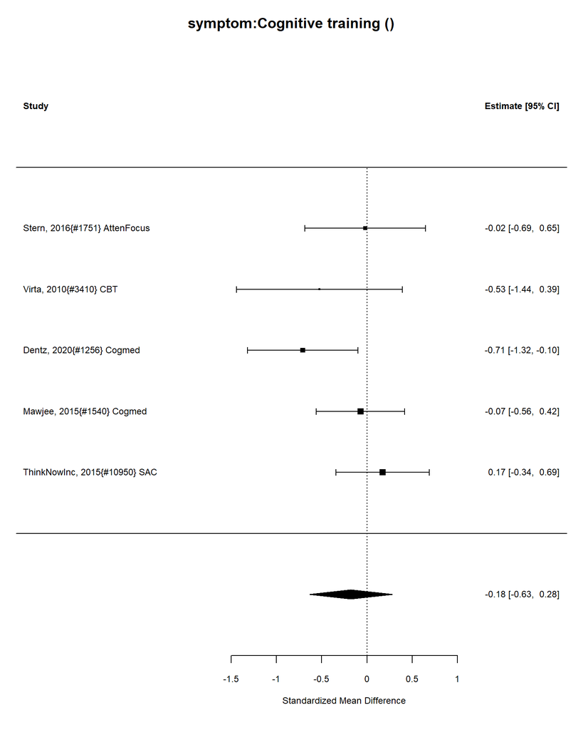

| estimate | conf.low | conf.high |
| --- | --- | --- |
| -0.18 | -0.63 | 0.28 |

Number of studies = 5

Intervention sample = 118

Control sample = 106

Total sample = 224.

I-squared = 31 %

Convert Effect Size to Real Units

Estimated effect in original units = -1.49.

##### Publication Bias Tests

###### Begg (non-parametric)

Rank Correlation Test for Funnel Plot Asymmetry Kendall’s tau = -0.2000, p = 0.8167

###### Egger (parametric)

Regression Test for Funnel Plot Asymmetry

Model: mixed-effects meta-regression model Predictor: standard error

Test for Funnel Plot Asymmetry: t = -1.0250, df = 3, p = 0.3808 Limit Estimate (as sei -> 0): b = 0.6085 (CI: -1.8761, 3.0931)

###### Trim and Fill

Estimate and Cis

|  | estimate | ci.lb | ci.ub |
| --- | --- | --- | --- |
| intrcpt | -0.18 | -0.63 | 0.28 |

### Meta-regression: stimulant vs non-stimulant

0 stimulant studies

0 nonstimulant studies

Not enough studies to compare stimulant and nonstimulant

### Meta-regression: AMPH vs MPH

### AMPH vs MPH meta-regression

0n AMPH studies

0 nMPH studies

Not enough studies to compare AMPH and MPH

## Meta-regression: Indirect comparison between combined vs(medication plus psychosocial) and medication

0 medication studies

0 combined studies

Not enough studies to compare medication and combined

## Meta-regression: Indirect comparison between combined vs(medication plus psychosocial) and psychosocial

1 psychosocial studies

0 combined studies

Not enough studies to compare psychosocial and combined

### Outcome: symptom:categorical Intervention: Cognitive training

Outcome name: symptom Analyzing 0 studies.

No data.

### Outcome: substance_use:continuous Intervention: Cognitive training

No data #1.

### Outcome: substance_use:categorical Intervention: Cognitive training

Outcome name: substance_use Analyzing 0 studies.

No data.

### Outcome: relationship:continuous Intervention: Cognitive training

No data #1.

### Outcome: relationship:categorical Intervention: Cognitive training

Outcome name: relationship Analyzing 0 studies.

No data.

### Outcome: BP:continuous Intervention: Cognitive training

No data #1.

### Outcome: BP:categorical Intervention: Cognitive training

Outcome name: BP Analyzing 0 studies.

No data.

### Outcome: sleep_disturbance:continuous Intervention: Cognitive training

No data #1.

### Outcome: sleep_disturbance:categorical Intervention: Cognitive training

Outcome name: sleep_disturbance Analyzing 0 studies.

No data.

### Outcome: AEs:continuous Intervention: Cognitive training

No data #1.

### Outcome: AEs:categorical Intervention: Cognitive training

Outcome name: AEs Analyzing 1 studies.

Analyzing 1 studies.

### Control Types

| control | n |
| --- | --- |
| Attention-matched control | 1 |

| ID | measure | yi | se | study.design |
| --- | --- | --- | --- | --- |
| ThinkNowInc, 2015{#10950} SAC | Number of participants with adverse events | -0.03 | 1.98 | RCT |

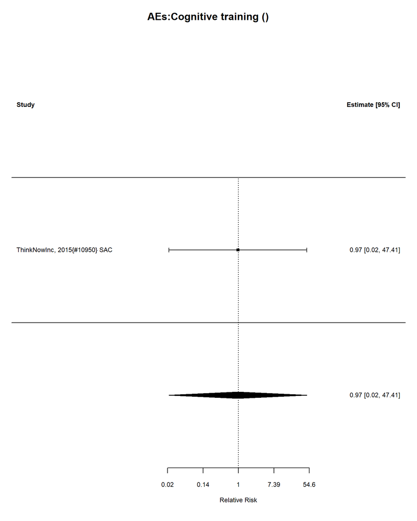

Number of studies = 1  
Intervention sample = 32  
Control sample = 31  
Total sample = 63

### Relative Risk Estimate

|  | estimate | se | zval | pval | ci.lb | ci.ub |
| --- | --- | --- | --- | --- | --- | --- |
| intrcpt | 0.9704455 | 7.242743 | 0.9801987 | 2.691235 | 0.0198411 | 47.46535 |

I-squared = 0 %

### Outcome: mortality:continuous Intervention: Cognitive training

No data #1.

### Outcome: mortality:categorical Intervention: Cognitive training

Outcome name: mortality Analyzing 2 studies.

Analyzing 2 studies.

### Control Types

| control | n |
| --- | --- |
| Attention-matched control | 2 |

| ID | measure | yi | se | study.design |
| --- | --- | --- | --- | --- |
| Rutgers, 2024{#15348} | All-Cause Mortality | 0.19 | 1.98 | RCT |
| ThinkNowInc, 2015{#10950} SAC | All-cause mortality | 0.03 | 1.98 | RCT |

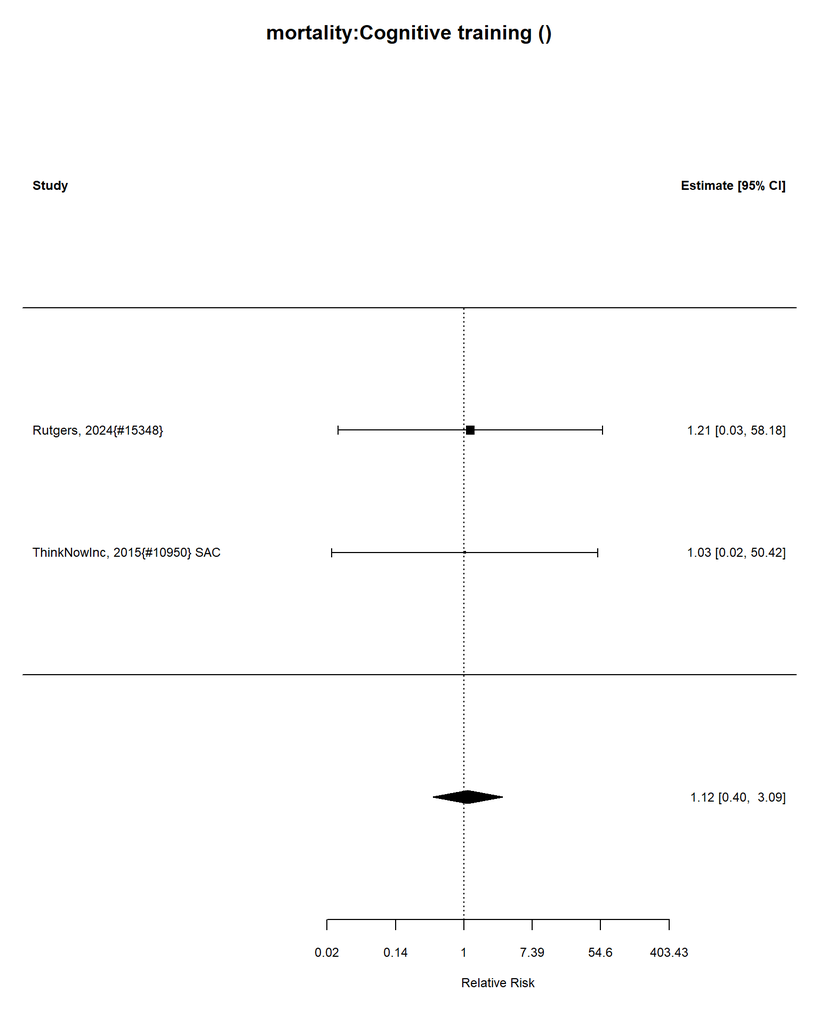

Number of studies = 2  
Intervention sample = 54  
Control sample = 49  
Total sample = 103

### Relative Risk Estimate

|  | estimate | se | tval | df | pval | ci.lb | ci.ub |
| --- | --- | --- | --- | --- | --- | --- | --- |
| intrcpt | 1.116278 | 1.083287 | 4.01485 | 2.718282 | 1.491825 | 0.4025242 | 3.095657 |

I-squared = 0 %

### Outcome: behavior:continuous Intervention: Cognitive training

No data #1.

### Outcome: behavior:categorical Intervention: Cognitive training

Outcome name: behavior Analyzing 0 studies.

No data.

### Outcome: appetite:continuous Intervention: Cognitive training

No data #1.

### Outcome: appetite:categorical Intervention: Cognitive training

Outcome name: appetite Analyzing 0 studies.

No data.

### Outcome: mood:continuous Intervention: Cognitive training

No data #1.

### Outcome: mood:categorical Intervention: Cognitive training

Outcome name: mood Analyzing 0 studies.

No data.

# Intervention: Combined

### Outcome: functional:continuous Intervention: Combined

| ID | measure | mean_ctrl_cont | SD_ctrl_cont | n_ctrl_cont | mean_int_cont | SD_int_cont | n_int_cont | yi | se | study.design |
| --- | --- | --- | --- | --- | --- | --- | --- | --- | --- | --- |
| Corbisiero, 2018{#2278} CBT+S-MPH-ER vs S-MPH-ER | IMPAIR 1 derived from Adult ADHD Quality of Life Scale (AAQoL) and Sheehan Disability Scale (SDS) subscales for family and work | 1.40 | 0.576 | 20 | 1.32 | 0.581 | 15 | -0.1352050 | 0.3419471 | RCT |
| Emilsson, 2011{#1282} CBT+med vs med | RATE-S (Revised Adult ADHD Therapeutic Efficacy Scale) social functioning | 36.41 | 10.930 | 17 | 24.29 | 8.070 | 14 | -1.2103272 | 0.3922746 | RCT |
| Eto, 2025{#11254} CBT+med vs med | SDS (Sheehan Disability Scale) work/school subscale | 4.50 | 2.850 | 15 | 3.30 | 2.760 | 15 | -0.4161741 | 0.3690800 | RCT |
| Zhang, 2025{#11447} CBT+med vs med | SDS (Sheehan Disability Scale) | 17.21 | 6.020 | 43 | 16.59 | 6.180 | 43 | -0.1007200 | 0.2158022 | RCT |
| Weiss, 2006{#1846} Prob.th.+S-AMPH-DEX vs prob.th. | GAF (Global Assessment of Functioning) | 58.88 | 9.840 | 26 | 62.88 | 14.660 | 25 | -0.3166824 | 0.2818595 | RCT |

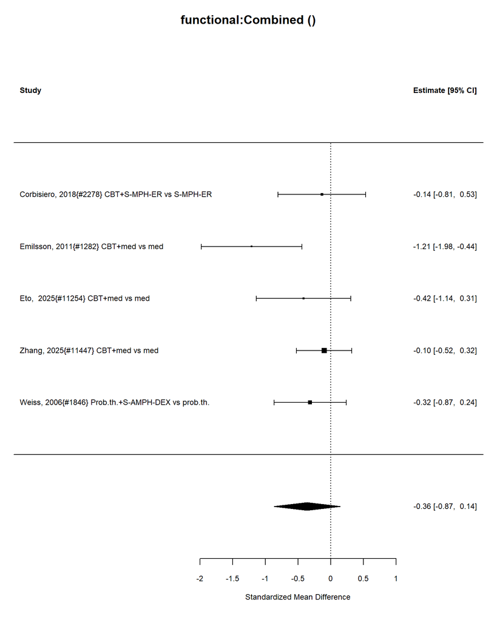

| estimate | conf.low | conf.high |
| --- | --- | --- |
| -0.36 | -0.87 | 0.14 |

Number of studies = 5

Intervention sample = 112

Control sample = 121

Total sample = 233.

I-squared = 34 %

Convert Effect Size to Real Units

Estimated effect in original units = -2.19.

##### Publication Bias Tests

###### Begg (non-parametric)

Rank Correlation Test for Funnel Plot Asymmetry Kendall’s tau = -0.8000, p = 0.0833

###### Egger (parametric)

Regression Test for Funnel Plot Asymmetry

Model: mixed-effects meta-regression model Predictor: standard error

Test for Funnel Plot Asymmetry: t = -1.7321, df = 3, p = 0.1817 Limit Estimate (as sei -> 0): b = 0.7135 (CI: -1.2414, 2.6683)

###### Trim and Fill

Estimate and Cis

|  | estimate | ci.lb | ci.ub |
| --- | --- | --- | --- |
| intrcpt | -0.36 | -0.87 | 0.14 |

### Meta-regression: stimulant vs non-stimulant

0 stimulant studies

0 nonstimulant studies

Not enough studies to compare stimulant and nonstimulant

### Meta-regression: AMPH vs MPH

### AMPH vs MPH meta-regression

0n AMPH studies

0 nMPH studies

Not enough studies to compare AMPH and MPH

## Meta-regression: Indirect comparison between combined vs(medication plus psychosocial) and medication

0 medication studies

5 combined studies

Not enough studies to compare medication and combined

## Meta-regression: Indirect comparison between combined vs(medication plus psychosocial) and psychosocial

0 psychosocial studies

5 combined studies

Not enough studies to compare psychosocial and combined

### Outcome: functional:categorical Intervention: Combined

Outcome name: functional Analyzing 0 studies.

No data.

### Outcome: cognitive:continuous Intervention: Combined

| ID | measure | mean_ctrl_cont | SD_ctrl_cont | n_ctrl_cont | mean_int_cont | SD_int_cont | n_int_cont | yi | se | study.design |
| --- | --- | --- | --- | --- | --- | --- | --- | --- | --- | --- |
| Zhang, 2025{#11447} CBT+med vs med | CPT-IP (Conners’ Continuous Performance Test Identical Pairs), 4-digit | 2.32 | 0.75 | 43 | 2.57 | 0.81 | 43 | 0.3174064 | 0.2170193 | RCT |
| van der Ham, 2026 {#15427} S-MPH, CBT | QbActivity (Quantified Behavior Test hyperactivity Z-score) | 2.36 | 1.34 | 25 | 2.32 | 1.07 | 22 | 0.0321986 | 0.2923450 | RCT |
| Konstenius, 2010{#1455} Skills+S-MPH-OROS vs skills | Stroop Test | 2.60 | 22.00 | 12 | 7.00 | 9.40 | 12 | 0.2511095 | 0.4098540 | RCT |

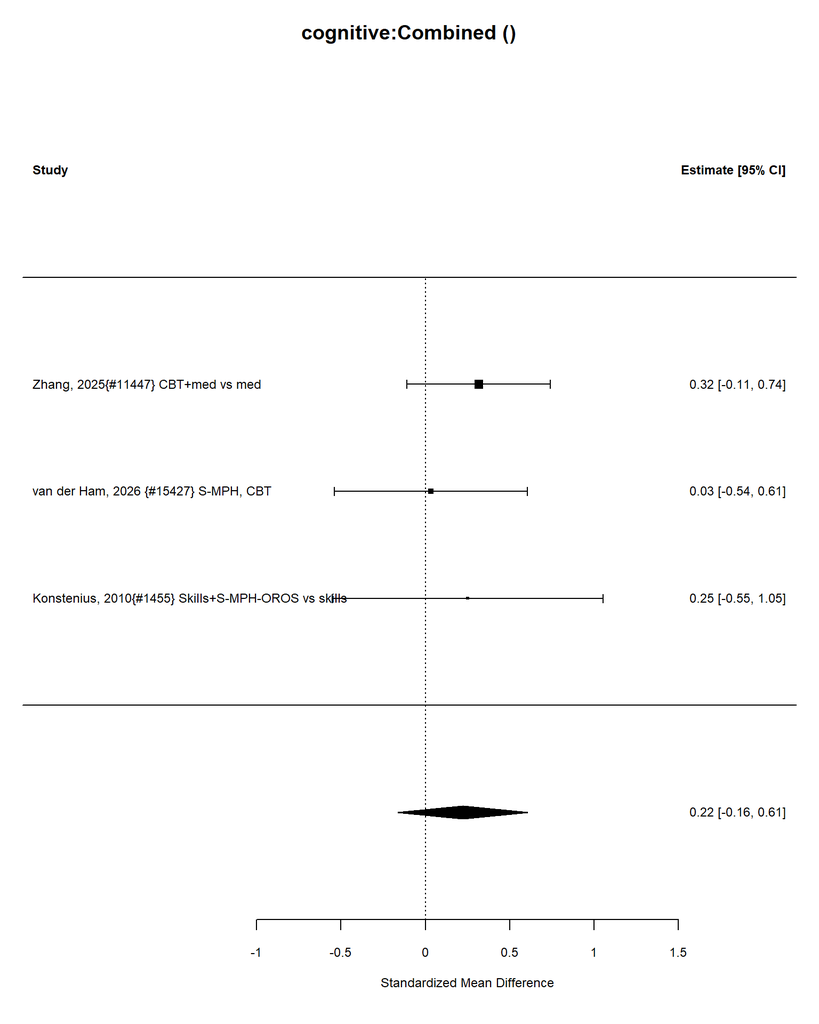

| estimate | conf.low | conf.high |
| --- | --- | --- |
| 0.22 | -0.16 | 0.61 |

Number of studies = 3

Intervention sample = 77

Control sample = 80

Total sample = 157.

I-squared = 0 %

Convert Effect Size to Real Units

Estimated effect in original units = 1.78.

##### Publication Bias Tests

###### Begg (non-parametric)

Rank Correlation Test for Funnel Plot Asymmetry Kendall’s tau = -0.3333, p = 1.0000

###### Egger (parametric)

Regression Test for Funnel Plot Asymmetry

Model: mixed-effects meta-regression model Predictor: standard error

Test for Funnel Plot Asymmetry: t = -0.4304, df = 1, p = 0.7412 Limit Estimate (as sei -> 0): b = 0.4179 (CI: -5.5667, 6.4026)

###### Trim and Fill

Estimate and Cis

|  | estimate | ci.lb | ci.ub |
| --- | --- | --- | --- |
| intrcpt | 0.22 | -0.16 | 0.61 |

### Meta-regression: stimulant vs non-stimulant

1 stimulant studies

0 nonstimulant studies

Not enough studies to compare stimulant and nonstimulant

### Meta-regression: AMPH vs MPH

### AMPH vs MPH meta-regression

0n AMPH studies

1 nMPH studies

Not enough studies to compare AMPH and MPH

## Meta-regression: Indirect comparison between combined vs(medication plus psychosocial) and medication

0 medication studies

3 combined studies

Not enough studies to compare medication and combined

## Meta-regression: Indirect comparison between combined vs(medication plus psychosocial) and psychosocial

0 psychosocial studies

3 combined studies

Not enough studies to compare psychosocial and combined

### Outcome: cognitive:categorical Intervention: Combined

Outcome name: cognitive Analyzing 0 studies.

No data.

### Outcome: symptom:continuous Intervention: Combined

| ID | measure | mean_ctrl_cont | SD_ctrl_cont | n_ctrl_cont | mean_int_cont | SD_int_cont | n_int_cont | yi | se | study.design |
| --- | --- | --- | --- | --- | --- | --- | --- | --- | --- | --- |
| Cherkasova, 2020{#1201} CBT+S vs CBT | CSS (Self-reported ADHD symptoms Current Symptoms Scale) | 20.27 | 6.870 | 46 | 15.83 | 6.840 | 42 | -0.6419677 | 0.2188384 | RCT |
| Schubiner, 2002{#1704} CBT+S-MPH vs CBT | Mean number of inattentive symptoms | 2.83 | 2.960 | 24 | 2.13 | 2.850 | 24 | -0.2369675 | 0.2896865 | RCT |
| Corbisiero, 2018{#2278} CBT+S-MPH-ER vs S-MPH-ER | CAARS (Conners’ Adult ADHD Rating Scale) | 0.65 | 0.380 | 20 | 0.67 | 0.400 | 15 | 0.0502853 | 0.3416179 | RCT |
| Emilsson, 2011{#1282} CBT+med vs med | K-SADS ADHD (Kiddie-Schedule for Affective Disorders and Schizophrenia ADHD section) | 37.08 | 4.720 | 13 | 31.70 | 4.330 | 8 | -1.1275357 | 0.4818641 | RCT |
| Eto, 2025{#11254} CBT+med vs med | ADHD-RS-IV (ADHD Rating Scale-IV) | 25.90 | 9.350 | 15 | 18.70 | 8.080 | 15 | -0.8016741 | 0.3795322 | RCT |
| Pan, 2022{#1611} CBT+med vs med | ADHD-RS (ADHD Rating Scale) | 20.81 | 11.010 | 49 | 20.72 | 8.140 | 49 | -0.0092228 | 0.2020316 | RCT |
| Safren, 2005{#1682} CBT+med vs med | ADHD-RS (ADHD Rating Scale) | 20.80 | 10.840 | 15 | 15.19 | 7.120 | 16 | -0.5998779 | 0.3673837 | RCT |
| Young, 2015{#1901} CBT+med vs med | K-SADS (Kiddie-Schedule for Affective Disorders and Schizophrenia) | 35.67 | 5.860 | 27 | 30.95 | 5.530 | 21 | -0.8117965 | 0.3025241 | RCT |
| Zhang, 2025{#11447} CBT+med vs med | ADHD-RS-IV (ADHD Rating Scale-IV) | 25.72 | 8.410 | 43 | 22.95 | 8.490 | 43 | -0.3248699 | 0.2170835 | RCT |
| Moritz, 2021{#1570} DBT+med vs med | ASRS (Adult ADHD Self-Report Scale) | 30.39 | 8.818 | 15 | 28.85 | 9.353 | 16 | -0.1648340 | 0.3600068 | RCT |
| Weiss, 2006{#1846} Prob.th.+S-AMPH-DEX vs prob.th. | ADHDRS-IV-Inv (ADHD Rating Scale for DSM-IV, investigator version) | 23.50 | 12.140 | 26 | 19.52 | 10.070 | 25 | -0.3506952 | 0.2822540 | RCT |
| Philipsen, 2015{#10719} S-MPH/CBT+S-MPH vs placebo | CAARS (Conners Adult ADHD Rating Scale) observer rated | 17.50 | 6.990 | 103 | 14.90 | 6.470 | 103 | -0.3846206 | 0.1406291 | RCT |
| Konstenius, 2010{#1455} Skills+S-MPH-OROS vs skills | CAARS:SV (Conners’ adult ADHD Rating Scale), investigator rating | 4.00 | 13.800 | 12 | 3.90 | 11.900 | 12 | 0.0074928 | 0.4082497 | RCT |

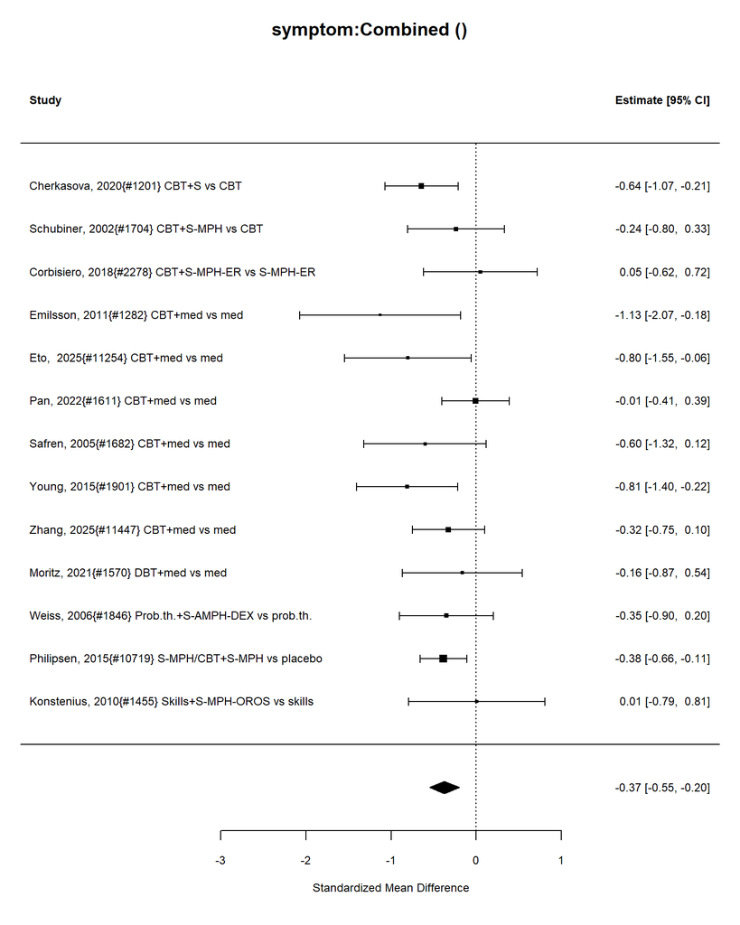

| estimate | conf.low | conf.high |
| --- | --- | --- |
| -0.37 | -0.55 | -0.2 |

Number of studies = 13

Intervention sample = 389

Control sample = 408

Total sample = 797.

I-squared = 7 %

Convert Effect Size to Real Units

Estimated effect in original units = -2.93.

##### Publication Bias Tests

###### Begg (non-parametric)

Rank Correlation Test for Funnel Plot Asymmetry Kendall’s tau = -0.1538, p = 0.5098

###### Egger (parametric)

Regression Test for Funnel Plot Asymmetry

Model: mixed-effects meta-regression model Predictor: standard error

Test for Funnel Plot Asymmetry: t = -0.7040, df = 11, p = 0.4961 Limit Estimate (as sei -> 0): b = -0.2051 (CI: -0.7685, 0.3584)

###### Trim and Fill

Estimate and Cis

|  | estimate | ci.lb | ci.ub |
| --- | --- | --- | --- |
| intrcpt | -0.35 | -0.5 | -0.2 |

### Meta-regression: stimulant vs non-stimulant

0 stimulant studies

0 nonstimulant studies

Not enough studies to compare stimulant and nonstimulant

### Meta-regression: AMPH vs MPH

### AMPH vs MPH meta-regression

0n AMPH studies

0 nMPH studies

Not enough studies to compare AMPH and MPH

## Meta-regression: Indirect comparison between combined vs(medication plus psychosocial) and medication

0 medication studies

13 combined studies

Not enough studies to compare medication and combined

## Meta-regression: Indirect comparison between combined vs(medication plus psychosocial) and psychosocial

0 psychosocial studies

13 combined studies

Not enough studies to compare psychosocial and combined

### Outcome: symptom:categorical Intervention: Combined

Outcome name: symptom Analyzing 4 studies.

Analyzing 4 studies.

### Control Types

| control | n |
| --- | --- |
| Other | 3 |
| Placebo | 1 |

| ID | measure | yi | se | study.design |
| --- | --- | --- | --- | --- |
| Levin, 2007{#1482} CBT+S-MPH vs CBT | AARS (Adult ADHD Rating Scale), participants with at least 30% reduction | -0.15 | 0.19 | RCT |
| Eto, 2025{#11254} CBT+med vs med | Proportion of participants with ≥30% improvement in ADHD-RS score | -1.50 | 0.69 | RCT |
| Weiss, 2006{#1846} Prob.th.+S-AMPH-DEX vs prob.th. | CGI-I-ADHD (Clinical Global Impression-Improvement Scale for ADHD Symptoms) | -1.05 | 0.51 | RCT |
| Philipsen, 2015{#10719} S-MPH/CBT+S-MPH vs placebo | CAARS, Observer-Rated, Number improving at least 30% | -0.08 | 0.20 | RCT |

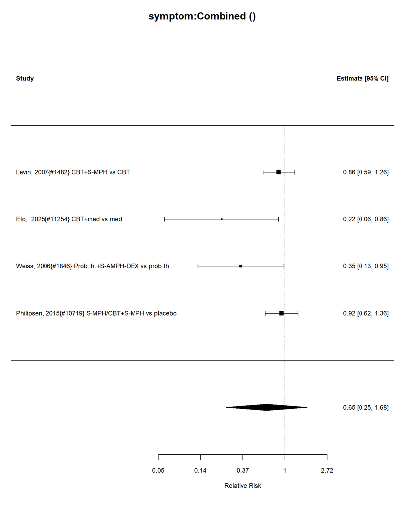

Number of studies = 4  
Intervention sample = 162  
Control sample = 139  
Total sample = 301

### Relative Risk Estimate

|  | estimate | se | tval | df | pval | ci.lb | ci.ub |
| --- | --- | --- | --- | --- | --- | --- | --- |
| intrcpt | 0.6440364 | 1.349859 | 0.2322363 | 20.08554 | 1.271249 | 0.2490753 | 1.682028 |

I-squared = 66 %

##### Publication Bias Tests

###### Begg (non-parametric)

```
Rank Correlation Test for Funnel Plot Asymmetry

Kendall's tau = -0.6667, p = 0.3333
```

###### Egger (parametric)

```
Regression Test for Funnel Plot Asymmetry

Model:     mixed-effects meta-regression model
Predictor: standard error

Test for Funnel Plot Asymmetry: t = -11.5090, df = 2, p = 0.0075
Limit Estimate (as sei -> 0):   b =  0.4373 (CI: 0.1588, 0.7157)
```

###### Trim and Fill

Estimate and CIs

|  | estimate | ci.lb | ci.ub |
| --- | --- | --- | --- |
| intrcpt | 0.74 | 0.39 | 1.41 |

###### int_stimulant vs int_nonstimulant meta-regression

### Meta-regression: stimulant vs non-stimulant

0 stimulant studies

0 nonstimulant studies

Not enough studies to compare stimulant and nonstimulant

### Meta-regression: AMPH vs MPH

### AMPH vs MPH meta-regression

0n AMPH studies

0 nMPH studies

Not enough studies to compare AMPH and MPH

## Meta-regression: Indirect comparison between combined vs(medication plus psychosocial) and medication

0 medication studies

4 combined studies

Not enough studies to compare medication and combined

## Meta-regression: Indirect comparison between combined vs(medication plus psychosocial) and psychosocial

0 psychosocial studies

4 combined studies

Not enough studies to compare psychosocial and combined

### Outcome: substance_use:continuous Intervention: Combined

| ID | measure | mean_ctrl_cont | SD_ctrl_cont | n_ctrl_cont | mean_int_cont | SD_int_cont | n_int_cont | yi | se | study.design |
| --- | --- | --- | --- | --- | --- | --- | --- | --- | --- | --- |
| Schubiner, 2002{#1704} CBT+S-MPH vs CBT | Days using cocaine in past 30 days | 14.58 | 2.91 | 24 | 15.42 | 3.29 | 24 | -0.2660224 | 0.2899491 | RCT |
| Konstenius, 2010{#1455} Skills+S-MPH-OROS vs skills | Amphetamine use during the study, self reported | 4.10 | 4.90 | 12 | 4.60 | 7.90 | 12 | -0.0734358 | 0.4083859 | RCT |

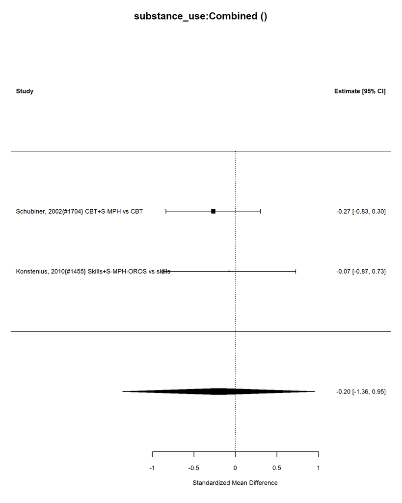

| estimate | conf.low | conf.high |
| --- | --- | --- |
| -0.2 | -1.36 | 0.95 |

Number of studies = 2

Intervention sample = 36

Control sample = 36

Total sample = 72.

I-squared = 0 %

Convert Effect Size to Real Units

Estimated effect in original units = -0.79.

### Outcome: substance_use:categorical Intervention: Combined

Outcome name: substance_use Analyzing 1 studies.

Analyzing 1 studies.

### Control Types

| control | n |
| --- | --- |
| Other | 1 |

| ID | measure | yi | se | study.design |
| --- | --- | --- | --- | --- |
| Levin, 2007{#1482} CBT+S-MPH vs CBT | Number of participants with 2 consecutive weeks of cocaine abstinence | 0.12 | 0.45 | RCT |

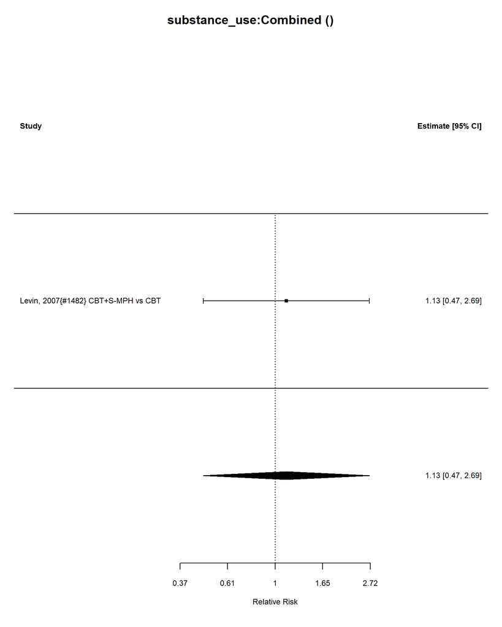

Number of studies = 1  
Intervention sample = 53  
Control sample = 53  
Total sample = 106

### Relative Risk Estimate

|  | estimate | se | zval | pval | ci.lb | ci.ub |
| --- | --- | --- | --- | --- | --- | --- |
| intrcpt | 1.127497 | 1.568312 | 1.29693 | 2.203396 | 0.4676664 | 2.691235 |

I-squared = 0 %

### Outcome: relationship:continuous Intervention: Combined

No data #1.

### Outcome: relationship:categorical Intervention: Combined

Outcome name: relationship Analyzing 0 studies.

No data.

### Outcome: BP:continuous Intervention: Combined

No data #1.

### Outcome: BP:categorical Intervention: Combined

Outcome name: BP Analyzing 0 studies.

No data.

### Outcome: sleep_disturbance:continuous Intervention: Combined

| ID | measure | mean_ctrl_cont | SD_ctrl_cont | n_ctrl_cont | mean_int_cont | SD_int_cont | n_int_cont | yi | se | study.design |
| --- | --- | --- | --- | --- | --- | --- | --- | --- | --- | --- |
| van der Ham, 2026 {#15427} S-MPH, CBT | PSQI (Pittsburgh Sleep Quality Index global score) | 9.51 | 3.12 | 25 | 8.17 | 2.65 | 22 | -0.4527364 | 0.2960322 | RCT |

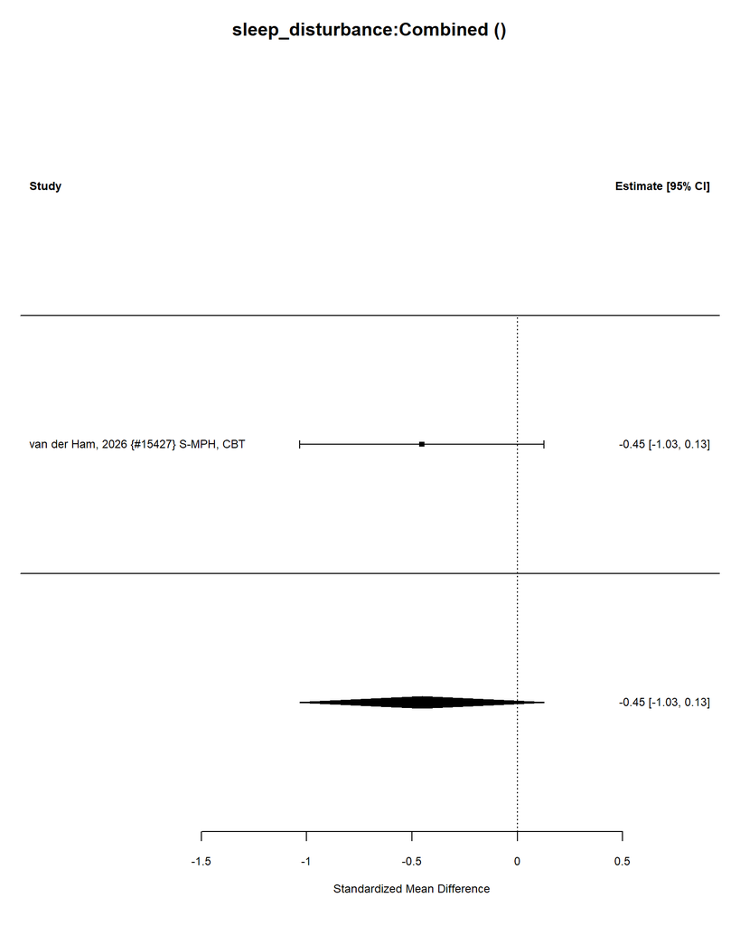

| estimate | conf.low | conf.high |
| --- | --- | --- |
| -0.45 | -1.03 | 0.13 |

Number of studies = 1

Intervention sample = 22

Control sample = 25

Total sample = 47.

I-squared = 0 %

Convert Effect Size to Real Units

Estimated effect in original units = -1.41.

### Outcome: sleep_disturbance:categorical Intervention: Combined

Outcome name: sleep_disturbance Analyzing 0 studies.

No data.

### Outcome: AEs:continuous Intervention: Combined

No data #1.

### Outcome: AEs:categorical Intervention: Combined

Outcome name: AEs Analyzing 1 studies.

Analyzing 1 studies.

### Control Types

| control | n |
| --- | --- |
| Other | 1 |

| ID | measure | yi | se | study.design |
| --- | --- | --- | --- | --- |
| Eto, 2025{#11254} CBT+med vs med | Number of participants with adverse events | 2.4 | 1.43 | RCT |

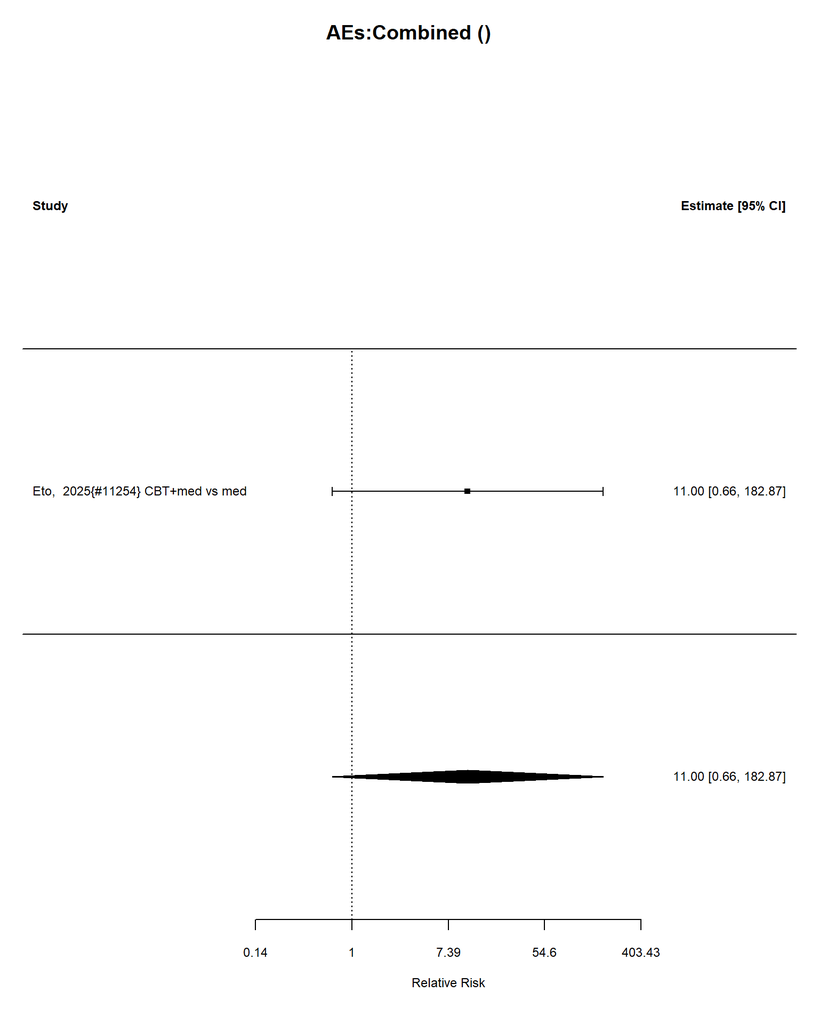

Number of studies = 1  
Intervention sample = 15  
Control sample = 15  
Total sample = 30

### Relative Risk Estimate

|  | estimate | se | zval | pval | ci.lb | ci.ub |
| --- | --- | --- | --- | --- | --- | --- |
| intrcpt | 11.02318 | 4.178699 | 5.312168 | 1.094174 | 0.6636503 | 183.0941 |

I-squared = 0 %

### Outcome: mortality:continuous Intervention: Combined

No data #1.

### Outcome: mortality:categorical Intervention: Combined

Outcome name: mortality Analyzing 1 studies.

Analyzing 1 studies.

### Control Types

| control | n |
| --- | --- |
| Placebo | 1 |

| ID | measure | yi | se | study.design |
| --- | --- | --- | --- | --- |
| Philipsen, 2015{#10719} S-MPH/CBT+S-MPH vs placebo | Mortality | 0 | 2 | RCT |

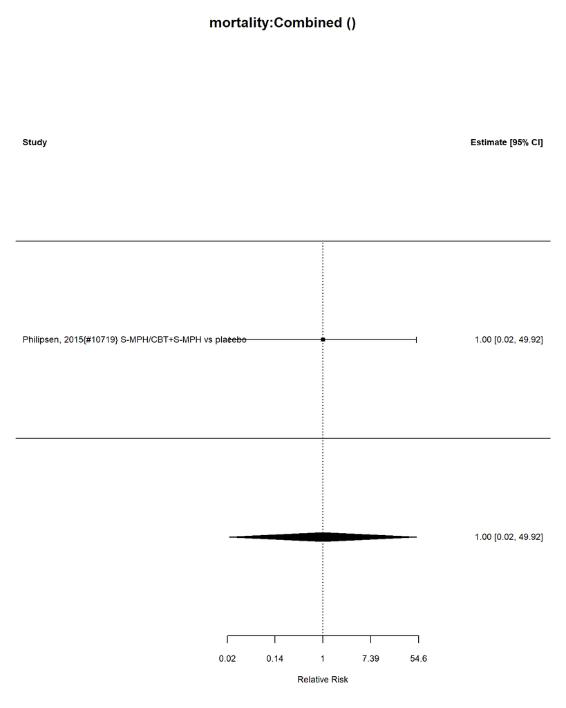

Number of studies = 1  
Intervention sample = 103  
Control sample = 103  
Total sample = 206

### Relative Risk Estimate

|  | estimate | se | zval | pval | ci.lb | ci.ub |
| --- | --- | --- | --- | --- | --- | --- |
| intrcpt | 1 | 7.389056 | 1 | 2.718282 | 0.0200405 | 49.89895 |

I-squared = 0 %

### Outcome: behavior:continuous Intervention: Combined

No data #1.

### Outcome: behavior:categorical Intervention: Combined

Outcome name: behavior Analyzing 0 studies.

No data.

### Outcome: appetite:continuous Intervention: Combined

No data #1.

### Outcome: appetite:categorical Intervention: Combined

Outcome name: appetite Analyzing 2 studies.

Analyzing 2 studies.

### Control Types

| control | n |
| --- | --- |
| Other | 2 |

| ID | measure | yi | se | study.design |
| --- | --- | --- | --- | --- |
| Schubiner, 2002{#1704} CBT+S-MPH vs CBT | Decreased appetite adverse event | -0.69 | 0.41 | RCT |
| Eto, 2025{#11254} CBT+med vs med | Growth suppression | 0.00 | 1.97 | RCT |

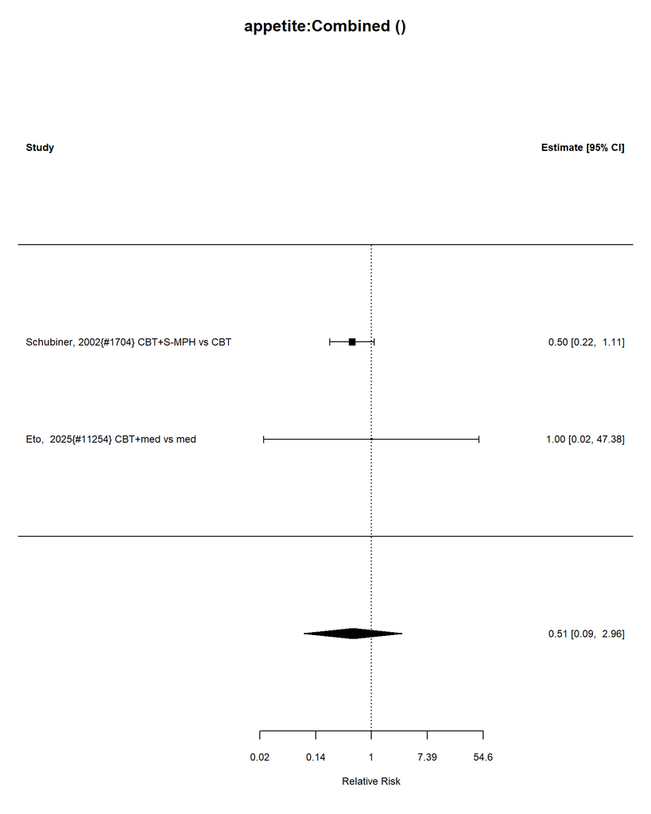

Number of studies = 2  
Intervention sample = 39  
Control sample = 39  
Total sample = 78

### Relative Risk Estimate

|  | estimate | se | tval | df | pval | ci.lb | ci.ub |
| --- | --- | --- | --- | --- | --- | --- | --- |
| intrcpt | 0.5168513 | 1.150274 | 0.0080668 | 2.718282 | 1.138828 | 0.0889216 | 2.974274 |

I-squared = 0 %

### Outcome: mood:continuous Intervention: Combined

No data #1.

### Outcome: mood:categorical Intervention: Combined

Outcome name: mood Analyzing 1 studies.

Analyzing 1 studies.

### Control Types

| control | n |
| --- | --- |
| Other | 1 |

| ID | measure | yi | se | study.design |
| --- | --- | --- | --- | --- |
| Schubiner, 2002{#1704} CBT+S-MPH vs CBT | Irritability | -0.07 | 0.25 | RCT |

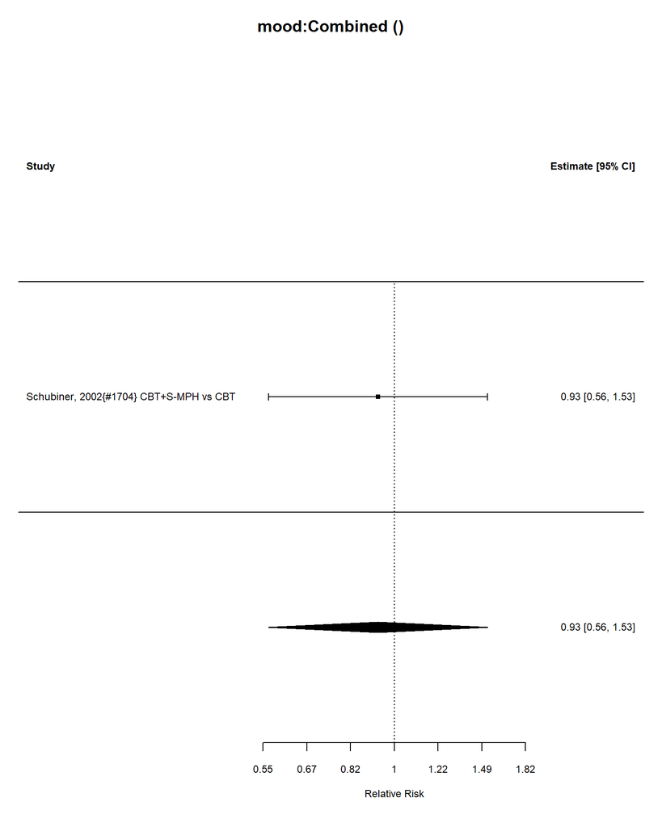

Number of studies = 1  
Intervention sample = 24  
Control sample = 24  
Total sample = 48

### Relative Risk Estimate

|  | estimate | se | zval | pval | ci.lb | ci.ub |
| --- | --- | --- | --- | --- | --- | --- |
| intrcpt | 0.9323938 | 1.284025 | 0.7482636 | 2.159766 | 0.5655254 | 1.537257 |

I-squared = 0 %

# Intervention: Exercise

### Outcome: functional:continuous Intervention: Exercise

| ID | measure | mean_ctrl_cont | SD_ctrl_cont | n_ctrl_cont | mean_int_cont | SD_int_cont | n_int_cont | yi | se | study.design |
| --- | --- | --- | --- | --- | --- | --- | --- | --- | --- | --- |
| Fritz, 2022{#2424} | BFIS (Barkley Functional Impairment Scale - Quick Screen) | 3.26 | 1.75 | 16 | 2.43 | 1.77 | 16 | -0.4596779 | 0.3581922 | RCT |

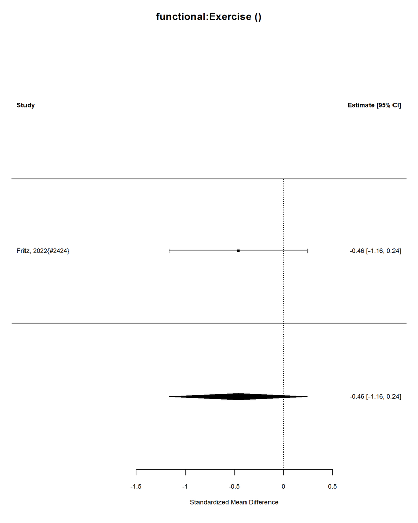

| estimate | conf.low | conf.high |
| --- | --- | --- |
| -0.46 | -1.16 | 0.24 |

Number of studies = 1

Intervention sample = 16

Control sample = 16

Total sample = 32.

I-squared = 0 %

Convert Effect Size to Real Units

Estimated effect in original units = -0.8.

### Outcome: functional:categorical Intervention: Exercise

Outcome name: functional Analyzing 0 studies.

No data.

### Outcome: cognitive:continuous Intervention: Exercise

| ID | measure | mean_ctrl_cont | SD_ctrl_cont | n_ctrl_cont | mean_int_cont | SD_int_cont | n_int_cont | yi | se | study.design |
| --- | --- | --- | --- | --- | --- | --- | --- | --- | --- | --- |
| Fritz, 2022{#2424} | NIH Toolbox Flanker, Inhibitory Control and Attention Test, Flanker Scaled Score 0–10 | 8.94 | 0.92 | 16 | 9.06 | 0.56 | 16 | 0.1535898 | 0.3540743 | RCT |
| Kouhbanani, 2022{#13855} | CPT (Continuous Performance Task), reaction time | 10.07 | 0.78 | 27 | 8.68 | 0.47 | 25 | 2.1064456 | 0.3459792 | RCT |
| Svedell, 2023{#3336} | Go reaction time | -4.50 | 20.20 | 5 | 8.40 | 9.30 | 9 | 0.8675683 | 0.5813711 | RCT |

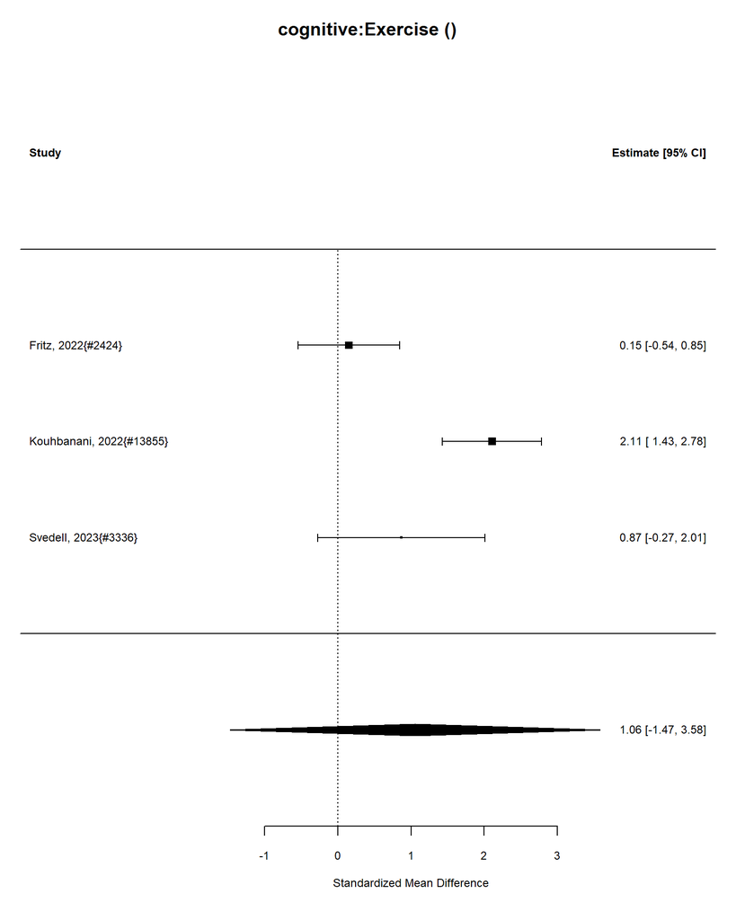

| estimate | conf.low | conf.high |
| --- | --- | --- |
| 1.06 | -1.47 | 3.58 |

Number of studies = 3

Intervention sample = 50

Control sample = 48

Total sample = 98.

I-squared = 84 %

Convert Effect Size to Real Units

Estimated effect in original units = 7.7.

##### Publication Bias Tests

###### Begg (non-parametric)

Rank Correlation Test for Funnel Plot Asymmetry Kendall’s tau = -0.3333, p = 1.0000

###### Egger (parametric)

Regression Test for Funnel Plot Asymmetry

Model: mixed-effects meta-regression model Predictor: standard error

Test for Funnel Plot Asymmetry: t = -0.1827, df = 1, p = 0.8849 Limit Estimate (as sei -> 0): b = 1.6307 (CI: -40.0496, 43.3111)

###### Trim and Fill

Estimate and Cis

|  | estimate | ci.lb | ci.ub |
| --- | --- | --- | --- |
| intrcpt | 1.06 | -1.47 | 3.58 |

### Meta-regression: stimulant vs non-stimulant

0 stimulant studies

0 nonstimulant studies

Not enough studies to compare stimulant and nonstimulant

### Meta-regression: AMPH vs MPH

### AMPH vs MPH meta-regression

0n AMPH studies

0 nMPH studies

Not enough studies to compare AMPH and MPH

## Meta-regression: Indirect comparison between combined vs(medication plus psychosocial) and medication

0 medication studies

0 combined studies

Not enough studies to compare medication and combined

## Meta-regression: Indirect comparison between combined vs(medication plus psychosocial) and psychosocial

0 psychosocial studies

0 combined studies

Not enough studies to compare psychosocial and combined

### Outcome: cognitive:categorical Intervention: Exercise

Outcome name: cognitive Analyzing 0 studies.

No data.

### Outcome: symptom:continuous Intervention: Exercise

| ID | measure | mean_ctrl_cont | SD_ctrl_cont | n_ctrl_cont | mean_int_cont | SD_int_cont | n_int_cont | yi | se | study.design |
| --- | --- | --- | --- | --- | --- | --- | --- | --- | --- | --- |
| Svedell, 2023{#3336} | ASRS (Adult ADHD Self-Report Scale) | 46.27 | 11.35 | 11 | 36.6 | 9.33 | 30 | -0.9590656 | 0.3680483 | RCT |

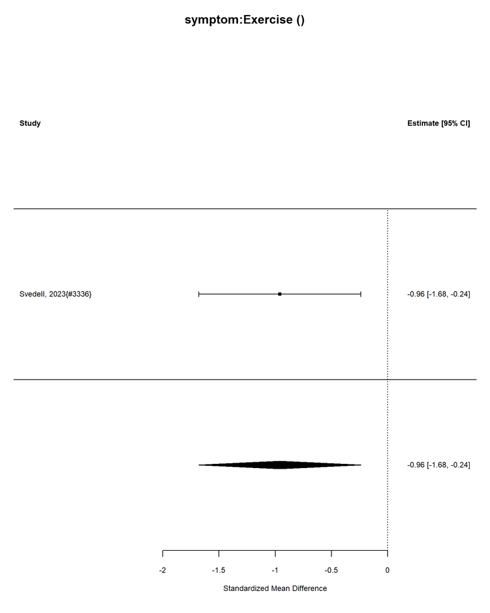

| estimate | conf.low | conf.high |
| --- | --- | --- |
| -0.96 | -1.68 | -0.24 |

Number of studies = 1

Intervention sample = 30

Control sample = 11

Total sample = 41.

I-squared = 0 %

Convert Effect Size to Real Units

Estimated effect in original units = -10.89.

### Outcome: symptom:categorical Intervention: Exercise

Outcome name: symptom Analyzing 1 studies.

Analyzing 1 studies.

### Control Types

| control | n |
| --- | --- |
| TAU | 1 |

| ID | measure | yi | se | study.design |
| --- | --- | --- | --- | --- |
| Svedell, 2023{#3336} | ASRS (Adult ADHD Self-Report Scale) | -1.95 | 1.4 | RCT |

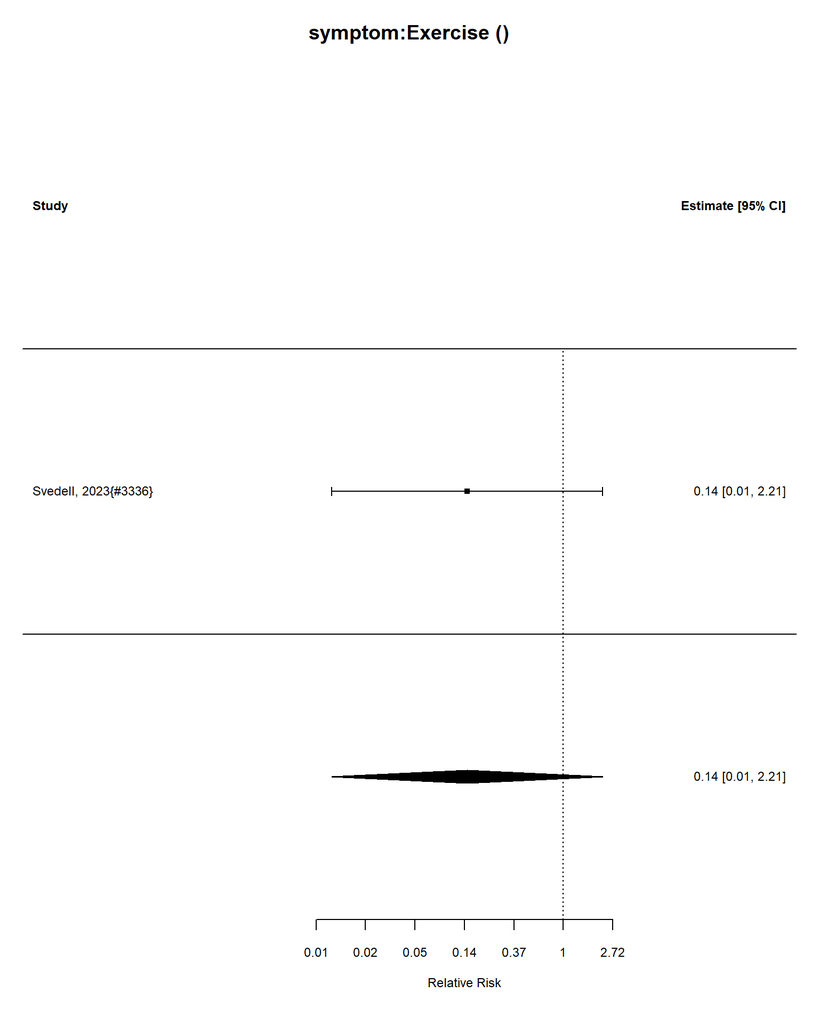

Number of studies = 1  
Intervention sample = 5  
Control sample = 5  
Total sample = 10

### Relative Risk Estimate

|  | estimate | se | zval | pval | ci.lb | ci.ub |
| --- | --- | --- | --- | --- | --- | --- |
| intrcpt | 0.1422741 | 4.0552 | 0.2490753 | 1.173511 | 0.009279 | 2.203396 |

I-squared = 0 %

### Outcome: substance_use:continuous Intervention: Exercise

No data #1.

### Outcome: substance_use:categorical Intervention: Exercise

Outcome name: substance_use Analyzing 0 studies.

No data.

### Outcome: relationship:continuous Intervention: Exercise

No data #1.

### Outcome: relationship:categorical Intervention: Exercise

Outcome name: relationship Analyzing 0 studies.

No data.

### Outcome: BP:continuous Intervention: Exercise

No data #1.

### Outcome: BP:categorical Intervention: Exercise

Outcome name: BP Analyzing 0 studies.

No data.

### Outcome: sleep_disturbance:continuous Intervention: Exercise

| ID | measure | mean_ctrl_cont | SD_ctrl_cont | n_ctrl_cont | mean_int_cont | SD_int_cont | n_int_cont | yi | se | study.design |
| --- | --- | --- | --- | --- | --- | --- | --- | --- | --- | --- |
| Svedell, 2023{#3336} | ISI (Insomnia Severity Index) | 11.45 | 5.57 | 11 | 10.9 | 6.93 | 29 | -0.0816841 | 0.3542249 | RCT |

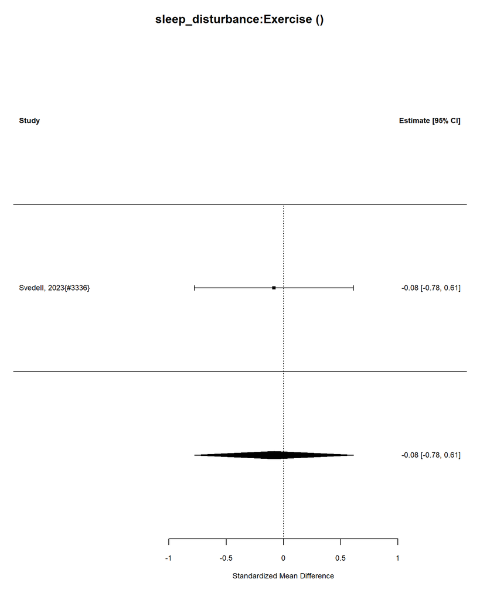

| estimate | conf.low | conf.high |
| --- | --- | --- |
| -0.08 | -0.78 | 0.61 |

Number of studies = 1

Intervention sample = 29

Control sample = 11

Total sample = 40.

I-squared = 0 %

Convert Effect Size to Real Units

Estimated effect in original units = -0.45.

### Outcome: sleep_disturbance:categorical Intervention: Exercise

Outcome name: sleep_disturbance Analyzing 0 studies.

No data.

### Outcome: AEs:continuous Intervention: Exercise

No data #1.

### Outcome: AEs:categorical Intervention: Exercise

Outcome name: AEs Analyzing 0 studies.

No data.

### Outcome: mortality:continuous Intervention: Exercise

No data #1.

### Outcome: mortality:categorical Intervention: Exercise

Outcome name: mortality Analyzing 0 studies.

No data.

### Outcome: behavior:continuous Intervention: Exercise

No data #1.

### Outcome: behavior:categorical Intervention: Exercise

Outcome name: behavior Analyzing 0 studies.

No data.

### Outcome: appetite:continuous Intervention: Exercise

No data #1.

### Outcome: appetite:categorical Intervention: Exercise

Outcome name: appetite Analyzing 0 studies.

No data.

### Outcome: mood:continuous Intervention: Exercise

No data #1.

### Outcome: mood:categorical Intervention: Exercise

Outcome name: mood Analyzing 0 studies.

No data.

# Intervention: Medication

### Outcome: functional:continuous Intervention: Medication

| ID | measure | mean_ctrl_cont | SD_ctrl_cont | n_ctrl_cont | mean_int_cont | SD_int_cont | n_int_cont | yi | se | study.design |
| --- | --- | --- | --- | --- | --- | --- | --- | --- | --- | --- |
| Adler, 2008{#1063} NS-NRI-ATX | EWPS (Endicott Work Productivity Scale) | 15.60 | 16.000 | 139 | 16.20 | 18.400 | 271 | -0.0339802 | 0.1043345 | RCT |
| Marchant, 2011{#10688} NS-NRI-ATX | SDS (Sheehan Disability Scale), change from baseline | 4.00 | 6.900 | 124 | 4.40 | 7.900 | 124 | -0.0537665 | 0.1270231 | RCT |
| Michelson, 2003{#1554} NS-NRI-ATX | SDS (Sheehan Disability Scale), change from baseline | 2.90 | 7.700 | 134 | 4.50 | 8.300 | 133 | -0.1993214 | 0.1227024 | RCT |
| Upadhyaya, 2013{#8658} NS-NRI-ATX | AAQoL (Adult Attention-Deficit/Hyperactivity Disorder Quality of Life) assessing functional impairment | 67.20 | 16.800 | 258 | 71.30 | 15.400 | 266 | -0.2542214 | 0.0877328 | RCT |
| Wang, 2022{#1833} NS-NRI-ATX | AAQoL-29 (Adult ADHD Quality of Life-29) assessing functional impairments and quality of life | 37.23 | 11.120 | 36 | 43.51 | 9.800 | 36 | -0.5927440 | 0.2408225 | RCT |
| Dupaul, 2012{#1272} S-AMPH-LDX | BRIEF-A (Behavior Rating Inventory of Executive Function–Adult) General Executive Composite | 59.59 | 11.091 | 22 | 51.55 | 11.835 | 22 | -0.6884123 | 0.3103135 | RCT |
| Babinski, 2017{#1091} S-AMPH-LDX-ER | SDS (Sheehan Disability Scale) | 4.35 | 2.020 | 10 | 2.28 | 2.440 | 10 | -0.8850208 | 0.4685953 | RCT |
| Biederman, 2012{#1115} S-AMPH-LDX-ER | GAF (Global Assessment of Functioning scale) | 58.90 | 4.800 | 30 | 63.50 | 4.400 | 31 | -0.9870194 | 0.2712503 | RCT |
| Spencer, 2008{#1743} S-AMPH-MAS-ER | AIM-A (Adult ADHD Impact Module), Performance and function | 35.30 | 22.550 | 132 | 55.70 | 26.030 | 136 | -0.8344469 | 0.1273883 | RCT |
| Huss, 2013{#1403} S-MPH-HCL-ER | SDS (Sheehan Disability Scale) total score decrease from baseline | 2.90 | 7.470 | 152 | 6.10 | 7.310 | 148 | -0.4318387 | 0.1168183 | RCT |
| Medori, 2008{#1549} S-MPH-OROS-ER | SDS (Sheehan Disability Scale) | -2.20 | 3.970 | 74 | -5.10 | 7.070 | 75 | -0.5023258 | 0.1664139 | RCT |

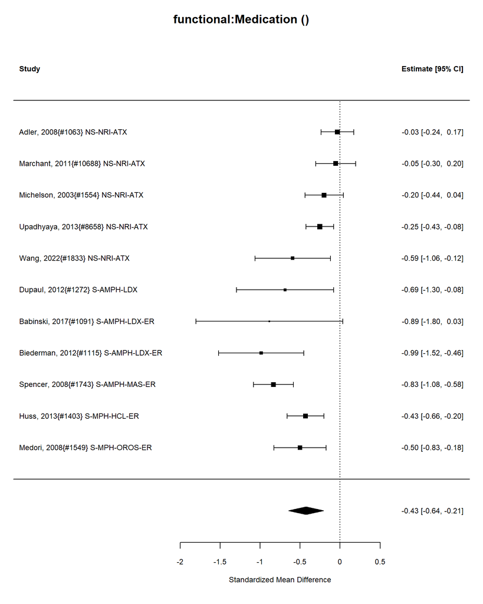

| estimate | conf.low | conf.high |
| --- | --- | --- |
| -0.43 | -0.64 | -0.21 |

Number of studies = 11

Intervention sample = 1252

Control sample = 1111

Total sample = 2363.

I-squared = 78 %

Convert Effect Size to Real Units

Estimated effect in original units = -4.28.

##### Publication Bias Tests

###### Begg (non-parametric)

Rank Correlation Test for Funnel Plot Asymmetry Kendall’s tau = -0.5273, p = 0.0264

###### Egger (parametric)

Regression Test for Funnel Plot Asymmetry

Model: mixed-effects meta-regression model Predictor: standard error

Test for Funnel Plot Asymmetry: t = -2.4187, df = 9, p = 0.0387 Limit Estimate (as sei -> 0): b = -0.0417 (CI: -0.4299, 0.3465)

###### Trim and Fill

Estimate and Cis

|  | estimate | ci.lb | ci.ub |
| --- | --- | --- | --- |
| intrcpt | -0.37 | -0.56 | -0.18 |

### Meta-regression: stimulant vs non-stimulant

6 stimulant studies

5 nonstimulant studies

| term | type | estimate | std.error | statistic | p.value |
| --- | --- | --- | --- | --- | --- |
| intercept | summary | -0.179 | 0.077 | -2.319 | 0.046 |
| stimulant_studyTRUE | summary | -0.470 | 0.120 | -3.925 | 0.003 |

### Meta-regression: AMPH vs MPH

### AMPH vs MPH meta-regression

4n AMPH studies

2 nMPH studies

| term | type | estimate | std.error | statistic | p.value |
| --- | --- | --- | --- | --- | --- |
| intercept | summary | -0.455 | 0.039 | -11.693 | 0.000 |
| AMPHTRUE | summary | -0.388 | 0.058 | -6.702 | 0.003 |

## Meta-regression: Indirect comparison between combined vs(medication plus psychosocial) and medication

11 medication studies

0 combined studies

Not enough studies to compare medication and combined

## Meta-regression: Indirect comparison between combined vs(medication plus psychosocial) and psychosocial

0 psychosocial studies

0 combined studies

Not enough studies to compare psychosocial and combined

### Outcome: functional:categorical Intervention: Medication

Outcome name: functional Analyzing 0 studies.

No data.

### Outcome: cognitive:continuous Intervention: Medication

| ID | measure | mean_ctrl_cont | SD_ctrl_cont | n_ctrl_cont | mean_int_cont | SD_int_cont | n_int_cont | yi | se | study.design |
| --- | --- | --- | --- | --- | --- | --- | --- | --- | --- | --- |
| Taylor, 2000{#1778} S-AMPH-D-IR | COWAT (Controlled Oral Word Association Test) | 75.40 | 25.000 | 21 | 86.50 | 10.600 | 21 | 0.5671747 | 0.3147502 | RCT |
| Dupaul, 2012{#1272} S-AMPH-LDX | CPT-II (Conners’ Continuous Performance Test) Hit Reaction Time–Standard Error | 54.03 | 11.634 | 21 | 46.54 | 9.726 | 21 | 0.6853359 | 0.3175367 | RCT |
| Kollins, 2014{#1453} S-AMPH-LDX-ER | CPT (Conner’s Continuous Performance Test) commission errors | 11.23 | 9.770 | 15 | 14.92 | 10.800 | 17 | -0.3481225 | 0.3569086 | RCT |
| Wigal, 2010{#1865} S-AMPH-LDX-ER | PERMP (Permanent Product Measure of Performance) total score | 287.60 | 81.450 | 104 | 312.70 | 94.420 | 104 | 0.2836272 | 0.1393705 | RCT |
| Levin, 2001{#1478} S-MPH | C-CPT (Conners Continuous Performance Test) attention | 3.00 | 0.530 | 7 | 3.50 | 0.900 | 9 | 0.6188841 | 0.5156913 | RCT |
| Schrantee, 2016{#1703} S-MPH-HCL-IR | N-Back Task (Visuo-Spatial Working Memory Performance) | 6.38 | 6.390 | 49 | 7.13 | 5.880 | 49 | -0.1211868 | 0.2022159 | RCT |
| Kuperman, 2001{#1461} S-MPH-IR | HVLT (Hopkins Verbal Learning Test), Immediate Recall, Change From Baseline | -0.20 | 5.200 | 10 | 2.00 | 4.100 | 8 | 0.4410256 | 0.4800030 | RCT |

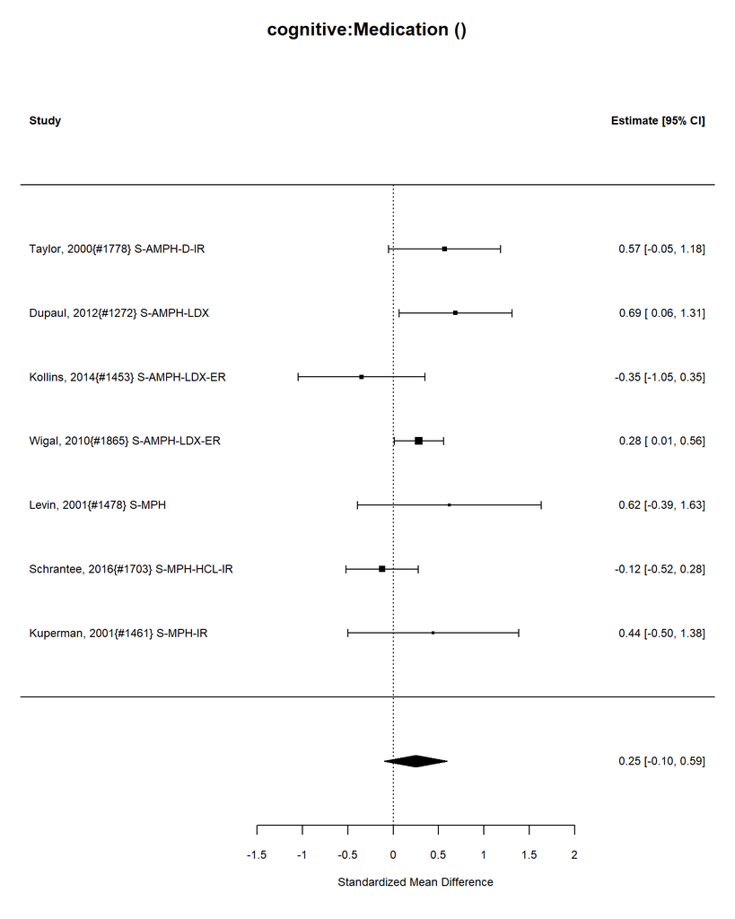

| estimate | conf.low | conf.high |
| --- | --- | --- |
| 0.25 | -0.1 | 0.59 |

Number of studies = 7

Intervention sample = 229

Control sample = 227

Total sample = 456.

I-squared = 42 %

Convert Effect Size to Real Units

Estimated effect in original units = 4.98.

##### Publication Bias Tests

###### Begg (non-parametric)

Rank Correlation Test for Funnel Plot Asymmetry Kendall’s tau = 0.1429, p = 0.7726

###### Egger (parametric)

Regression Test for Funnel Plot Asymmetry

Model: mixed-effects meta-regression model Predictor: standard error

Test for Funnel Plot Asymmetry: t = 0.6766, df = 5, p = 0.5287 Limit Estimate (as sei -> 0): b = 0.0178 (CI: -0.9627, 0.9983)

###### Trim and Fill

Estimate and Cis

|  | estimate | ci.lb | ci.ub |
| --- | --- | --- | --- |
| intrcpt | 0.18 | -0.09 | 0.46 |

### Meta-regression: stimulant vs non-stimulant

7 stimulant studies

0 nonstimulant studies

Not enough studies to compare stimulant and nonstimulant

### Meta-regression: AMPH vs MPH

### AMPH vs MPH meta-regression

4n AMPH studies

3 nMPH studies

| term | type | estimate | std.error | statistic | p.value |
| --- | --- | --- | --- | --- | --- |
| intercept | summary | 0.130 | 0.253 | 0.515 | 0.628 |
| AMPHTRUE | summary | 0.183 | 0.314 | 0.584 | 0.585 |

## Meta-regression: Indirect comparison between combined vs(medication plus psychosocial) and medication

7 medication studies

0 combined studies

Not enough studies to compare medication and combined

## Meta-regression: Indirect comparison between combined vs(medication plus psychosocial) and psychosocial

0 psychosocial studies

0 combined studies

Not enough studies to compare psychosocial and combined

### Outcome: cognitive:categorical Intervention: Medication

Outcome name: cognitive Analyzing 0 studies.

No data.

### Outcome: symptom:continuous Intervention: Medication

| ID | measure | mean_ctrl_cont | SD_ctrl_cont | n_ctrl_cont | mean_int_cont | SD_int_cont | n_int_cont | yi | se | study.design |
| --- | --- | --- | --- | --- | --- | --- | --- | --- | --- | --- |
| Adler, 2009{#1056} NS-NRI-ATX | CAARS (Conners’ Adult ADHD Rating Scale) | 25.60 | 10.600 | 155 | 20.90 | 11.30 | 151 | -0.4281251 | 0.1156444 | RCT |
| Adler, 2009{#1061} NS-NRI-ATX | AISRS (Adult ADHD Investigator Symptom Rating Scale) | 28.70 | 12.800 | 112 | 24.40 | 12.90 | 94 | -0.3335103 | 0.1408433 | RCT |
| Boehringer Ingelheim, 2022{#16134} NS-NRI-ATX | BIQ-11 (Barratt Impulsiveness Questionnaire v.11) | 0.10 | 4.690 | 30 | 2.30 | 4.75 | 28 | -0.4599217 | 0.2662163 | RCT |
| Durell, 2013{#214} NS-NRI-ATX | CAARS-Inv:SV (Investigator-Rated: Screening Version Total Adult ADHD Symptoms) | 30.20 | 11.100 | 199 | 26.10 | 11.40 | 192 | -0.3637962 | 0.1019936 | RCT |
| Goto, 2017{#1347} NS-NRI-ATX | CAARS-Inv: SV (Conners’ Adult ADHD Rating Scale–Investigator Rated: Screening Version), change from baseline | -8.80 | 9.600 | 195 | -14.30 | 10.40 | 191 | -0.5487147 | 0.1037006 | RCT |
| Lin, 2015{#1491} NS-NRI-ATX | ASRS (Adult ADHD Self-Report Scale) Inattention | 19.08 | 11.110 | 12 | 13.75 | 5.75 | 12 | -0.5817315 | 0.4167936 | RCT |
| Marchant, 2011{#10688} NS-NRI-ATX | CAARS-INV (Conners’ Adult ADHD Rating Scale – Investigator-rated), change from baseline | 6.70 | 9.300 | 124 | 10.50 | 10.90 | 124 | -0.3739181 | 0.1281051 | RCT |
| McRae-Clark, 2010{#1547} NS-NRI-ATX | CAARS-SELF (Conners’ Adult ADHD Rating Scales, Self-reported) change from baseline | -10.16 | 7.730 | 19 | -12.65 | 7.60 | 19 | -0.3180187 | 0.3264872 | RCT |
| Michelson, 2003{#1554} NS-NRI-ATX | CAARS-INV (Conners’ Adult ADHD Rating Scale – Investigator-rated), change from baseline | 6.00 | 9.300 | 134 | 9.50 | 10.10 | 133 | -0.3595527 | 0.1233839 | RCT |
| Sobanski, 2012{#1726} NS-NRI-ATX | CAARS (Conners’ Adult ADHD Rating Scales), Observer, change from baseline | 0.40 | 4.800 | 21 | 13.10 | 7.70 | 22 | -1.9326097 | 0.3694639 | RCT |
| Sutherland, 2012{#1764} NS-NRI-ATX | AISRS (Adult ADHD Investigator Symptom Rating Scale) | 22.90 | 14.200 | 47 | 18.20 | 11.20 | 97 | -0.3815640 | 0.1791407 | RCT |
| Upadhyaya, 2013{#8658} NS-NRI-ATX | CAARS-Inv:SV (Conners’ Adult ADHD Rating Scale – Investigator Screening Version) | 17.90 | 10.500 | 258 | 16.20 | 10.00 | 266 | -0.1656279 | 0.0875302 | RCT |
| Wang, 2022{#1833} NS-NRI-ATX | CAARS-S:S (Conners’ Adult ADHD Rating Scales-Self-Report: Short Version) | 72.80 | 8.910 | 36 | 67.79 | 8.79 | 36 | -0.5599981 | 0.2402776 | RCT |
| Weisler, 2012{#1844} NS-NRI-ATX | ADHD-RS-IV (Attention-Deficit/Hyperactivity Disorder Rating Scale, Version IV) change from baseline | -8.80 | 11.740 | 73 | -15.30 | 14.52 | 73 | -0.4897293 | 0.1679840 | RCT |
| Wilens, 2008{#1872} NS-NRI-ATX | AISRS (ADHD Investigator Symptom Rating Scale) change from baseline | 8.30 | 11.400 | 75 | 13.60 | 11.40 | 72 | -0.4625027 | 0.1671819 | RCT |
| Young, 2011{#1899} NS-NRI-ATX | CAARS (Conners’ Adult ADHD Rating Scale) change from baseline | 8.30 | 11.000 | 234 | 14.30 | 11.80 | 266 | -0.5240208 | 0.0911455 | RCT |
| Nasser, 2022{#1583} NS-NRI-VLX | AISRS (Adult ADHD Investigator Symptom Rating Scale) | 11.70 | 12.050 | 179 | 15.50 | 12.06 | 175 | -0.3145512 | 0.1069609 | RCT |
| Paterson, 1999{#1619} S-AMPH-D-IR | BSI (Brief Symptom Inventory) global severity index | 46.19 | 15.190 | 21 | 43.54 | 10.80 | 24 | -0.1998483 | 0.2995488 | RCT |
| Taylor, 2000{#1778} S-AMPH-D-IR | DSM-IV ADHD Behavior Checklist for Adults | 28.80 | 10.000 | 21 | 20.00 | 11.30 | 21 | -0.8091786 | 0.3209875 | RCT |
| Dupaul, 2012{#1272} S-AMPH-LDX | CAARS (Conners’ Adult ADHD Rating Scales) ADHD Index | 50.59 | 10.975 | 22 | 45.36 | 10.79 | 22 | -0.4719291 | 0.3056795 | RCT |
| Adler, 2008{#1053} S-AMPH-LDX-ER | ADHD-RS-IV (ADHD Rating Scale, Version IV), change from baseline | -8.20 | 11.260 | 62 | -18.60 | 11.38 | 122 | -0.9133285 | 0.1630721 | RCT |
| Babinski, 2017{#1091} S-AMPH-LDX-ER | ADHD-RS (ADHD Rating Scale) | 32.42 | 11.200 | 10 | 14.69 | 12.20 | 10 | -1.4498793 | 0.5025473 | RCT |
| Biederman, 2012{#1115} S-AMPH-LDX-ER | ADHD-RS (ADHD Rating Scale) | 25.00 | 9.900 | 30 | 13.20 | 10.20 | 31 | -1.1587077 | 0.2767604 | RCT |
| Kollins, 2014{#1453} S-AMPH-LDX-ER | CAARS (ADHD Conners’ Adult ADHD Rating Scales) self-report and observer short form | 61.92 | 11.460 | 15 | 54.00 | 15.33 | 17 | -0.5651115 | 0.3612202 | RCT |
| Wigal, 2010{#1865} S-AMPH-LDX-ER | ADHD-RS-IV (ADHD Rating Scale IV with adult prompts) | 28.80 | 9.400 | 117 | 17.30 | 8.20 | 115 | -1.2987681 | 0.1444922 | RCT |
| Cutler, 2022{#1248} S-AMPH-MAS-ER | AISRS (Adult ADHD Investigator Symptom Rating Scale) total, change from baseline | -9.50 | 10.050 | 62 | -15.90 | 10.98 | 62 | -0.6043130 | 0.1836590 | RCT |
| Frick, 2020{#1320}; S-AMPH-MAS-ER | ADHD-RS-IV (ADHD Rating Scale) | 31.20 | 10.940 | 103 | 20.00 | 12.70 | 98 | -0.9431210 | 0.1487463 | RCT |
| Levin, 2015{#1484} S-AMPH-MAS-ER | AISRS (Adult ADHD Investigator Symptom Rating Scale) score change | 8.59 | 12.240 | 41 | 15.63 | 10.93 | 41 | -0.6010046 | 0.2257941 | RCT |
| Levin, 2024{#2765} S-AMPH-MAS-ER | AISRS (Adult ADHD Investigator Symptom Rating Scale), decrease from baseline | 15.97 | 9.940 | 14 | 19.25 | 10.97 | 12 | -0.3046832 | 0.3956604 | RCT |
| Spencer, 2008{#1743} S-AMPH-MAS-ER | ADHD-RS-IV (ADHD Rating Scale-IV), change from baseline | 6.30 | 11.200 | 135 | 14.30 | 12.10 | 137 | -0.6840800 | 0.1247674 | RCT |
| Weisler, 2017{#1843} S-AMPH-MAS-ER | ADHD-RS-AP (ADHD Rating Scale with Adult Prompts), change from baseline | -11.00 | 11.470 | 86 | -23.80 | 11.89 | 88 | -1.0906995 | 0.1625116 | RCT |
| Weiss, 2021{#1848} S-MPH-ER | ADHD-RS-5 (ADHD Rating Scale-5) | 26.10 | 12.000 | 78 | 21.80 | 12.00 | 297 | -0.3576123 | 0.1278985 | RCT |
| Huss, 2013{#1403} S-MPH-HCL-ER | ADHD-RS (ADHD Rating Scale) improvement from baseline | 9.70 | 11.050 | 161 | 16.80 | 11.36 | 156 | -0.6322139 | 0.1151168 | RCT |
| Schrantee, 2016{#1703} S-MPH-HCL-IR | ADHD-SR (Adult ADHD Self-Report Scale) | 31.10 | 9.700 | 24 | 31.80 | 9.90 | 24 | 0.0702529 | 0.2887642 | RCT |
| Biehl, 2016{#2113} S-MPH-IR | CAARS (Conners’ Adult ADHD Rating Scale) | 64.70 | 13.800 | 13 | 54.50 | 12.60 | 14 | -0.7498605 | 0.3984526 | RCT |
| Kuperman, 2001{#1461} S-MPH-IR | ADHD-RS (ADHD Symptoms Checklist Severity Scale) change from baseline | 12.40 | 10.600 | 8 | 10.10 | 8.30 | 11 | 0.2358026 | 0.4662320 | RCT |
| Spencer, 2005{#1733} S-MPH-IR | AISRS (Adult ADHD Investigator System Report Scale) | 33.80 | 8.600 | 42 | 13.10 | 10.30 | 104 | -2.0914244 | 0.2200103 | RCT |
| Adler, 2009{#1068} S-MPH-OROS-ER | AISRS (Adult ADHD Investigator Symptom Report Scale), change from baseline | -7.50 | 11.480 | 90 | -13.20 | 11.44 | 74 | -0.4949893 | 0.1592847 | RCT |
| Asherson, 2022{#2052} S-MPH-OROS-ER | CAARS-O (Conners’ Adult ADHD Rating Scale-Observer) | 29.30 | 11.600 | 94 | 28.00 | 11.90 | 90 | -0.1102036 | 0.1475887 | RCT |
| Casas, 2013{#1188} S-MPH-OROS-ER | CAARS-O:SV (Conners’ Adult ADHD Rating Scale Observer: Screening) | 26.10 | 10.600 | 97 | 21.60 | 10.20 | 92 | -0.4306532 | 0.1472056 | RCT |
| Chronis-Tuscano, 2008{#1211} S-MPH-OROS-ER | CAARS (Conners’ Adult ADHD Rating Scale) | 60.27 | 18.070 | 11 | 54.44 | 12.82 | 9 | -0.3500048 | 0.4528607 | RCT |
| Ginsberg, 2012{#1338} S-MPH-OROS-ER | CAARS-O:SV (Conners’ Adult ADHD Rating Scale – Observer: Screening Version) | 38.10 | 6.030 | 15 | 20.40 | 11.10 | 15 | -1.9279420 | 0.4419080 | RCT |
| Goodman, 2017{#1345} S-MPH-OROS-ER | ASRS (range 0-72) | 37.50 | 16.330 | 172 | 32.60 | 16.04 | 169 | -0.3020430 | 0.1089260 | RCT |
| Medori, 2008{#1549} S-MPH-OROS-ER | CAARS (Conners’ Adult ADHD Rating Scale) Observer Rating, change from baseline | 7.60 | 9.930 | 95 | 13.70 | 11.11 | 99 | -0.5760027 | 0.1465688 | RCT |
| Takahashi, 2014{#1770} S-MPH-OROS-ER | CAARS-O:SV (Conners’ Adult ADHD Rating Scale-Observer: Screening Version) change from baseline | 12.50 | 15.870 | 140 | 19.50 | 15.42 | 143 | -0.4462542 | 0.1203649 | RCT |

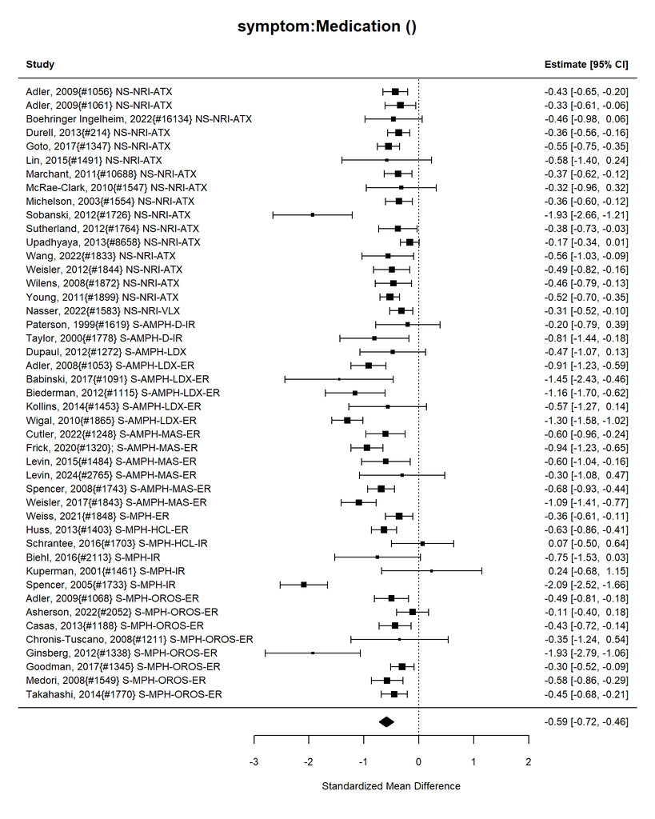

| estimate | conf.low | conf.high |
| --- | --- | --- |
| -0.59 | -0.72 | -0.46 |

Number of studies = 45

Intervention sample = 4048

Control sample = 3682

Total sample = 7730.

I-squared = 83 %

Convert Effect Size to Real Units

Estimated effect in original units = -6.45.

##### Publication Bias Tests

###### Begg (non-parametric)

Rank Correlation Test for Funnel Plot Asymmetry Kendall’s tau = -0.2081, p = 0.0445

###### Egger (parametric)

Regression Test for Funnel Plot Asymmetry

Model: mixed-effects meta-regression model Predictor: standard error

Test for Funnel Plot Asymmetry: t = -1.5976, df = 43, p = 0.1175 Limit Estimate (as sei -> 0): b = -0.3959 (CI: -0.6714, -0.1204)

###### Trim and Fill

Estimate and Cis

|  | estimate | ci.lb | ci.ub |
| --- | --- | --- | --- |
| intrcpt | -0.59 | -0.72 | -0.46 |

### Meta-regression: stimulant vs non-stimulant

29 stimulant studies

16 nonstimulant studies

| term | type | estimate | std.error | statistic | p.value |
| --- | --- | --- | --- | --- | --- |
| intercept | summary | -0.459 | 0.102 | -4.494 | 0.000 |
| stimulant_studyTRUE | summary | -0.211 | 0.130 | -1.621 | 0.112 |

### Meta-regression: AMPH vs MPH

### AMPH vs MPH meta-regression

14n AMPH studies

15 nMPH studies

| term | type | estimate | std.error | statistic | p.value |
| --- | --- | --- | --- | --- | --- |
| intercept | summary | -0.557 | 0.123 | -4.528 | 0.000 |
| AMPHTRUE | summary | -0.246 | 0.180 | -1.370 | 0.182 |

## Meta-regression: Indirect comparison between combined vs(medication plus psychosocial) and medication

45 medication studies

0 combined studies

Not enough studies to compare medication and combined

## Meta-regression: Indirect comparison between combined vs(medication plus psychosocial) and psychosocial

0 psychosocial studies

0 combined studies

Not enough studies to compare psychosocial and combined

### Outcome: symptom:categorical Intervention: Medication

Outcome name: symptom Analyzing 17 studies.

Analyzing 17 studies.

### Control Types

| control | n |
| --- | --- |
| Other | 1 |
| Placebo | 15 |
| Waitlist | 1 |

| ID | measure | yi | se | study.design |
| --- | --- | --- | --- | --- |
| Sobanski, 2012{#1726} NS-NRI-ATX | Treatment response (30% or more reduction) | -3.25 | 1.41 | RCT |
| Upadhyaya, 2013{#8658} NS-NRI-ATX | CAARS-Inv:SV ≥30% reduction from baseline and CGI-ADHD-S ≤3 (minimally ill) | -0.25 | 0.08 | RCT |
| Young, 2011{#1899} NS-NRI-ATX | CAARS, response rate (≥25% reduction in CAARS Total ADHD Symptoms Score) | 0.49 | 0.09 | RCT |
| Nasser, 2022{#1583} NS-NRI-VLX | Responder rate, 30% reduction | -0.23 | 0.11 | RCT |
| Adler, 2008{#1053} S-AMPH-LDX-ER | ADHD RS-IV (ADHD Rating Scale, Version IV), number of participants symptomatic remission | -1.16 | 0.30 | RCT |
| Levin, 2015{#1484} S-AMPH-MAS-ER | Number with at least 30% reduction | -0.39 | 0.23 | RCT |
| Levin, 2024{#2765} S-AMPH-MAS-ER | AISRS, participants with at least 30% reduction | -0.15 | 0.21 | RCT |
| Spencer, 2007{#1737} S-MPH-DEX-ER | ADHD-RS, number of patients improved at least 30% | -0.59 | 0.22 | RCT |
| Levin, 2006{#1483} S-MPH-ER | AARS (ADHD Rating Scale), number of participants who decreased score by at least 30% | 0.28 | 0.31 | RCT |
| Retz, 2012{#1657} S-MPH-ER | WRAADDS (Wender – Reimherr Adult Attention Deficit Disorder Scale), number with at least 30% reduction in total score | -1.02 | 0.27 | RCT |
| Roesler, 2009{#1669} S-MPH-ER | WRAADDS (Wender-Reimherr Adult Attention Deficit Disorder Scale), number improved at least 30% | -0.36 | 0.12 | RCT |
| Biehl, 2016{#2113} S-MPH-IR | CAARS, number responded (reduced scores at least 20%) | -0.41 | 0.37 | RCT |
| Asherson, 2022{#2052} S-MPH-OROS-ER | CAARS-O (Conners’ Adult ADHD Rating Scale-Observer), at least 20% response | -0.01 | 0.15 | RCT |
| Biederman, 2010{#1123} S-MPH-OROS-ER | AISRS (Adult ADHD Investigator Symptom Rating Scale) relapse (defined by <15% improvement) | -1.69 | 1.50 | RCT |
| Ginsberg, 2012{#1338} S-MPH-OROS-ER | CAARS-O:SV (Conners’ Adult ADHD Rating Scale – Observer: Screening Version) treatment response (30% or more decrease in total scores) | -3.30 | 1.40 | RCT |
| Konstenius, 2014{#1456} S-MPH-OROS-ER | CAARS:SV (Conners’ adult ADHD self-rating scale) symptoms decreasing by at least 30% | -0.89 | 0.35 | RCT |
| Winhusen, 2010{#1887} S-MPH-OROS-ER | ADHD-RS, number who improved by 30% | -0.48 | 0.12 | RCT |

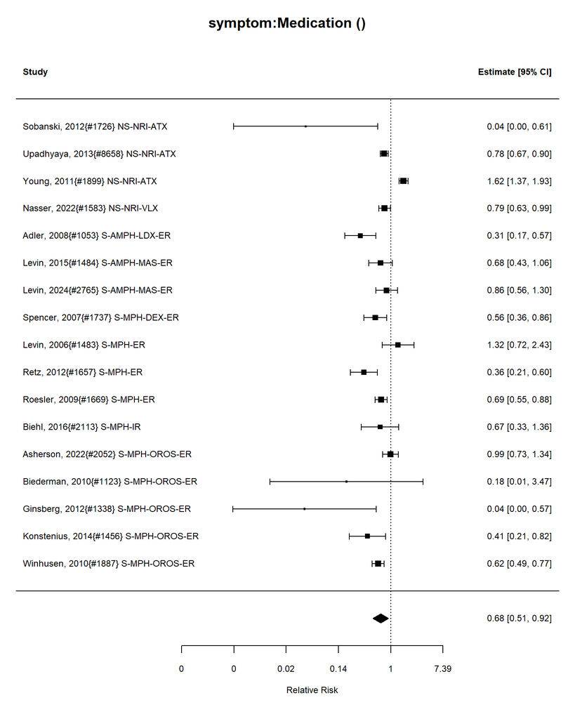

Number of studies = 17  
Intervention sample = 1559  
Control sample = 1346  
Total sample = 2905

### Relative Risk Estimate

|  | estimate | se | tval | df | pval | ci.lb | ci.ub |
| --- | --- | --- | --- | --- | --- | --- | --- |
| intrcpt | 0.6838614 | 1.150274 | 0.0639279 | 8886111 | 1.01005 | 0.506617 | 0.9139312 |

I-squared = 86 %

##### Publication Bias Tests

###### Begg (non-parametric)

```
Rank Correlation Test for Funnel Plot Asymmetry

Kendall's tau = -0.2206, p = 0.2362
```

###### Egger (parametric)

```
Regression Test for Funnel Plot Asymmetry

Model:     mixed-effects meta-regression model
Predictor: standard error

Test for Funnel Plot Asymmetry: t = -3.5644, df = 15, p = 0.0028
Limit Estimate (as sei -> 0):   b =  0.0569 (CI: -0.2686, 0.3824)
```

###### Trim and Fill

Estimate and CIs

|  | estimate | ci.lb | ci.ub |
| --- | --- | --- | --- |
| intrcpt | 0.72 | 0.56 | 0.91 |

TrimFill Relative Risk Estimate: 1

###### int_stimulant vs int_nonstimulant meta-regression

### Meta-regression: stimulant vs non-stimulant

13 stimulant studies

4 nonstimulant studies

| term | type | estimate | std.error | statistic | p.value |
| --- | --- | --- | --- | --- | --- |
| intercept | summary | -0.066 | 0.250 | -0.265 | 0.795 |
| stimulant_studyTRUE | summary | -0.413 | 0.293 | -1.408 | 0.179 |

### Meta-regression: AMPH vs MPH

### AMPH vs MPH meta-regression

4n AMPH studies

9 nMPH studies

| term | type | estimate | std.error | statistic | p.value |
| --- | --- | --- | --- | --- | --- |
| intercept | summary | -0.441 | 0.175 | -2.519 | 0.029 |
| AMPHTRUE | summary | -0.099 | 0.293 | -0.336 | 0.743 |

## Meta-regression: Indirect comparison between combined vs(medication plus psychosocial) and medication

17 medication studies

0 combined studies

Not enough studies to compare medication and combined

## Meta-regression: Indirect comparison between combined vs(medication plus psychosocial) and psychosocial

0 psychosocial studies

0 combined studies

Not enough studies to compare psychosocial and combined

### Outcome: substance_use:continuous Intervention: Medication

| ID | measure | mean_ctrl_cont | SD_ctrl_cont | n_ctrl_cont | mean_int_cont | SD_int_cont | n_int_cont | yi | se | study.design |
| --- | --- | --- | --- | --- | --- | --- | --- | --- | --- | --- |
| Durell, 2013{#214} NS-NRI-ATX | TLFB (Habits Timeline Follow Back) Number of drinks per day | 1.60 | 3.200 | 121 | 1.30 | 2.300 | 119 | 0.1071759 | 0.1291966 | RCT |
| McRae-Clark, 2010{#1547} NS-NRI-ATX | Weekly Self-Reported Marijuana Use | 1.84 | 0.340 | 9 | 2.17 | 0.340 | 7 | -0.9174851 | 0.5294090 | RCT |
| Wilens, 2008{#1872} NS-NRI-ATX | Mean drinks per day, change from baseline | 1.50 | 2.600 | 75 | 1.32 | 3.200 | 72 | -0.0615500 | 0.1650306 | RCT |
| Dupaul, 2012{#1272} S-AMPH-LDX | Substance use frequency - total | 24.64 | 2.498 | 21 | 23.73 | 2.434 | 21 | 0.3620182 | 0.3111243 | RCT |

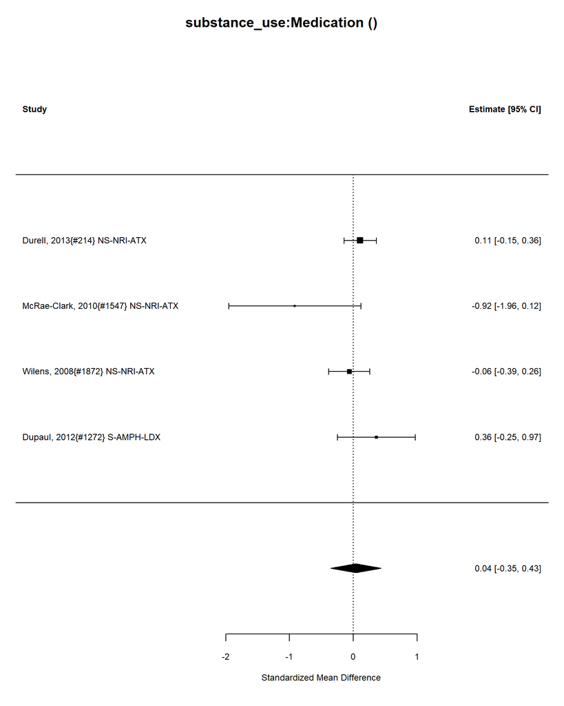

| estimate | conf.low | conf.high |
| --- | --- | --- |
| 0.04 | -0.35 | 0.43 |

Number of studies = 4

Intervention sample = 219

Control sample = 226

Total sample = 445.

I-squared = 0 %

Convert Effect Size to Real Units

Estimated effect in original units = 0.09.

##### Publication Bias Tests

###### Begg (non-parametric)

Rank Correlation Test for Funnel Plot Asymmetry Kendall’s tau = -0.3333, p = 0.7500

###### Egger (parametric)

Regression Test for Funnel Plot Asymmetry

Model: mixed-effects meta-regression model Predictor: standard error

Test for Funnel Plot Asymmetry: t = -0.7370, df = 2, p = 0.5379 Limit Estimate (as sei -> 0): b = 0.2435 (CI: -1.0658, 1.5527)

###### Trim and Fill

Estimate and Cis

|  | estimate | ci.lb | ci.ub |
| --- | --- | --- | --- |
| intrcpt | 0.07 | -0.11 | 0.26 |

### Meta-regression: stimulant vs non-stimulant

1 stimulant studies

3 nonstimulant studies

Not enough studies to compare stimulant and nonstimulant

### Meta-regression: AMPH vs MPH

### AMPH vs MPH meta-regression

1n AMPH studies

0 nMPH studies

Not enough studies to compare AMPH and MPH

## Meta-regression: Indirect comparison between combined vs(medication plus psychosocial) and medication

4 medication studies

0 combined studies

Not enough studies to compare medication and combined

## Meta-regression: Indirect comparison between combined vs(medication plus psychosocial) and psychosocial

0 psychosocial studies

0 combined studies

Not enough studies to compare psychosocial and combined

### Outcome: substance_use:categorical Intervention: Medication

Outcome name: substance_use Analyzing 7 studies.

Analyzing 7 studies.

### Control Types

| control | n |
| --- | --- |
| Other | 1 |
| Placebo | 6 |

| ID | measure | yi | se | study.design |
| --- | --- | --- | --- | --- |
| Kollins, 2014{#1453} S-AMPH-LDX-ER | Number with 4-week abstinence from smoking, CO levels of 4 ppm or below | -0.39 | 0.64 | RCT |
| Levin, 2015{#1484} S-AMPH-MAS-ER | Cocaine use, via urine screen, ITT population | -0.37 | 0.13 | RCT |
| Levin, 2024{#2765} S-AMPH-MAS-ER | Number with cannabis abstinence of 2 weeks | -1.74 | 1.51 | RCT |
| Levin, 2006{#1483} S-MPH-ER | Number of participants with 2 weeks abstinence from any illicit drug | 0.48 | 0.69 | RCT |
| Asherson, 2022{#2052} S-MPH-OROS-ER | NIDA (National Institute on Drug Abuse Quick Screen) high risk | -0.02 | 0.48 | RCT |
| Konstenius, 2014{#1456} S-MPH-OROS-ER | Number of patients testing negative for amphetamines | -0.41 | 0.59 | RCT |
| Winhusen, 2010{#1887} S-MPH-OROS-ER | Prolonged smoking abstinence rate | -0.03 | 0.14 | RCT |

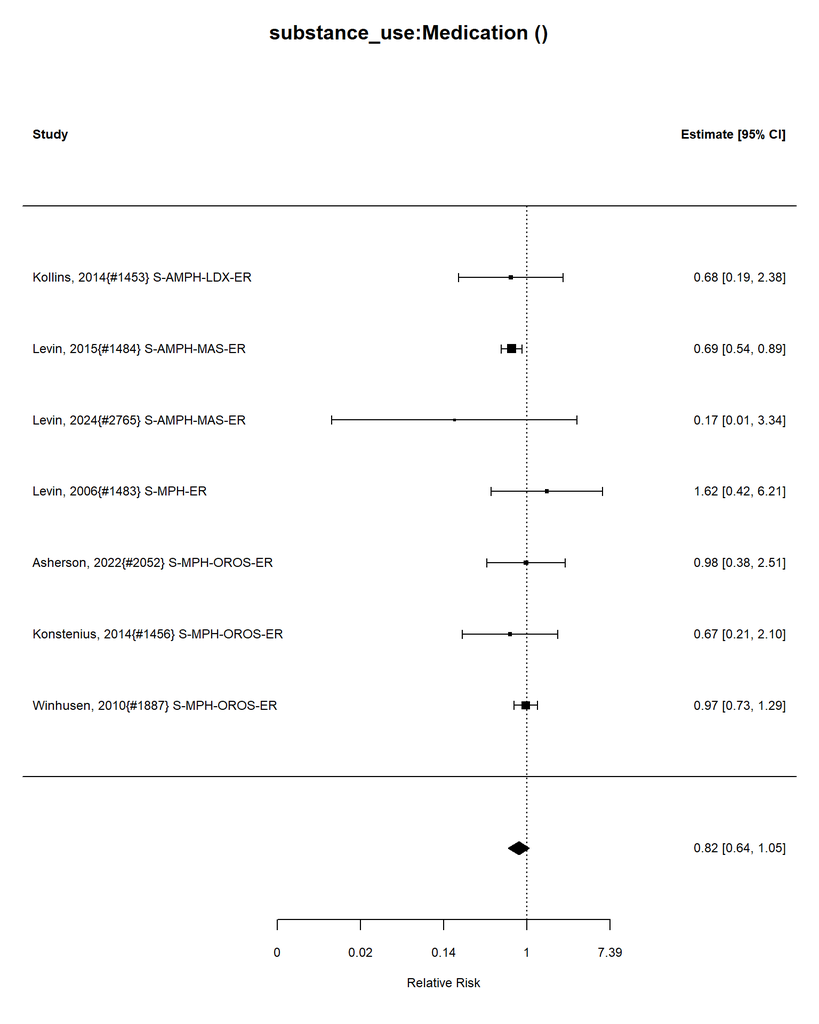

Number of studies = 7  
Intervention sample = 360  
Control sample = 360  
Total sample = 720

### Relative Risk Estimate

|  | estimate | se | tval | df | pval | ci.lb | ci.ub |
| --- | --- | --- | --- | --- | --- | --- | --- |
| intrcpt | 0.8187308 | 1.105171 | 0.1380692 | 403.4288 | 1.094174 | 0.6376282 | 1.051271 |

I-squared = 20 %

##### Publication Bias Tests

###### Begg (non-parametric)

```
Rank Correlation Test for Funnel Plot Asymmetry

Kendall's tau = -0.0476, p = 1.0000
```

###### Egger (parametric)

```
Regression Test for Funnel Plot Asymmetry

Model:     mixed-effects meta-regression model
Predictor: standard error

Test for Funnel Plot Asymmetry: t = -0.2638, df = 5, p = 0.8025
Limit Estimate (as sei -> 0):   b = -0.1642 (CI: -0.5977, 0.2694)
```

###### Trim and Fill

Estimate and CIs

|  | estimate | ci.lb | ci.ub |
| --- | --- | --- | --- |
| intrcpt | 0.84 | 0.66 | 1.06 |

TrimFill Relative Risk Estimate: 1

###### int_stimulant vs int_nonstimulant meta-regression

### Meta-regression: stimulant vs non-stimulant

7 stimulant studies

0 nonstimulant studies

Not enough studies to compare stimulant and nonstimulant

### Meta-regression: AMPH vs MPH

### AMPH vs MPH meta-regression

3n AMPH studies

4 nMPH studies

| term | type | estimate | std.error | statistic | p.value |
| --- | --- | --- | --- | --- | --- |
| intercept | summary | -0.026 | 0.079 | -0.332 | 0.753 |
| AMPHTRUE | summary | -0.351 | 0.109 | -3.232 | 0.023 |

## Meta-regression: Indirect comparison between combined vs(medication plus psychosocial) and medication

7 medication studies

0 combined studies

Not enough studies to compare medication and combined

## Meta-regression: Indirect comparison between combined vs(medication plus psychosocial) and psychosocial

0 psychosocial studies

0 combined studies

Not enough studies to compare psychosocial and combined

### Outcome: relationship:continuous Intervention: Medication

| ID | measure | mean_ctrl_cont | SD_ctrl_cont | n_ctrl_cont | mean_int_cont | SD_int_cont | n_int_cont | yi | se | study.design |
| --- | --- | --- | --- | --- | --- | --- | --- | --- | --- | --- |
| Durell, 2013{#214} NS-NRI-ATX | AAQOL-29 (Adult ADHD Quality of Life 29) Quality of Relationships Domain | 61.6 | 20.0 | 198 | 65.9 | 20.30 | 189 | -0.2130146 | 0.1019811 | RCT |
| Goto, 2017{#1347} NS-NRI-ATX | AAQoL (Adult ADHD Quality of Life) Relationship Scale, change from baseline | 10.3 | 19.9 | 190 | 15.3 | 22.30 | 179 | -0.2365028 | 0.1045253 | RCT |
| Upadhyaya, 2013{#8658} NS-NRI-ATX | AAQoL (Adult Attention-Deficit/Hyperactivity Disorder Quality of Life), Relationship scale | 72.3 | 19.7 | 258 | 74.3 | 19.10 | 266 | -0.1029567 | 0.0874384 | RCT |
| Goodman, 2017{#1345} S-MPH-OROS-ER | AIM-A (Adult ADHD Impact Module), relationship/communication domain | 61.2 | 23.6 | 172 | 63.1 | 25.04 | 169 | -0.0779383 | 0.1083514 | RCT |

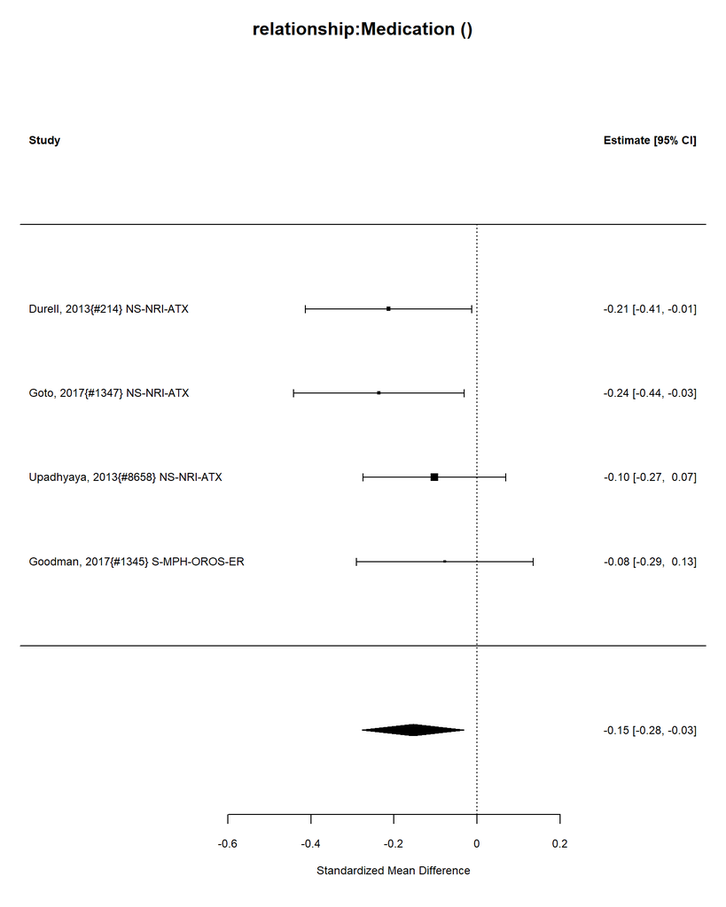

| estimate | conf.low | conf.high |
| --- | --- | --- |
| -0.15 | -0.28 | -0.03 |

Number of studies = 4

Intervention sample = 803

Control sample = 818

Total sample = 1621.

I-squared = 0 %

Convert Effect Size to Real Units

Estimated effect in original units = -3.21.

##### Publication Bias Tests

###### Begg (non-parametric)

Rank Correlation Test for Funnel Plot Asymmetry Kendall’s tau = 0.0000, p = 1.0000

###### Egger (parametric)

Regression Test for Funnel Plot Asymmetry

Model: mixed-effects meta-regression model Predictor: standard error

Test for Funnel Plot Asymmetry: t = -0.4987, df = 2, p = 0.6675 Limit Estimate (as sei -> 0): b = 0.1070 (CI: -2.1549, 2.3689)

###### Trim and Fill

Estimate and Cis

|  | estimate | ci.lb | ci.ub |
| --- | --- | --- | --- |
| intrcpt | -0.13 | -0.22 | -0.04 |

### Meta-regression: stimulant vs non-stimulant

1 stimulant studies

3 nonstimulant studies

Not enough studies to compare stimulant and nonstimulant

### Meta-regression: AMPH vs MPH

### AMPH vs MPH meta-regression

0n AMPH studies

1 nMPH studies

Not enough studies to compare AMPH and MPH

## Meta-regression: Indirect comparison between combined vs(medication plus psychosocial) and medication

4 medication studies

0 combined studies

Not enough studies to compare medication and combined

## Meta-regression: Indirect comparison between combined vs(medication plus psychosocial) and psychosocial

0 psychosocial studies

0 combined studies

Not enough studies to compare psychosocial and combined

### Outcome: relationship:categorical Intervention: Medication

Outcome name: relationship Analyzing 0 studies.

No data.

### Outcome: BP:continuous Intervention: Medication

| ID | measure | mean_ctrl_cont | SD_ctrl_cont | n_ctrl_cont | mean_int_cont | SD_int_cont | n_int_cont | yi | se | study.design |
| --- | --- | --- | --- | --- | --- | --- | --- | --- | --- | --- |
| Goto, 2017{#1347} NS-NRI-ATX | Systolic BP (mmHg), change from baseline | -0.30 | 9.800 | 195 | 2.80 | 9.800 | 193 | 0.3157114 | 0.1021665 | RCT |
| Lin, 2015{#1491} NS-NRI-ATX | Systolic blood pressure | 120.25 | 21.850 | 12 | 117.17 | 14.840 | 12 | -0.1592127 | 0.4088946 | RCT |
| Marchant, 2011{#10688} NS-NRI-ATX | Systolic blood pressure (mm Hg), change from baseline | 0.90 | 11.100 | 124 | 3.50 | 10.600 | 124 | 0.2388365 | 0.1274521 | RCT |
| Michelson, 2003{#1554} NS-NRI-ATX | Systolic blood pressure (mm Hg), change from baseline | -0.80 | 9.800 | 134 | 2.30 | 11.100 | 133 | 0.2953087 | 0.1230642 | RCT |
| Upadhyaya, 2013{#8658} NS-NRI-ATX | SBP (Systolic Blood Pressure), sitting, change from baseline | -0.90 | 12.100 | 258 | -0.70 | 11.400 | 266 | -0.0169970 | 0.0873822 | RCT |
| Paterson, 1999{#1619} S-AMPH-D-IR | Systolic blood pressure | 119.00 | 15.130 | 21 | 119.00 | 18.700 | 23 | 0.0000000 | 0.3018233 | RCT |
| Dupaul, 2012{#1272} S-AMPH-LDX | Systolic blood pressure mmHg | 122.23 | 18.176 | 21 | 125.41 | 15.795 | 21 | 0.1832328 | 0.3092536 | RCT |
| Biederman, 2012{#1115} S-AMPH-LDX-ER | Systolic blood pressure | 115.30 | 12.500 | 30 | 124.60 | 12.800 | 31 | 0.7255891 | 0.2643989 | RCT |
| Cutler, 2022{#1248} S-AMPH-MAS-ER | Systolic Blood Pressure (mmHg) | 114.50 | 11.200 | 65 | 120.70 | 10.940 | 62 | 0.5565088 | 0.1809225 | RCT |
| Weisler, 2006{#1842} S-AMPH-MAS-ER | Systolic blood pressure (mmHg) mean change | -1.90 | 10.100 | 64 | 0.90 | 10.200 | 61 | 0.2742056 | 0.1797754 | RCT |
| Weisler, 2017{#1843} S-AMPH-MAS-ER | Systolic blood pressure, mmHg, change from baseline | -0.80 | 9.990 | 89 | 1.70 | 9.990 | 90 | 0.2491881 | 0.1500684 | RCT |
| Roesler, 2009{#1669} S-MPH-ER | Systolic Blood Pressure | 123.00 | 15.000 | 118 | 124.00 | 13.000 | 241 | 0.0729047 | 0.1123893 | RCT |
| Spencer, 2005{#1733} S-MPH-IR | Systolic blood pressure | 126.00 | 14.000 | 42 | 128.00 | 12.000 | 104 | 0.1578791 | 0.1830581 | RCT |
| Asherson, 2022{#2052} S-MPH-OROS-ER | Blood pressure (systolic, mmHg) | 125.50 | 14.000 | 93 | 125.00 | 12.500 | 89 | -0.0374714 | 0.1482987 | RCT |
| Ginsberg, 2012{#1338} S-MPH-OROS-ER | Systolic Blood Pressure, increase from baseline to 5 weeks (double blind phase) | 7.00 | 22.550 | 15 | 13.10 | 20.650 | 15 | 0.2744979 | 0.3668639 | RCT |
| Medori, 2008{#1549} S-MPH-OROS-ER | Systolic Blood Pressure | 124.50 | 20.000 | 96 | 124.60 | 24.800 | 102 | 0.0044076 | 0.1421993 | RCT |
| Spencer, 2011{#1744} S-MPH-OROS-ER | Systolic blood pressure | 122.20 | 15.200 | 12 | 124.60 | 13.000 | 41 | 0.1750854 | 0.3286530 | RCT |
| Winhusen, 2010{#1887} S-MPH-OROS-ER | Change in Systolic Blood Pressure as a function of Treatment Group and Time - Week 15 | 0.40 | 8.900 | 101 | 1.60 | 10.300 | 104 | 0.1240748 | 0.1398353 | RCT |

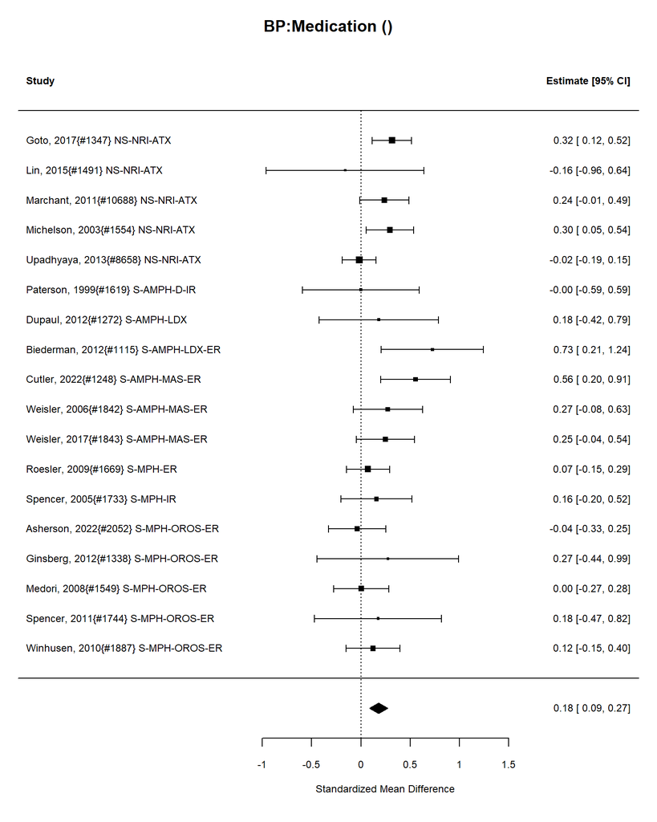

| estimate | conf.low | conf.high |
| --- | --- | --- |
| 0.18 | 0.09 | 0.27 |

Number of studies = 18

Intervention sample = 1712

Control sample = 1490

Total sample = 3202.

I-squared = 29 %

Convert Effect Size to Real Units

Estimated effect in original units = 2.5.

##### Publication Bias Tests

###### Begg (non-parametric)

Rank Correlation Test for Funnel Plot Asymmetry Kendall’s tau = 0.0327, p = 0.8814

###### Egger (parametric)

Regression Test for Funnel Plot Asymmetry

Model: mixed-effects meta-regression model Predictor: standard error

Test for Funnel Plot Asymmetry: t = 0.6790, df = 16, p = 0.5069 Limit Estimate (as sei -> 0): b = 0.1101 (CI: -0.1227, 0.3428)

###### Trim and Fill

Estimate and Cis

|  | estimate | ci.lb | ci.ub |
| --- | --- | --- | --- |
| intrcpt | 0.18 | 0.09 | 0.27 |

### Meta-regression: stimulant vs non-stimulant

13 stimulant studies

5 nonstimulant studies

| term | type | estimate | std.error | statistic | p.value |
| --- | --- | --- | --- | --- | --- |
| intercept | summary | 0.183 | 0.072 | 2.523 | 0.023 |
| stimulant_studyTRUE | summary | -0.004 | 0.092 | -0.041 | 0.968 |

### Meta-regression: AMPH vs MPH

### AMPH vs MPH meta-regression

6n AMPH studies

7 nMPH studies

| term | type | estimate | std.error | statistic | p.value |
| --- | --- | --- | --- | --- | --- |
| intercept | summary | 0.070 | 0.049 | 1.433 | 0.180 |
| AMPHTRUE | summary | 0.275 | 0.083 | 3.299 | 0.007 |

## Meta-regression: Indirect comparison between combined vs(medication plus psychosocial) and medication

18 medication studies

0 combined studies

Not enough studies to compare medication and combined

## Meta-regression: Indirect comparison between combined vs(medication plus psychosocial) and psychosocial

0 psychosocial studies

0 combined studies

Not enough studies to compare psychosocial and combined

### Outcome: BP:categorical Intervention: Medication

Outcome name: BP Analyzing 3 studies.

Analyzing 3 studies.

### Control Types

| control | n |
| --- | --- |
| N/A | 1 |
| Placebo | 2 |

| ID | measure | yi | se | study.design |
| --- | --- | --- | --- | --- |
| Biederman, 2010{#1123} S-MPH-OROS-ER | Systolic blood pressure, 140 mm Hg or higher | -0.56 | 0.50 | RCT |
| Konstenius, 2014{#1456} S-MPH-OROS-ER | Increase in blood pressure | 0.69 | 0.82 | RCT |
| Spencer, 2011{#1744} S-MPH-OROS-ER | Number with systolic blood pressure > 140 mm Hg | 0.13 | 0.75 | RCT |

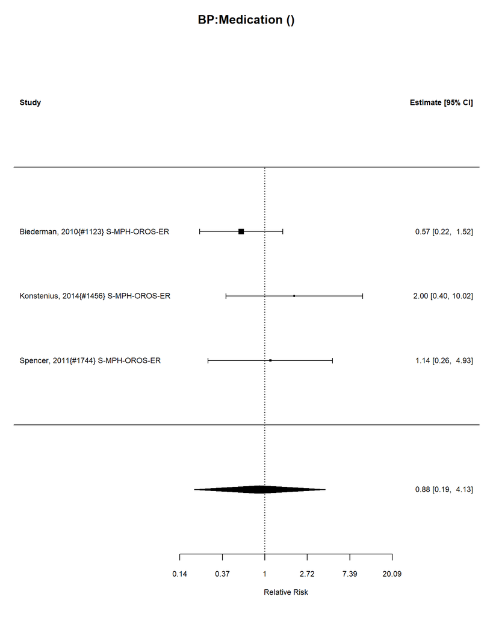

Number of studies = 3  
Intervention sample = 177  
Control sample = 153  
Total sample = 330

### Relative Risk Estimate

|  | estimate | se | tval | df | pval | ci.lb | ci.ub |
| --- | --- | --- | --- | --- | --- | --- | --- |
| intrcpt | 0.8869204 | 1.433329 | 0.7117703 | 7.389056 | 2.159766 | 0.190139 | 4.13712 |

I-squared = 4 %

##### Publication Bias Tests

###### Begg (non-parametric)

```
Rank Correlation Test for Funnel Plot Asymmetry

Kendall's tau = 1.0000, p = 0.3333
```

###### Egger (parametric)

```
Regression Test for Funnel Plot Asymmetry

Model:     mixed-effects meta-regression model
Predictor: standard error

Test for Funnel Plot Asymmetry: t =  4.7700, df = 1, p = 0.1316
Limit Estimate (as sei -> 0):   b = -2.2955 (CI: -8.2015, 3.6105)
```

###### Trim and Fill

Estimate and CIs

|  | estimate | ci.lb | ci.ub |
| --- | --- | --- | --- |
| intrcpt | 0.57 | 0.27 | 1.21 |

TrimFill Relative Risk Estimate: 1

###### int_stimulant vs int_nonstimulant meta-regression

### Meta-regression: stimulant vs non-stimulant

3 stimulant studies

0 nonstimulant studies

Not enough studies to compare stimulant and nonstimulant

### Meta-regression: AMPH vs MPH

### AMPH vs MPH meta-regression

0n AMPH studies

3 nMPH studies

Not enough studies to compare AMPH and MPH

## Meta-regression: Indirect comparison between combined vs(medication plus psychosocial) and medication

3 medication studies

0 combined studies

Not enough studies to compare medication and combined

## Meta-regression: Indirect comparison between combined vs(medication plus psychosocial) and psychosocial

0 psychosocial studies

0 combined studies

Not enough studies to compare psychosocial and combined

### Outcome: sleep_disturbance:continuous Intervention: Medication

| ID | measure | mean_ctrl_cont | SD_ctrl_cont | n_ctrl_cont | mean_int_cont | SD_int_cont | n_int_cont | yi | se | study.design |
| --- | --- | --- | --- | --- | --- | --- | --- | --- | --- | --- |
| Adler, 2008{#1053} S-AMPH-LDX-ER | PSQI (Pittsburgh Sleep Quality Index), sleep onset, minutes | 28.1 | 32.64 | 62 | 29.3 | 31.19 | 121 | 0.0377143 | 0.1561966 | RCT |
| Weiss, 2021{#1848} S-MPH-ER | PSQI (Pittsburgh Sleep Quality Index) | 7.3 | 4.10 | 78 | 8.1 | 3.60 | 297 | 0.2152725 | 0.1274728 | RCT |
| Goodman, 2017{#1345} S-MPH-OROS-ER | PSQI (Pittsburgh Sleep Quality Index) | 8.5 | 3.25 | 172 | 8.4 | 3.14 | 169 | -0.0312202 | 0.1083169 | RCT |

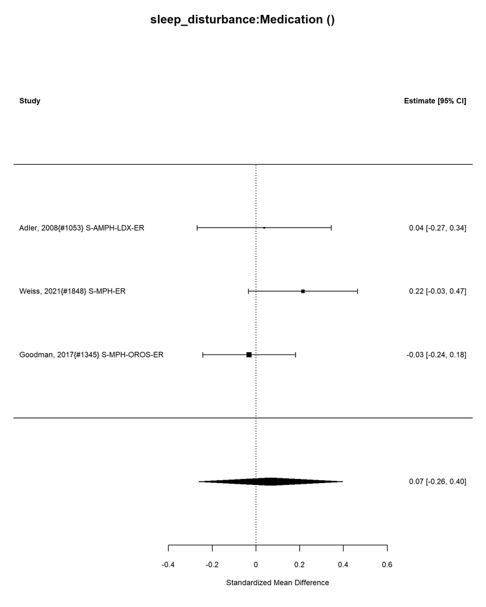

| estimate | conf.low | conf.high |
| --- | --- | --- |
| 0.07 | -0.26 | 0.4 |

Number of studies = 3

Intervention sample = 587

Control sample = 312

Total sample = 899.

I-squared = 18 %

Convert Effect Size to Real Units

Estimated effect in original units = 0.89.

##### Publication Bias Tests

###### Begg (non-parametric)

Rank Correlation Test for Funnel Plot Asymmetry Kendall’s tau = 0.3333, p = 1.0000

###### Egger (parametric)

Regression Test for Funnel Plot Asymmetry

Model: mixed-effects meta-regression model Predictor: standard error

Test for Funnel Plot Asymmetry: t = 0.2595, df = 1, p = 0.8384 Limit Estimate (as sei -> 0): b = -0.1087 (CI: -8.9823, 8.7648)

###### Trim and Fill

Estimate and Cis

|  | estimate | ci.lb | ci.ub |
| --- | --- | --- | --- |
| intrcpt | 0.07 | -0.26 | 0.4 |

### Meta-regression: stimulant vs non-stimulant

3 stimulant studies

0 nonstimulant studies

Not enough studies to compare stimulant and nonstimulant

### Meta-regression: AMPH vs MPH

### AMPH vs MPH meta-regression

1n AMPH studies

2 nMPH studies

Not enough studies to compare AMPH and MPH

## Meta-regression: Indirect comparison between combined vs(medication plus psychosocial) and medication

3 medication studies

0 combined studies

Not enough studies to compare medication and combined

## Meta-regression: Indirect comparison between combined vs(medication plus psychosocial) and psychosocial

0 psychosocial studies

0 combined studies

Not enough studies to compare psychosocial and combined

### Outcome: sleep_disturbance:categorical Intervention: Medication

Outcome name: sleep_disturbance Analyzing 12 studies.

Analyzing 12 studies.

### Control Types

| control | n |
| --- | --- |
| Placebo | 12 |

| ID | measure | yi | se | study.design |
| --- | --- | --- | --- | --- |
| Boehringer Ingelheim, 2022{#16134} NS-NRI-ATX | Insomnia | 0.00 | 0.97 | RCT |
| Michelson, 2003{#1554} NS-NRI-ATX | Insomnia | 0.87 | 0.23 | RCT |
| Weisler, 2012{#1844} NS-NRI-ATX | Number of participants reporting insomnia | -1.11 | 1.14 | RCT |
| Nasser, 2022{#1583} NS-NRI-VLX | Insomnia | 1.07 | 1.15 | RCT |
| Adler, 2008{#1053} S-AMPH-LDX-ER | Insomnia | 1.48 | 0.59 | RCT |
| Kollins, 2014{#1453} S-AMPH-LDX-ER | Insomnia | -1.22 | 1.10 | RCT |
| Cutler, 2022{#1248} S-AMPH-MAS-ER | Number with insomnia | -0.56 | 0.41 | RCT |
| Weisler, 2006{#1842} S-AMPH-MAS-ER | Insomnia | 1.72 | 0.36 | RCT |
| Weisler, 2017{#1843} S-AMPH-MAS-ER | Number of participants reporting insomnia | 2.29 | 1.04 | RCT |
| Roesler, 2009{#1669} S-MPH-ER | Difficulty falling asleep | -0.39 | 0.29 | RCT |
| Spencer, 2005{#1733} S-MPH-IR | Number of patients with difficulty sleeping | 0.37 | 0.39 | RCT |
| Konstenius, 2014{#1456} S-MPH-OROS-ER | Sleep problems | 1.10 | 0.77 | RCT |

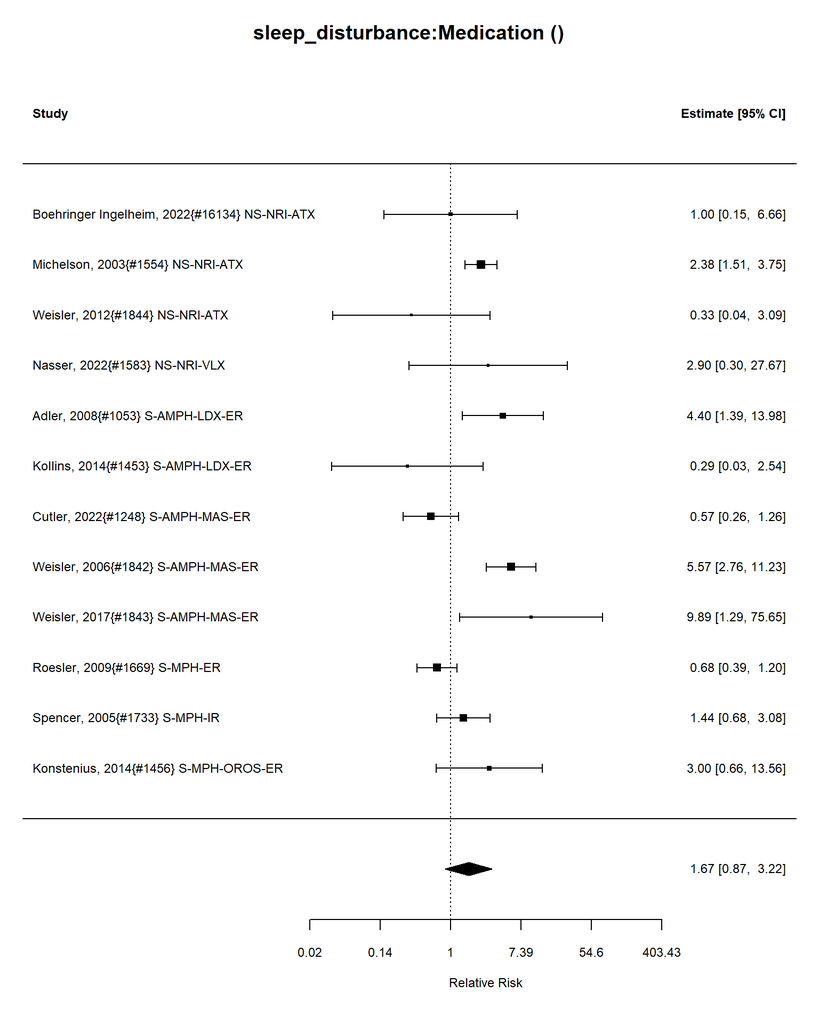

Number of studies = 12  
Intervention sample = 1249  
Control sample = 1029  
Total sample = 2278

### Relative Risk Estimate

|  | estimate | se | tval | df | pval | ci.lb | ci.ub |
| --- | --- | --- | --- | --- | --- | --- | --- |
| intrcpt | 1.665291 | 1.349859 | 5.584529 | 59874.14 | 1.116278 | 0.8693582 | 3.221993 |

I-squared = 74 %

##### Publication Bias Tests

###### Begg (non-parametric)

```
Rank Correlation Test for Funnel Plot Asymmetry

Kendall's tau = -0.1212, p = 0.6384
```

###### Egger (parametric)

```
Regression Test for Funnel Plot Asymmetry

Model:     mixed-effects meta-regression model
Predictor: standard error

Test for Funnel Plot Asymmetry: t = -0.2286, df = 10, p = 0.8238
Limit Estimate (as sei -> 0):   b =  0.6387 (CI: -0.7922, 2.0697)
```

###### Trim and Fill

Estimate and CIs

|  | estimate | ci.lb | ci.ub |
| --- | --- | --- | --- |
| intrcpt | 1.67 | 0.87 | 3.22 |

TrimFill Relative Risk Estimate: 2

###### int_stimulant vs int_nonstimulant meta-regression

### Meta-regression: stimulant vs non-stimulant

9 stimulant studies

3 nonstimulant studies

| term | type | estimate | std.error | statistic | p.value |
| --- | --- | --- | --- | --- | --- |
| intercept | summary | 0.688 | 0.653 | 1.053 | 0.317 |
| stimulant_studyTRUE | summary | -0.231 | 0.745 | -0.310 | 0.763 |

### Meta-regression: AMPH vs MPH

### AMPH vs MPH meta-regression

5n AMPH studies

4 nMPH studies

| term | type | estimate | std.error | statistic | p.value |
| --- | --- | --- | --- | --- | --- |
| intercept | summary | 0.061 | 0.595 | 0.102 | 0.922 |
| AMPHTRUE | summary | 0.727 | 0.806 | 0.901 | 0.397 |

## Meta-regression: Indirect comparison between combined vs(medication plus psychosocial) and medication

12 medication studies

0 combined studies

Not enough studies to compare medication and combined

## Meta-regression: Indirect comparison between combined vs(medication plus psychosocial) and psychosocial

0 psychosocial studies

0 combined studies

Not enough studies to compare psychosocial and combined

### Outcome: AEs:continuous Intervention: Medication

| ID | measure | mean_ctrl_cont | SD_ctrl_cont | n_ctrl_cont | mean_int_cont | SD_int_cont | n_int_cont | yi | se | study.design |
| --- | --- | --- | --- | --- | --- | --- | --- | --- | --- | --- |
| Asherson, 2022{#2052} S-MPH-OROS-ER | Burden of adverse events | 5.5 | 5.4 | 93 | 7.4 | 7.5 | 89 | 0.2905587 | 0.1490657 | RCT |

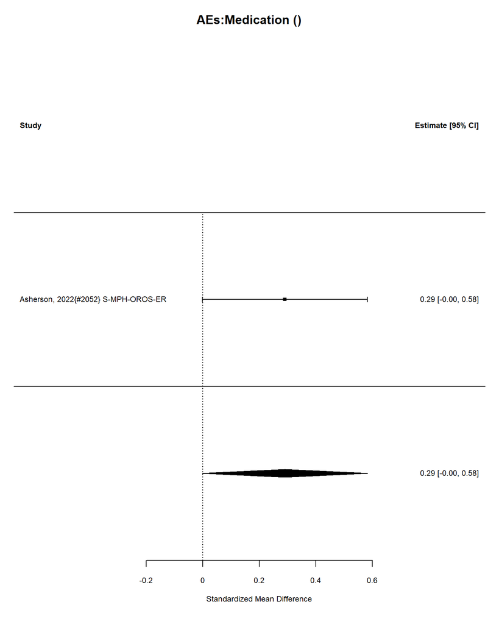

| estimate | conf.low | conf.high |
| --- | --- | --- |
| 0.29 | 0 | 0.58 |

Number of studies = 1

Intervention sample = 89

Control sample = 93

Total sample = 182.

I-squared = 0 %

Convert Effect Size to Real Units

Estimated effect in original units = 1.57.

### Outcome: AEs:categorical Intervention: Medication

Outcome name: AEs Analyzing 40 studies.

Analyzing 40 studies.

### Control Types

| control | n |
| --- | --- |
| N/A | 1 |
| Other | 1 |
| Placebo | 38 |

| ID | measure | yi | se | study.design |
| --- | --- | --- | --- | --- |
| Adler, 2008{#1063} NS-NRI-ATX | Number of participants dropped out due to adverse event | 1.87 | 0.59 | RCT |
| Adler, 2009{#1056} NS-NRI-ATX | Number of participants with any adverse event | 0.09 | 0.04 | RCT |
| Boehringer Ingelheim, 2022{#16134} NS-NRI-ATX | Treatment emergent adverse events | 0.11 | 0.11 | RCT |
| Goto, 2017{#1347} NS-NRI-ATX | Number of participants with at least one adverse event | 0.41 | 0.07 | RCT |
| Marchant, 2011{#10688} NS-NRI-ATX | Number of participants with adverse events | 1.37 | 0.63 | RCT |
| McRae-Clark, 2010{#1547} NS-NRI-ATX | Number of Patients with an adverse event | 0.17 | 0.11 | RCT |
| Michelson, 2003{#1554} NS-NRI-ATX | Number of participants with adverse events | 0.59 | 0.49 | RCT |
| Sutherland, 2012{#1764} NS-NRI-ATX | Number of withdrawals attributed to treatment-related adverse events | 0.04 | 0.42 | RCT |
| Upadhyaya, 2013{#8658} NS-NRI-ATX | Number of participants with at least one adverse event during the double-blind treatment phase | 0.02 | 0.09 | RCT |
| Wang, 2022{#1833} NS-NRI-ATX | Number of participants with adverse events | 1.61 | 1.53 | RCT |
| Weisler, 2012{#1844} NS-NRI-ATX | Number of participants reporting any adverse events | 0.35 | 0.11 | RCT |
| Young, 2011{#1899} NS-NRI-ATX | Number of participants experiencing at least one treatment-emergent adverse event | 0.13 | 0.04 | RCT |
| Nasser, 2022{#1583} NS-NRI-VLX | Participants reporting at least 1 treatment-emergent adverse event | 0.19 | 0.09 | RCT |
| Paterson, 1999{#1619} S-AMPH-D-IR | Participants with side effects | 1.01 | 0.46 | RCT |
| Adler, 2008{#1053} S-AMPH-LDX-ER | Any treatment-emergent adverse event | 0.36 | 0.12 | RCT |
| Adler, 2013{#1050} S-AMPH-LDX-ER | Number of patients experiencing any adverse event | 0.23 | 0.11 | RCT |
| Biederman, 2012{#1115} S-AMPH-LDX-ER | Number of participants with at least 1 adverse event | 0.38 | 0.16 | RCT |
| Brams, 2012{#1150} S-AMPH-LDX-ER | Any treatment emergent adverse event | 0.47 | 0.24 | RCT |
| Kollins, 2014{#1453} S-AMPH-LDX-ER | Number of participants with adverse events | 0.10 | 0.16 | RCT |
| Martin, 2014{#583} S-AMPH-LDX-ER | Number of participants with adverse events | 0.35 | 0.31 | RCT |
| Wigal, 2010{#1865} S-AMPH-LDX-ER | Number of participants with AN adverse event | -0.25 | 0.19 | RCT |
| Cutler, 2022{#1248} S-AMPH-MAS-ER | Number of patients with adverse events | 0.41 | 0.11 | RCT |
| Frick, 2020{#1320}; S-AMPH-MAS-ER | Number of participants experiencing any TEAE (Treatment-Emergent Adverse Event) | 0.34 | 0.09 | RCT |
| Levin, 2015{#1484} S-AMPH-MAS-ER | Patients with adverse events | 0.86 | 0.36 | RCT |
| Spencer, 2008{#1743} S-AMPH-MAS-ER | At least 1 treament emerget adverse event | 0.33 | 0.07 | RCT |
| Weisler, 2006{#1842} S-AMPH-MAS-ER | Number of participants with adverse events outcome | 2.13 | 1.05 | RCT |
| Weisler, 2017{#1843} S-AMPH-MAS-ER | Any treatment emergent adverse event | 0.65 | 0.16 | RCT |
| Retz, 2012{#1657} S-MPH-ER | Number of participants with adverse events | 0.47 | 0.16 | RCT |
| Roesler, 2009{#1669} S-MPH-ER | Number of participants with adverse event | 0.26 | 0.09 | RCT |
| Weiss, 2021{#1848} S-MPH-ER | Number of participants with at least one treatment-emergent adverse event (TEAE) | 0.38 | 0.13 | RCT |
| Huss, 2013{#1403} S-MPH-HCL-ER | Number with any adverse event | 0.22 | 0.07 | RCT |
| Biehl, 2016{#2113} S-MPH-IR | Number of participants with adverse events | 0.42 | 0.20 | RCT |
| Kuperman, 2001{#1461} S-MPH-IR | Number of participants with at least one adverse event | 0.12 | 0.26 | RCT |
| Adler, 2009{#1068} S-MPH-OROS-ER | Number of participants with adverse events | 0.28 | 0.08 | RCT |
| Asherson, 2022{#2052} S-MPH-OROS-ER | Any adverse event | 0.03 | 0.07 | RCT |
| Goodman, 2017{#1345} S-MPH-OROS-ER | Number of patients with any treatment-emergent adverse event | 0.38 | 0.09 | RCT |
| Medori, 2008{#1549} S-MPH-OROS-ER | Number of participants with adverse events | 0.23 | 0.09 | RCT |
| Spencer, 2011{#1744} S-MPH-OROS-ER | Number experiencing any adverse event | -0.34 | 0.31 | RCT |
| Takahashi, 2014{#1770} S-MPH-OROS-ER | Number of participants with adverse events | 0.42 | 0.09 | RCT |
| Winhusen, 2010{#1887} S-MPH-OROS-ER | Number of participants with adverse events | 0.09 | 0.04 | RCT |

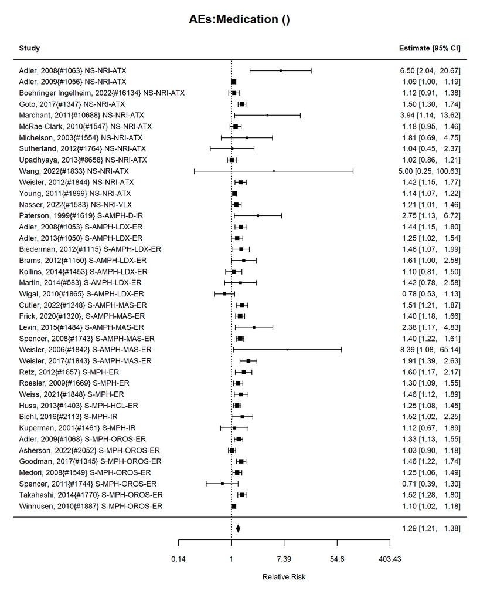

Number of studies = 40  
Intervention sample = 4508  
Control sample = 3836  
Total sample = 8344

### Relative Risk Estimate

|  | estimate | se | tval | df | pval | ci.lb | ci.ub |
| --- | --- | --- | --- | --- | --- | --- | --- |
| intrcpt | 1.29693 | 1.030455 | 2321.572 | 8.65934e+16 | 1 | 1.20925 | 1.377128 |

I-squared = 61 %

##### Publication Bias Tests

###### Begg (non-parametric)

```
Rank Correlation Test for Funnel Plot Asymmetry

Kendall's tau = 0.1923, p = 0.0825
```

###### Egger (parametric)

```
Regression Test for Funnel Plot Asymmetry

Model:     mixed-effects meta-regression model
Predictor: standard error

Test for Funnel Plot Asymmetry: t = 3.3007, df = 38, p = 0.0021
Limit Estimate (as sei -> 0):   b = 0.1254 (CI: 0.0296, 0.2212)
```

###### Trim and Fill

Estimate and CIs

|  | estimate | ci.lb | ci.ub |
| --- | --- | --- | --- |
| intrcpt | 1.26 | 1.19 | 1.34 |

TrimFill Relative Risk Estimate: 1

###### int_stimulant vs int_nonstimulant meta-regression

### Meta-regression: stimulant vs non-stimulant

28 stimulant studies

12 nonstimulant studies

| term | type | estimate | std.error | statistic | p.value |
| --- | --- | --- | --- | --- | --- |
| intercept | summary | 0.182 | 0.059 | 3.105 | 0.004 |
| stimulant_studyTRUE | summary | 0.102 | 0.070 | 1.465 | 0.151 |

### Meta-regression: AMPH vs MPH

### AMPH vs MPH meta-regression

14n AMPH studies

14 nMPH studies

| term | type | estimate | std.error | statistic | p.value |
| --- | --- | --- | --- | --- | --- |
| intercept | summary | 0.250 | 0.046 | 5.477 | 0.000 |
| AMPHTRUE | summary | 0.088 | 0.074 | 1.189 | 0.245 |

## Meta-regression: Indirect comparison between combined vs(medication plus psychosocial) and medication

40 medication studies

0 combined studies

Not enough studies to compare medication and combined

## Meta-regression: Indirect comparison between combined vs(medication plus psychosocial) and psychosocial

0 psychosocial studies

0 combined studies

Not enough studies to compare psychosocial and combined

### Outcome: mortality:continuous Intervention: Medication

No data #1.

### Outcome: mortality:categorical Intervention: Medication

Outcome name: mortality Analyzing 23 studies.

Analyzing 23 studies.

### Control Types

| control | n |
| --- | --- |
| Placebo | 23 |

| ID | measure | yi | se | study.design |
| --- | --- | --- | --- | --- |
| Boehringer Ingelheim, 2022{#16134} NS-NRI-ATX | Deaths | 0.00 | 1.98 | RCT |
| Goto, 2017{#1347} NS-NRI-ATX | Number of deaths | -0.01 | 2.00 | RCT |
| Sutherland, 2012{#1764} NS-NRI-ATX | Number of deaths | 0.71 | 1.99 | RCT |
| Upadhyaya, 2013{#8658} NS-NRI-ATX | Number of deaths | 1.13 | 1.63 | RCT |
| Wang, 2022{#1833} NS-NRI-ATX | All-cause mortality | 0.00 | 1.99 | RCT |
| Weisler, 2012{#1844} NS-NRI-ATX | Number of deaths | 0.01 | 1.99 | RCT |
| Young, 2011{#1899} NS-NRI-ATX | Number of deaths | 0.13 | 2.00 | RCT |
| Nasser, 2022{#1583} NS-NRI-VLX | All-cause mortality | 0.03 | 2.00 | RCT |
| Adler, 2008{#1053} S-AMPH-LDX-ER | Number of deaths | 0.67 | 1.99 | RCT |
| Adler, 2013{#1050} S-AMPH-LDX-ER | Number of deaths | 0.05 | 1.99 | RCT |
| Brams, 2012{#1150} S-AMPH-LDX-ER | Number of deaths | -0.18 | 1.99 | RCT |
| Wigal, 2010{#1865} S-AMPH-LDX-ER | Number of deaths | -0.02 | 2.00 | RCT |
| Cutler, 2022{#1248} S-AMPH-MAS-ER | All-cause mortality | -0.05 | 1.99 | RCT |
| Frick, 2020{#1320}; S-AMPH-MAS-ER | Number of deaths | -0.02 | 2.00 | RCT |
| Levin, 2024{#2765} S-AMPH-MAS-ER | All-cause mortality | -0.13 | 1.97 | RCT |
| Spencer, 2008{#1743} S-AMPH-MAS-ER | Number of deaths | 0.01 | 2.00 | RCT |
| Spencer, 2007{#1737} S-MPH-DEX-ER | Number of deaths | 0.16 | 1.99 | RCT |
| Huss, 2013{#1403} S-MPH-HCL-ER | Number of deaths | 0.01 | 2.00 | RCT |
| Biehl, 2016{#2113} S-MPH-IR | All-cause mortality | 0.16 | 1.97 | RCT |
| Adler, 2009{#1068} S-MPH-OROS-ER | Number of deaths | -0.05 | 2.00 | RCT |
| Biederman, 2010{#1123} S-MPH-OROS-ER | Number of deaths | -0.10 | 1.99 | RCT |
| Goodman, 2017{#1345} S-MPH-OROS-ER | Number of deaths | -0.01 | 2.00 | RCT |
| Takahashi, 2014{#1770} S-MPH-OROS-ER | Number of deaths | 0.02 | 2.00 | RCT |

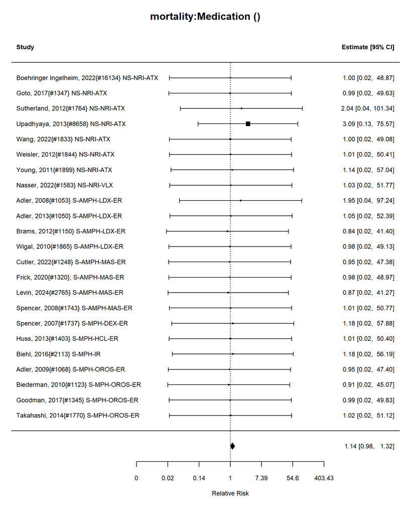

Number of studies = 23  
Intervention sample = 2572  
Control sample = 2430  
Total sample = 5002

### Relative Risk Estimate

|  | estimate | se | tval | df | pval | ci.lb | ci.ub |
| --- | --- | --- | --- | --- | --- | --- | --- |
| intrcpt | 1.138828 | 1.072508 | 6.423737 | 3584912846 | 1.083287 | 0.9801987 | 1.32313 |

I-squared = 0 %

##### Publication Bias Tests

###### Begg (non-parametric)

```
Rank Correlation Test for Funnel Plot Asymmetry

Kendall's tau = 0.0198, p = 0.9168
```

###### Egger (parametric)

```
Regression Test for Funnel Plot Asymmetry

Model:     mixed-effects meta-regression model
Predictor: standard error

Test for Funnel Plot Asymmetry: t = -5.6217, df = 21, p < .0001
Limit Estimate (as sei -> 0):   b =  5.8676 (CI: 3.7436, 7.9916)
```

###### Trim and Fill

Estimate and CIs

|  | estimate | ci.lb | ci.ub |
| --- | --- | --- | --- |
| intrcpt | 1.23 | 0.6 | 2.52 |

TrimFill Relative Risk Estimate: 1

###### int_stimulant vs int_nonstimulant meta-regression

### Meta-regression: stimulant vs non-stimulant

16 stimulant studies

7 nonstimulant studies

| term | type | estimate | std.error | statistic | p.value |
| --- | --- | --- | --- | --- | --- |
| intercept | summary | 0.340 | 0.116 | 2.934 | 0.008 |
| stimulant_studyTRUE | summary | -0.306 | 0.140 | -2.179 | 0.041 |

### Meta-regression: AMPH vs MPH

### AMPH vs MPH meta-regression

9n AMPH studies

7 nMPH studies

| term | type | estimate | std.error | statistic | p.value |
| --- | --- | --- | --- | --- | --- |
| intercept | summary | 0.007 | 0.074 | 0.095 | 0.925 |
| AMPHTRUE | summary | 0.048 | 0.099 | 0.484 | 0.636 |

## Meta-regression: Indirect comparison between combined vs(medication plus psychosocial) and medication

23 medication studies

0 combined studies

Not enough studies to compare medication and combined

## Meta-regression: Indirect comparison between combined vs(medication plus psychosocial) and psychosocial

0 psychosocial studies

0 combined studies

Not enough studies to compare psychosocial and combined

### Outcome: behavior:continuous Intervention: Medication

| ID | measure | mean_ctrl_cont | SD_ctrl_cont | n_ctrl_cont | mean_int_cont | SD_int_cont | n_int_cont | yi | se | study.design |
| --- | --- | --- | --- | --- | --- | --- | --- | --- | --- | --- |
| Asherson, 2022{#2052} S-MPH-OROS-ER | MVQ (Maudsley Violence Questionnaire) | 33.1 | 11.7 | 94 | 30.6 | 12.5 | 90 | 0.2057959 | 0.1478665 | RCT |

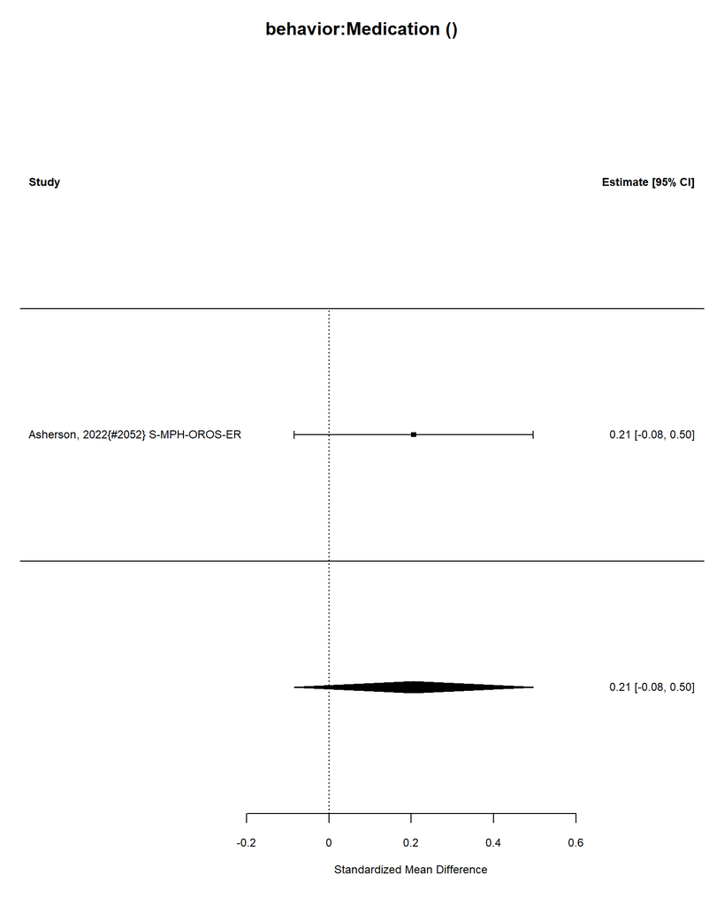

| estimate | conf.low | conf.high |
| --- | --- | --- |
| 0.21 | -0.08 | 0.5 |

Number of studies = 1

Intervention sample = 90

Control sample = 94

Total sample = 184.

I-squared = 0 %

Convert Effect Size to Real Units

Estimated effect in original units = 2.41.

### Outcome: behavior:categorical Intervention: Medication

Outcome name: behavior Analyzing 0 studies.

No data.

### Outcome: appetite:continuous Intervention: Medication

No data #1.

### Outcome: appetite:categorical Intervention: Medication

Outcome name: appetite Analyzing 38 studies.

Analyzing 38 studies.

### Control Types

| control | n |
| --- | --- |
| Other | 1 |
| Placebo | 37 |

| ID | measure | yi | se | study.design |
| --- | --- | --- | --- | --- |
| Adler, 2009{#1056} NS-NRI-ATX | Participants who experienced decreased appetite | -0.60 | 0.35 | RCT |
| Adler, 2009{#1061} NS-NRI-ATX | Decreased appetite | -1.51 | 0.41 | RCT |
| Boehringer Ingelheim, 2022{#16134} NS-NRI-ATX | Decreased apetite | -3.04 | 1.43 | RCT |
| Durell, 2013{#214} NS-NRI-ATX | Decreased appetite | -1.73 | 0.48 | RCT |
| Goto, 2017{#1347} NS-NRI-ATX | Decreased appetite adverse event | -3.12 | 0.72 | RCT |
| Upadhyaya, 2013{#8658} NS-NRI-ATX | Decreased appetite | 0.03 | 1.41 | RCT |
| Weisler, 2012{#1844} NS-NRI-ATX | Decreased appetite adverse event | -1.43 | 0.53 | RCT |
| Young, 2011{#1899} NS-NRI-ATX | Decreased appetite adverse event | -1.54 | 0.33 | RCT |
| Nasser, 2022{#1583} NS-NRI-VLX | Decreased appetite | -1.30 | 0.49 | RCT |
| Taylor, 2000{#1778} S-AMPH-D-IR | Appetite suppression | -2.20 | 1.46 | RCT |
| Adler, 2008{#1053} S-AMPH-LDX-ER | Decreased appetite | -2.66 | 1.01 | RCT |
| Adler, 2013{#1050} S-AMPH-LDX-ER | Participants who experineced appetite supression | -1.66 | 0.46 | RCT |
| Biederman, 2012{#1115} S-AMPH-LDX-ER | Decreased appetite | -2.22 | 0.70 | RCT |
| Kollins, 2014{#1453} S-AMPH-LDX-ER | Decreased appetite | -2.45 | 1.43 | RCT |
| Martin, 2014{#583} S-AMPH-LDX-ER | Decreased appetite | -1.04 | 1.10 | RCT |
| Wigal, 2010{#1865} S-AMPH-LDX-ER | Decreased appetite | -0.71 | 0.86 | RCT |
| Cutler, 2022{#1248} S-AMPH-MAS-ER | Decreased appetite | -0.81 | 0.27 | RCT |
| Frick, 2020{#1320}; S-AMPH-MAS-ER | Decreased appetite adverse event | -2.00 | 0.51 | RCT |
| Spencer, 2008{#1743} S-AMPH-MAS-ER | Decreased appetite | -2.59 | 0.72 | RCT |
| Weisler, 2006{#1842} S-AMPH-MAS-ER | Weight loss | -2.76 | 1.45 | RCT |
| Weisler, 2017{#1843} S-AMPH-MAS-ER | Decreased appetite | -1.90 | 0.51 | RCT |
| Spencer, 2007{#1737} S-MPH-DEX-ER | Decreased appetite adverse event | -0.65 | 0.48 | RCT |
| Retz, 2012{#1657} S-MPH-ER | Decreased appetite | -1.54 | 0.35 | RCT |
| Roesler, 2009{#1669} S-MPH-ER | Decreased appetite | -1.10 | 0.25 | RCT |
| Weiss, 2021{#1848} S-MPH-ER | Decreased appetite | -1.47 | 0.72 | RCT |
| Huss, 2013{#1403} S-MPH-HCL-ER | Decreased appetite adverse event during double-blind dose-confirmation stage | -1.79 | 0.37 | RCT |
| Kuperman, 2001{#1461} S-MPH-IR | Appetite suppression | -1.95 | 1.46 | RCT |
| Spencer, 2005{#1733} S-MPH-IR | Decreased appetite adverse event | -1.33 | 0.58 | RCT |
| Adler, 2009{#1068} S-MPH-OROS-ER | Decreased appetite | -1.44 | 0.40 | RCT |
| Asherson, 2022{#2052} S-MPH-OROS-ER | Appetite reduction | -0.59 | 0.25 | RCT |
| Biederman, 2010{#1123} S-MPH-OROS-ER | Decreased appetite | -1.51 | 0.43 | RCT |
| Casas, 2013{#1188} S-MPH-OROS-ER | Decreased appetite | -1.70 | 0.47 | RCT |
| Chronis-Tuscano, 2008{#1211} S-MPH-OROS-ER | Appetite loss | -0.83 | 1.19 | RCT |
| Goodman, 2017{#1345} S-MPH-OROS-ER | Decreased appetite adverse event | -1.28 | 0.41 | RCT |
| Konstenius, 2014{#1456} S-MPH-OROS-ER | Loss of appetite adverse event | -2.71 | 1.44 | RCT |
| Medori, 2008{#1549} S-MPH-OROS-ER | Decreased appetite adverse event | -1.55 | 0.39 | RCT |
| Takahashi, 2014{#1770} S-MPH-OROS-ER | Decreased appetite | -3.34 | 0.71 | RCT |
| Winhusen, 2010{#1887} S-MPH-OROS-ER | Decreased appetite adverse event | -1.20 | 0.41 | RCT |

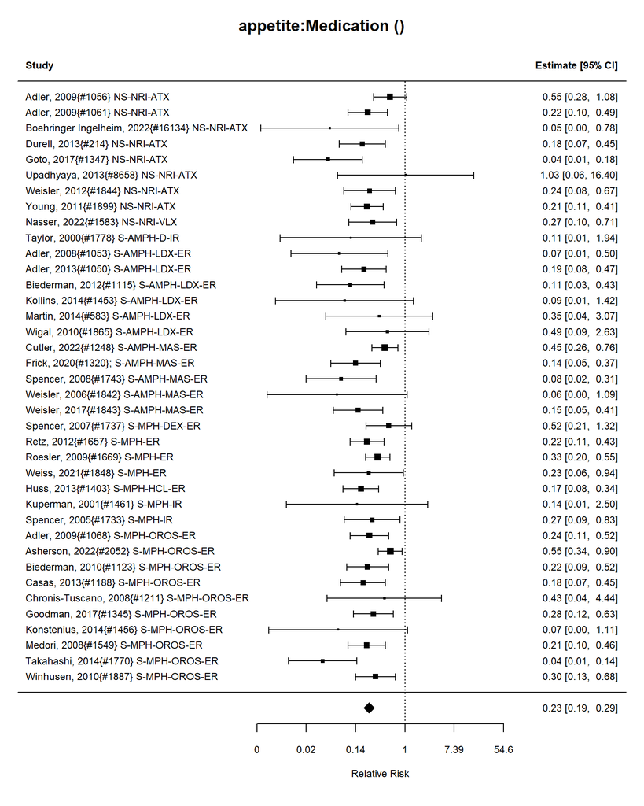

Number of studies = 38  
Intervention sample = 4487  
Control sample = 4006  
Total sample = 8493

### Relative Risk Estimate

|  | estimate | se | tval | df | pval | ci.lb | ci.ub |
| --- | --- | --- | --- | --- | --- | --- | --- |
| intrcpt | 0.2345703 | 1.105171 | 5e-07 | 1.171914e+16 | 1 | 0.1920499 | 0.2865048 |

I-squared = 34 %

##### Publication Bias Tests

###### Begg (non-parametric)

```
Rank Correlation Test for Funnel Plot Asymmetry

Kendall's tau = -0.2290, p = 0.0437
```

###### Egger (parametric)

```
Regression Test for Funnel Plot Asymmetry

Model:     mixed-effects meta-regression model
Predictor: standard error

Test for Funnel Plot Asymmetry: t = -3.4517, df = 36, p = 0.0014
Limit Estimate (as sei -> 0):   b = -0.8049 (CI: -1.1894, -0.4205)
```

###### Trim and Fill

Estimate and CIs

|  | estimate | ci.lb | ci.ub |
| --- | --- | --- | --- |
| intrcpt | 0.27 | 0.22 | 0.34 |

TrimFill Relative Risk Estimate: 0

###### int_stimulant vs int_nonstimulant meta-regression

### Meta-regression: stimulant vs non-stimulant

| term | type | estimate | std.error | statistic | p.value |
| --- | --- | --- | --- | --- | --- |
| intercept | summary | -1.461 | 0.219 | -6.675 | 0.000 |
| stimulant_studyTRUE | summary | 0.007 | 0.247 | 0.030 | 0.976 |

### Meta-regression: AMPH vs MPH

### AMPH vs MPH meta-regression

17 nMPH studies

| term | type | estimate | std.error | statistic | p.value |
| --- | --- | --- | --- | --- | --- |
| intercept | summary | -1.410 | 0.134 | -10.548 | 0.000 |
| AMPHTRUE | summary | -0.124 | 0.234 | -0.531 | 0.599 |

## Meta-regression: Indirect comparison between combined vs(medication plus psychosocial) and medication

38 medication studies

0 combined studies

Not enough studies to compare medication and combined

## Meta-regression: Indirect comparison between combined vs(medication plus psychosocial) and psychosocial

0 psychosocial studies

0 combined studies

Not enough studies to compare psychosocial and combined

### Outcome: mood:continuous Intervention: Medication

No data #1.

### Outcome: mood:categorical Intervention: Medication

Outcome name: mood Analyzing 19 studies.

Analyzing 19 studies.

### Control Types

| control | n |
| --- | --- |
| Placebo | 19 |

| ID | measure | yi | se | study.design |
| --- | --- | --- | --- | --- |
| Adler, 2009{#1056} NS-NRI-ATX | Irritability | 0.31 | 0.38 | RCT |
| Adler, 2009{#1061} NS-NRI-ATX | Irritability | -0.71 | 0.45 | RCT |
| Boehringer Ingelheim, 2022{#16134} NS-NRI-ATX | Irritability | -0.69 | 1.20 | RCT |
| Durell, 2013{#214} NS-NRI-ATX | Irritatibility | -1.15 | 0.57 | RCT |
| Young, 2011{#1899} NS-NRI-ATX | Irritability | -0.15 | 0.29 | RCT |
| Taylor, 2000{#1778} S-AMPH-D-IR | Irritability | -0.41 | 0.86 | RCT |
| Adler, 2013{#1050} S-AMPH-LDX-ER | Irritability | -0.99 | 0.66 | RCT |
| Biederman, 2012{#1115} S-AMPH-LDX-ER | Agitated/irritable | -1.58 | 1.53 | RCT |
| Kollins, 2014{#1453} S-AMPH-LDX-ER | Irritability | -0.97 | 1.10 | RCT |
| Cutler, 2022{#1248} S-AMPH-MAS-ER | Irritability | -0.84 | 0.51 | RCT |
| Frick, 2020{#1320}; S-AMPH-MAS-ER | Irritability | -0.02 | 0.69 | RCT |
| Levin, 2024{#2765} S-AMPH-MAS-ER | Irritable | -1.23 | 1.59 | RCT |
| Weisler, 2017{#1843} S-AMPH-MAS-ER | Irritability | -1.93 | 1.50 | RCT |
| Huss, 2013{#1403} S-MPH-HCL-ER | Irritability adverse event during double-blind dose-confirmation stage | -0.40 | 0.44 | RCT |
| Spencer, 2005{#1733} S-MPH-IR | Irritable | -0.72 | 1.54 | RCT |
| Adler, 2009{#1068} S-MPH-OROS-ER | Irritability due to intervention | -1.31 | 0.79 | RCT |
| Biederman, 2010{#1123} S-MPH-OROS-ER | Agitated/Irritable adverse event | -0.04 | 0.56 | RCT |
| Goodman, 2017{#1345} S-MPH-OROS-ER | Irritability | -0.61 | 0.50 | RCT |
| Medori, 2008{#1549} S-MPH-OROS-ER | Irritability | -2.14 | 1.04 | RCT |

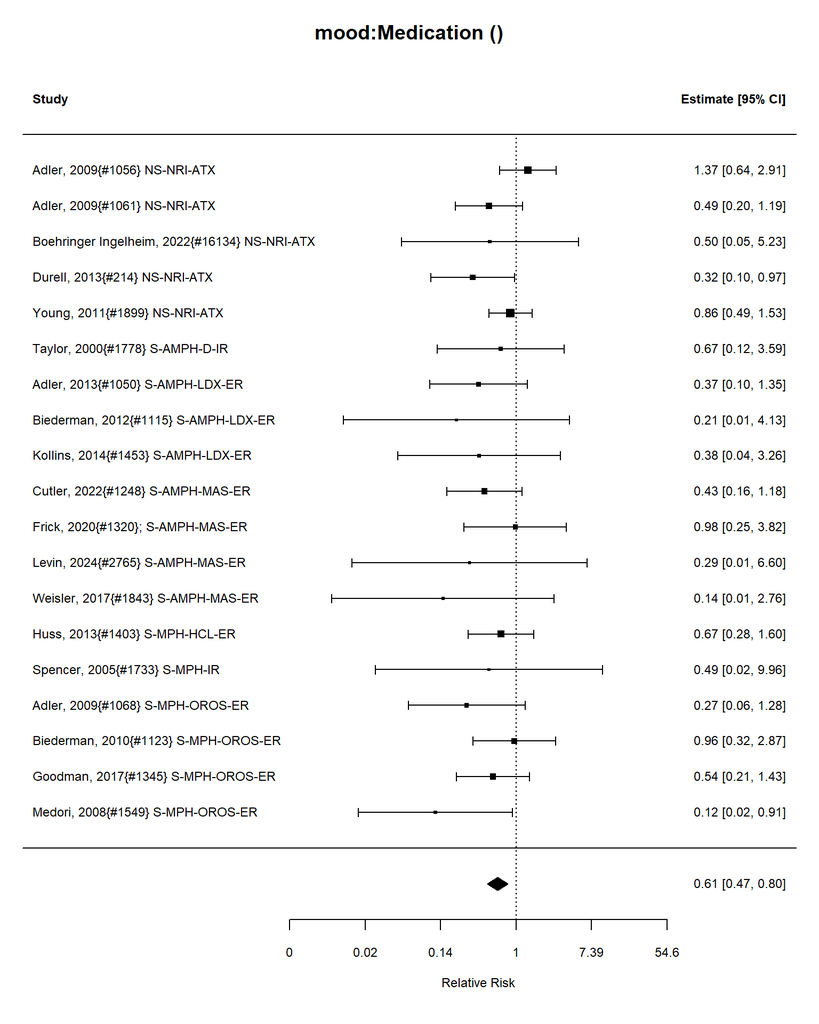

Number of studies = 19  
Intervention sample = 2135  
Control sample = 2063  
Total sample = 4198

### Relative Risk Estimate

|  | estimate | se | tval | df | pval | ci.lb | ci.ub |
| --- | --- | --- | --- | --- | --- | --- | --- |
| intrcpt | 0.6065307 | 1.138828 | 0.0202419 | 65659969 | 1 | 0.4676664 | 0.7945336 |

I-squared = 9 %

##### Publication Bias Tests

###### Begg (non-parametric)

```
Rank Correlation Test for Funnel Plot Asymmetry

Kendall's tau = -0.2749, p = 0.1082
```

###### Egger (parametric)

```
Regression Test for Funnel Plot Asymmetry

Model:     mixed-effects meta-regression model
Predictor: standard error

Test for Funnel Plot Asymmetry: t = -3.1675, df = 17, p = 0.0056
Limit Estimate (as sei -> 0):   b =  0.1800 (CI: -0.2981, 0.6580)
```

###### Trim and Fill

Estimate and CIs

|  | estimate | ci.lb | ci.ub |
| --- | --- | --- | --- |
| intrcpt | 0.75 | 0.58 | 0.97 |

TrimFill Relative Risk Estimate: 1

###### int_stimulant vs int_nonstimulant meta-regression

### Meta-regression: stimulant vs non-stimulant

14 stimulant studies

5 nonstimulant studies

| term | type | estimate | std.error | statistic | p.value |
| --- | --- | --- | --- | --- | --- |
| intercept | summary | -0.261 | 0.166 | -1.569 | 0.135 |
| stimulant_studyTRUE | summary | -0.405 | 0.236 | -1.720 | 0.104 |

### Meta-regression: AMPH vs MPH

### AMPH vs MPH meta-regression

8n AMPH studies

6 nMPH studies

| term | type | estimate | std.error | statistic | p.value |
| --- | --- | --- | --- | --- | --- |
| intercept | summary | -0.591 | 0.190 | -3.104 | 0.009 |
| AMPHTRUE | summary | -0.173 | 0.289 | -0.598 | 0.561 |

## Meta-regression: Indirect comparison between combined vs(medication plus psychosocial) and medication

19 medication studies

0 combined studies

Not enough studies to compare medication and combined

## Meta-regression: Indirect comparison between combined vs(medication plus psychosocial) and psychosocial

0 psychosocial studies

0 combined studies

Not enough studies to compare psychosocial and combined

# Intervention: Neurofeedback

### Outcome: functional:continuous Intervention: Neurofeedback

No data #1.

### Outcome: functional:categorical Intervention: Neurofeedback

Outcome name: functional Analyzing 0 studies.

No data.

### Outcome: cognitive:continuous Intervention: Neurofeedback

| ID | measure | mean_ctrl_cont | SD_ctrl_cont | n_ctrl_cont | mean_int_cont | SD_int_cont | n_int_cont | yi | se | study.design |
| --- | --- | --- | --- | --- | --- | --- | --- | --- | --- | --- |
| Barth, 2021{#1101} | CFT-20-R ( Cattell’s Fluid Test), measures ability to think logically and solve problems | 117.50 | 16.91 | 20 | 117.36 | 15.39 | 24 | -0.0085417 | 0.3027664 | RCT |
| Cowley, 2016{#2288} | TOVA (Test of Variables of Attention), Omission errors, change from baseline | -46.25 | 198.84 | 21 | 10.10 | 72.73 | 23 | 0.3765354 | 0.3044806 | RCT |
| Salomone, 2015{#3175} | TEA (Test of Everyday Attention) Elevator Counting with Distraction | 7.80 | 2.60 | 14 | 8.75 | 1.24 | 15 | 0.4586845 | 0.3764607 | RCT |
| Schonenberg, 2017{#1699} | CPT (Continuous Performance Task) | 462.40 | 108.60 | 38 | 505.94 | 111.35 | 37 | 0.3918608 | 0.2331663 | RCT |

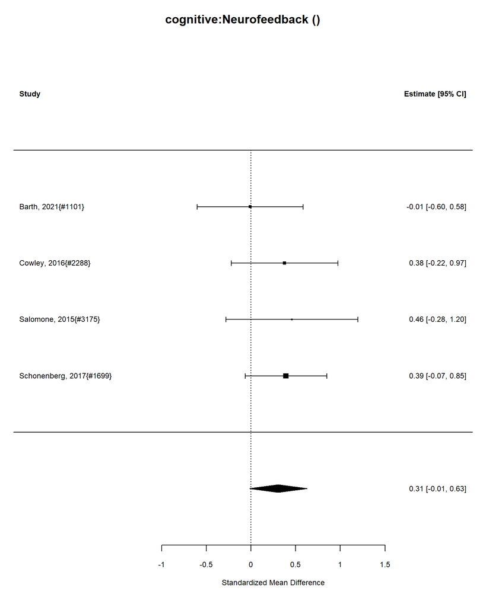

| estimate | conf.low | conf.high |
| --- | --- | --- |
| 0.31 | -0.01 | 0.63 |

Number of studies = 4

Intervention sample = 99

Control sample = 93

Total sample = 192.

I-squared = 0 %

Convert Effect Size to Real Units

Estimated effect in original units = 24.99.

##### Publication Bias Tests

###### Begg (non-parametric)

Rank Correlation Test for Funnel Plot Asymmetry Kendall’s tau = 0.0000, p = 1.0000

###### Egger (parametric)

Regression Test for Funnel Plot Asymmetry

Model: mixed-effects meta-regression model Predictor: standard error

Test for Funnel Plot Asymmetry: t = -0.1025, df = 2, p = 0.9277 Limit Estimate (as sei -> 0): b = 0.3787 (CI: -2.7309, 3.4883)

###### Trim and Fill

Estimate and Cis

|  | estimate | ci.lb | ci.ub |
| --- | --- | --- | --- |
| intrcpt | 0.31 | -0.01 | 0.63 |

### Meta-regression: stimulant vs non-stimulant

0 stimulant studies

0 nonstimulant studies

Not enough studies to compare stimulant and nonstimulant

### Meta-regression: AMPH vs MPH

### AMPH vs MPH meta-regression

0n AMPH studies

0 nMPH studies

Not enough studies to compare AMPH and MPH

## Meta-regression: Indirect comparison between combined vs(medication plus psychosocial) and medication

0 medication studies

0 combined studies

Not enough studies to compare medication and combined

## Meta-regression: Indirect comparison between combined vs(medication plus psychosocial) and psychosocial

0 psychosocial studies

0 combined studies

Not enough studies to compare psychosocial and combined

### Outcome: cognitive:categorical Intervention: Neurofeedback

Outcome name: cognitive Analyzing 0 studies.

No data.

### Outcome: symptom:continuous Intervention: Neurofeedback

| ID | measure | mean_ctrl_cont | SD_ctrl_cont | n_ctrl_cont | mean_int_cont | SD_int_cont | n_int_cont | yi | se | study.design |
| --- | --- | --- | --- | --- | --- | --- | --- | --- | --- | --- |
| Barth, 2021{#1101} | ADHS-SB, (German ADHD rating scale) | 20.81 | 9.03 | 20 | 22.49 | 5.90 | 24 | 0.2205606 | 0.3036766 | RCT |
| Cowley, 2016{#2288} | ASRS (Adult ADHD Self-Report Scale), change from baseline | -0.14 | 1.06 | 21 | -1.20 | 2.17 | 23 | -0.6008248 | 0.3085441 | RCT |
| Salomone, 2015{#3175} | CAARS (Conners’ Adult ADHD Rating Scale), ADHD Index | 67.27 | 12.01 | 14 | 57.13 | 12.44 | 15 | -0.8055068 | 0.3863705 | RCT |
| Schonenberg, 2017{#1699} | CAARS (Conners’ adult ADHD rating scale) | 94.25 | 27.23 | 38 | 103.51 | 30.62 | 37 | 0.3165467 | 0.2324023 | RCT |

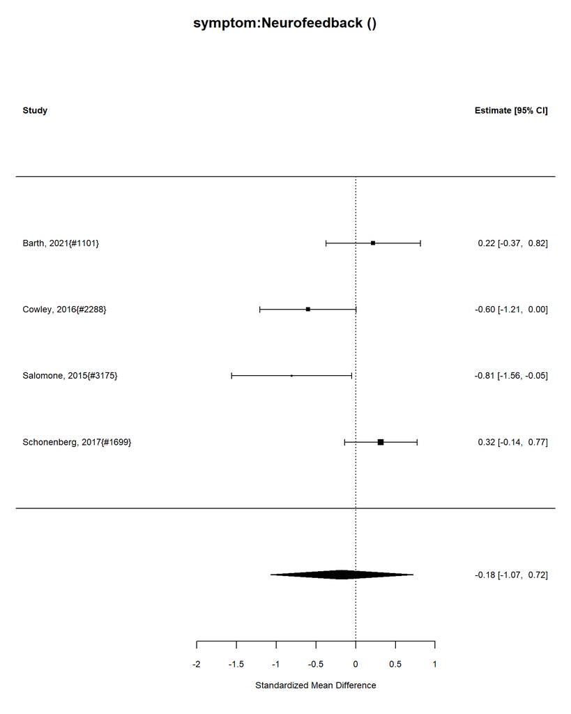

| estimate | conf.low | conf.high |
| --- | --- | --- |
| -0.18 | -1.07 | 0.72 |

Number of studies = 4

Intervention sample = 99

Control sample = 93

Total sample = 192.

I-squared = 71 %

Convert Effect Size to Real Units

Estimated effect in original units = -2.16.

##### Publication Bias Tests

###### Begg (non-parametric)

Rank Correlation Test for Funnel Plot Asymmetry Kendall’s tau = -1.0000, p = 0.0833

###### Egger (parametric)

Regression Test for Funnel Plot Asymmetry

Model: mixed-effects meta-regression model Predictor: standard error

Test for Funnel Plot Asymmetry: t = -2.0286, df = 2, p = 0.1797 Limit Estimate (as sei -> 0): b = 2.0587 (CI: -2.6647, 6.7821)

###### Trim and Fill

Estimate and Cis

|  | estimate | ci.lb | ci.ub |
| --- | --- | --- | --- |
| intrcpt | -0.01 | -0.56 | 0.55 |

### Meta-regression: stimulant vs non-stimulant

0 stimulant studies

0 nonstimulant studies

Not enough studies to compare stimulant and nonstimulant

### Meta-regression: AMPH vs MPH

### AMPH vs MPH meta-regression

0n AMPH studies

0 nMPH studies

Not enough studies to compare AMPH and MPH

## Meta-regression: Indirect comparison between combined vs(medication plus psychosocial) and medication

0 medication studies

0 combined studies

Not enough studies to compare medication and combined

## Meta-regression: Indirect comparison between combined vs(medication plus psychosocial) and psychosocial

0 psychosocial studies

0 combined studies

Not enough studies to compare psychosocial and combined

### Outcome: symptom:categorical Intervention: Neurofeedback

Outcome name: symptom Analyzing 1 studies.

Analyzing 1 studies.

### Control Types

| control | n |
| --- | --- |
| Attention-matched control | 1 |

| ID | measure | yi | se | study.design |
| --- | --- | --- | --- | --- |
| Barth, 2021{#1101} | ADHS-SB (ADHD Self-Rating Scale) – Global score, number who improved | -0.06 | 0.24 | RCT |

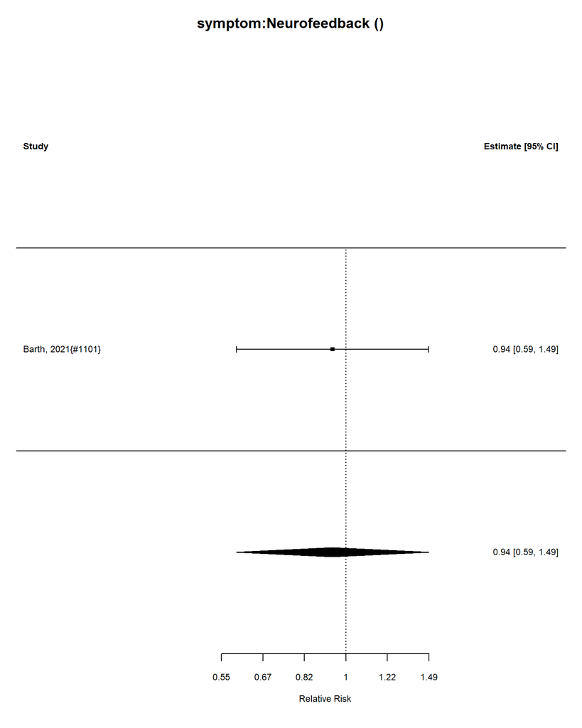

Number of studies = 1  
Intervention sample = 25  
Control sample = 20  
Total sample = 45

### Relative Risk Estimate

|  | estimate | se | zval | pval | ci.lb | ci.ub |
| --- | --- | --- | --- | --- | --- | --- |
| intrcpt | 0.9417645 | 1.271249 | 0.7633795 | 2.181472 | 0.588605 | 1.491825 |

I-squared = 0 %

### Outcome: substance_use:continuous Intervention: Neurofeedback

No data #1.

### Outcome: substance_use:categorical Intervention: Neurofeedback

Outcome name: substance_use Analyzing 0 studies.

No data.

### Outcome: relationship:continuous Intervention: Neurofeedback

No data #1.

### Outcome: relationship:categorical Intervention: Neurofeedback

Outcome name: relationship Analyzing 0 studies.

No data.

### Outcome: BP:continuous Intervention: Neurofeedback

No data #1.

### Outcome: BP:categorical Intervention: Neurofeedback

Outcome name: BP Analyzing 0 studies.

No data.

### Outcome: sleep_disturbance:continuous Intervention: Neurofeedback

| ID | measure | mean_ctrl_cont | SD_ctrl_cont | n_ctrl_cont | mean_int_cont | SD_int_cont | n_int_cont | yi | se | study.design |
| --- | --- | --- | --- | --- | --- | --- | --- | --- | --- | --- |
| Cowley, 2016{#2288} | PSQI (Pittsburgh Sleep Quality Index) | 6.5 | 2.4 | 21 | 5.8 | 2.1 | 23 | -0.3058081 | 0.3035787 | RCT |

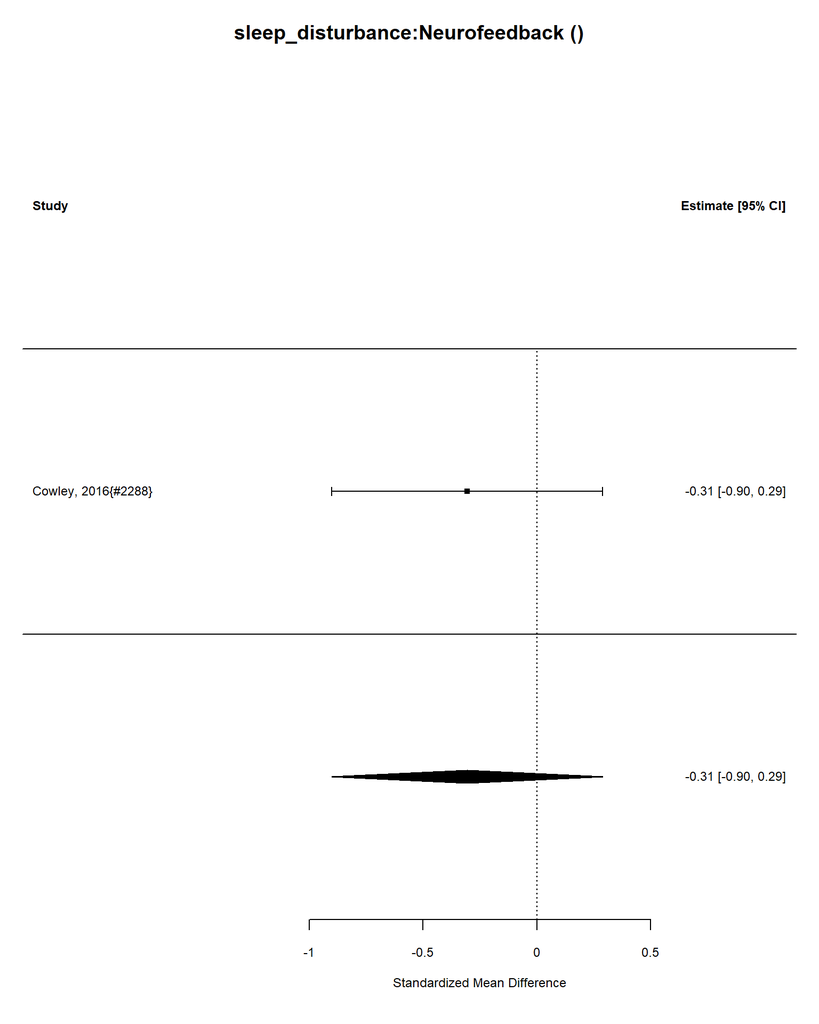

| estimate | conf.low | conf.high |
| --- | --- | --- |
| -0.31 | -0.9 | 0.29 |

Number of studies = 1

Intervention sample = 23

Control sample = 21

Total sample = 44.

I-squared = 0 %

Convert Effect Size to Real Units

Estimated effect in original units = -0.73.

### Outcome: sleep_disturbance:categorical Intervention: Neurofeedback

Outcome name: sleep_disturbance Analyzing 0 studies.

No data.

### Outcome: AEs:continuous Intervention: Neurofeedback

No data #1.

### Outcome: AEs:categorical Intervention: Neurofeedback

Outcome name: AEs Analyzing 0 studies.

No data.

### Outcome: mortality:continuous Intervention: Neurofeedback

No data #1.

### Outcome: mortality:categorical Intervention: Neurofeedback

Outcome name: mortality Analyzing 0 studies.

No data.

### Outcome: behavior:continuous Intervention: Neurofeedback

No data #1.

### Outcome: behavior:categorical Intervention: Neurofeedback

Outcome name: behavior Analyzing 0 studies.

No data.

### Outcome: appetite:continuous Intervention: Neurofeedback

No data #1.

### Outcome: appetite:categorical Intervention: Neurofeedback

Outcome name: appetite Analyzing 0 studies.

No data.

### Outcome: mood:continuous Intervention: Neurofeedback

No data #1.

### Outcome: mood:categorical Intervention: Neurofeedback

Outcome name: mood Analyzing 0 studies.

No data.

# Intervention: Neurostimulation

### Outcome: functional:continuous Intervention: Neurostimulation

| ID | measure | mean_ctrl_cont | SD_ctrl_cont | n_ctrl_cont | mean_int_cont | SD_int_cont | n_int_cont | yi | se | study.design |
| --- | --- | --- | --- | --- | --- | --- | --- | --- | --- | --- |
| Fu, 2025{#15438} tACS | WFIRS-S (Weiss Functional Impairment Rating Scale) - work | 7.46 | 5.53 | 28 | 7.46 | 7.36 | 28 | 0 | 0.2672612 | RCT |

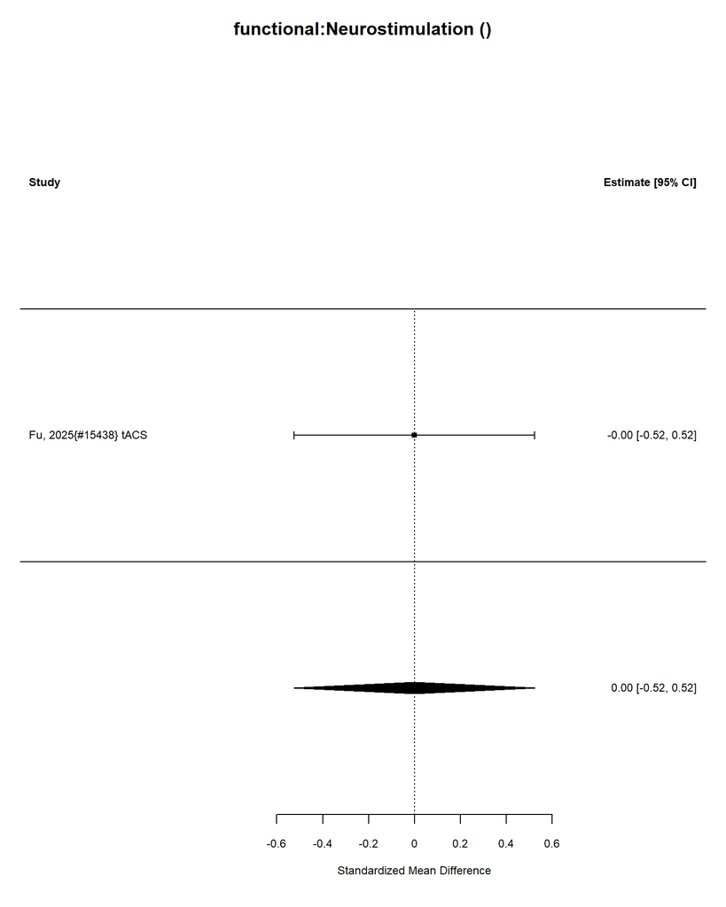

| estimate | conf.low | conf.high |
| --- | --- | --- |
| 0 | -0.52 | 0.52 |

Number of studies = 1

Intervention sample = 28

Control sample = 28

Total sample = 56.

I-squared = 0 %

Convert Effect Size to Real Units

Estimated effect in original units = 0.

### Outcome: functional:categorical Intervention: Neurostimulation

Outcome name: functional Analyzing 0 studies.

No data.

### Outcome: cognitive:continuous Intervention: Neurostimulation

| ID | measure | mean_ctrl_cont | SD_ctrl_cont | n_ctrl_cont | mean_int_cont | SD_int_cont | n_int_cont | yi | se | study.design |
| --- | --- | --- | --- | --- | --- | --- | --- | --- | --- | --- |
| Loughead, 2018{#6054} TMS | CPT (Conners Continuous Performance Test), sustained attention | -4.80 | 18.00 | 13 | -16.20 | 17.60 | 14 | 0.6212490 | 0.3943335 | RCT |
| Paz, 2017{#1621} dTMS | TOVA (Test of Variables of Attention) total score | 0.31 | 3.86 | 13 | 3.27 | 5.49 | 9 | 0.6214061 | 0.4436330 | RCT |
| Barham, 2022{#1096} tDCS | Digit Span Backward Test | 5.27 | 1.00 | 11 | 5.70 | 1.05 | 11 | 0.4034275 | 0.4307170 | RCT |

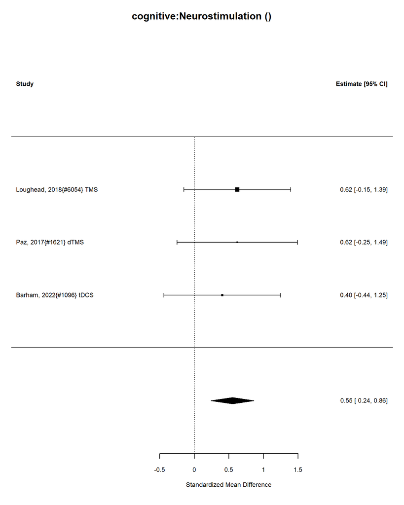

| estimate | conf.low | conf.high |
| --- | --- | --- |
| 0.55 | 0.24 | 0.86 |

Number of studies = 3

Intervention sample = 34

Control sample = 37

Total sample = 71.

I-squared = 0 %

Convert Effect Size to Real Units

Estimated effect in original units = 4.2.

##### Publication Bias Tests

###### Begg (non-parametric)

Rank Correlation Test for Funnel Plot Asymmetry Kendall’s tau = -0.3333, p = 1.0000

###### Egger (parametric)

Regression Test for Funnel Plot Asymmetry

Model: mixed-effects meta-regression model Predictor: standard error

Test for Funnel Plot Asymmetry: t = -0.3367, df = 1, p = 0.7933 Limit Estimate (as sei -> 0): b = 1.1912 (CI: -22.9718, 25.3543)

###### Trim and Fill

Estimate and Cis

|  | estimate | ci.lb | ci.ub |
| --- | --- | --- | --- |
| intrcpt | 0.55 | 0.24 | 0.86 |

### Meta-regression: stimulant vs non-stimulant

0 stimulant studies

0 nonstimulant studies

Not enough studies to compare stimulant and nonstimulant

### Meta-regression: AMPH vs MPH

### AMPH vs MPH meta-regression

0n AMPH studies

0 nMPH studies

Not enough studies to compare AMPH and MPH

## Meta-regression: Indirect comparison between combined vs(medication plus psychosocial) and medication

0 medication studies

0 combined studies

Not enough studies to compare medication and combined

## Meta-regression: Indirect comparison between combined vs(medication plus psychosocial) and psychosocial

0 psychosocial studies

0 combined studies

Not enough studies to compare psychosocial and combined

### Outcome: cognitive:categorical Intervention: Neurostimulation

Outcome name: cognitive Analyzing 0 studies.

No data.

### Outcome: symptom:continuous Intervention: Neurostimulation

| ID | measure | mean_ctrl_cont | SD_ctrl_cont | n_ctrl_cont | mean_int_cont | SD_int_cont | n_int_cont | yi | se | study.design |
| --- | --- | --- | --- | --- | --- | --- | --- | --- | --- | --- |
| Loughead, 2018{#6054} TMS | CAARS-S:L (Conners Adult ADHD Rating Scale – Self-Report: Long Version) | -5.10 | 7.60 | 13 | -4.40 | 9.40 | 14 | 0.0790788 | 0.3853147 | RCT |
| Paz, 2017{#1621} dTMS | CAARS (Conners’ Adult ADHD Rating Scale) | 70.77 | 11.01 | 13 | 72.11 | 13.02 | 9 | 0.1087313 | 0.4339388 | RCT |
| Alyagon, 2020{#1078} rTMS | CAARS (Conners’ Adult ADHD Rating Scale) total ADHD symptoms | 4.61 | 10.93 | 14 | 9.55 | 12.27 | 15 | -0.4123364 | 0.3755351 | RCT |
| Fu, 2025{#15438} tACS | Adult ADHD Self-Report Scale | -9.80 | 7.10 | 28 | -17.00 | 8.90 | 28 | -0.8818691 | 0.2799505 | RCT |
| Leffa, 2022{#1473} tDCS | CASRS-I (Conner’s Adult ADHD Self-Report Scale) Inattention | 23.63 | 3.97 | 30 | 18.88 | 5.79 | 25 | -0.9597076 | 0.2858433 | RCT |

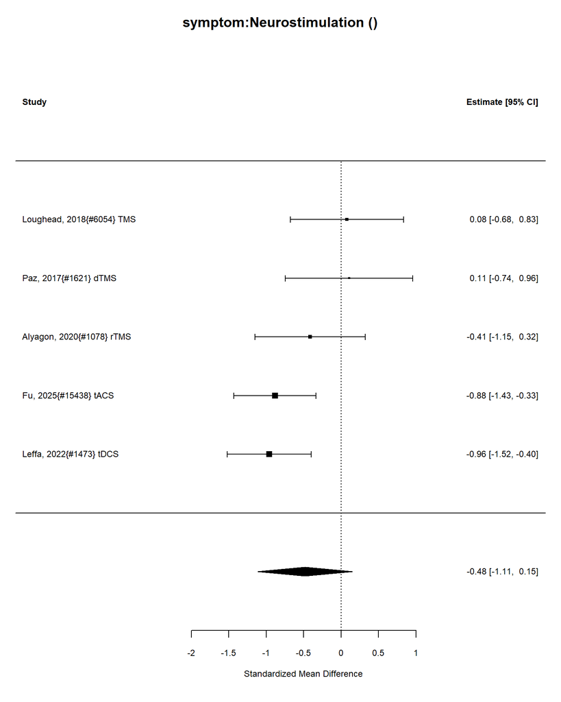

| estimate | conf.low | conf.high |
| --- | --- | --- |
| -0.48 | -1.11 | 0.15 |

Number of studies = 5

Intervention sample = 91

Control sample = 98

Total sample = 189.

I-squared = 54 %

Convert Effect Size to Real Units

Estimated effect in original units = -3.92.

##### Publication Bias Tests

###### Begg (non-parametric)

Rank Correlation Test for Funnel Plot Asymmetry Kendall’s tau = 0.6000, p = 0.2333

###### Egger (parametric)

Regression Test for Funnel Plot Asymmetry

Model: mixed-effects meta-regression model Predictor: standard error

Test for Funnel Plot Asymmetry: t = 5.6008, df = 3, p = 0.0112 Limit Estimate (as sei -> 0): b = -2.9675 (CI: -4.3549, -1.5800)

###### Trim and Fill

Estimate and Cis

|  | estimate | ci.lb | ci.ub |
| --- | --- | --- | --- |
| intrcpt | -0.59 | -1.03 | -0.16 |

### Meta-regression: stimulant vs non-stimulant

0 stimulant studies

0 nonstimulant studies

Not enough studies to compare stimulant and nonstimulant

### Meta-regression: AMPH vs MPH

### AMPH vs MPH meta-regression

0n AMPH studies

0 nMPH studies

Not enough studies to compare AMPH and MPH

## Meta-regression: Indirect comparison between combined vs(medication plus psychosocial) and medication

0 medication studies

0 combined studies

Not enough studies to compare medication and combined

## Meta-regression: Indirect comparison between combined vs(medication plus psychosocial) and psychosocial

0 psychosocial studies

0 combined studies

Not enough studies to compare psychosocial and combined

### Outcome: symptom:categorical Intervention: Neurostimulation

Outcome name: symptom Analyzing 1 studies.

Analyzing 1 studies.

### Control Types

| control | n |
| --- | --- |
| Attention-matched control | 1 |

| ID | measure | yi | se | study.design |
| --- | --- | --- | --- | --- |
| Leffa, 2022{#1473} tDCS | CASRS-I, Inattention scale, number achieving 30% reduction | -1.7 | 0.73 | RCT |

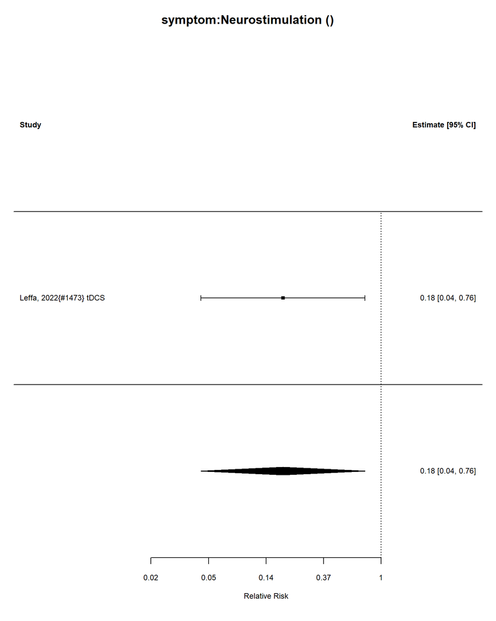

Number of studies = 1  
Intervention sample = 32  
Control sample = 32  
Total sample = 64

### Relative Risk Estimate

|  | estimate | se | zval | pval | ci.lb | ci.ub |
| --- | --- | --- | --- | --- | --- | --- |
| intrcpt | 0.1826835 | 2.075081 | 0.0953692 | 1.020201 | 0.0437178 | 0.7557837 |

I-squared = 0 %

### Outcome: substance_use:continuous Intervention: Neurostimulation

No data #1.

### Outcome: substance_use:categorical Intervention: Neurostimulation

Outcome name: substance_use Analyzing 0 studies.

No data.

### Outcome: relationship:continuous Intervention: Neurostimulation

No data #1.

### Outcome: relationship:categorical Intervention: Neurostimulation

Outcome name: relationship Analyzing 0 studies.

No data.

### Outcome: BP:continuous Intervention: Neurostimulation

No data #1.

### Outcome: BP:categorical Intervention: Neurostimulation

Outcome name: BP Analyzing 0 studies.

No data.

### Outcome: sleep_disturbance:continuous Intervention: Neurostimulation

| ID | measure | mean_ctrl_cont | SD_ctrl_cont | n_ctrl_cont | mean_int_cont | SD_int_cont | n_int_cont | yi | se | study.design |
| --- | --- | --- | --- | --- | --- | --- | --- | --- | --- | --- |
| Fu, 2025{#15438} tACS | PSQI (Pittsburgh Sleep Quality Index) | 2.96 | 2.66 | 28 | 3.54 | 2.94 | 28 | 0.2039954 | 0.2679555 | RCT |

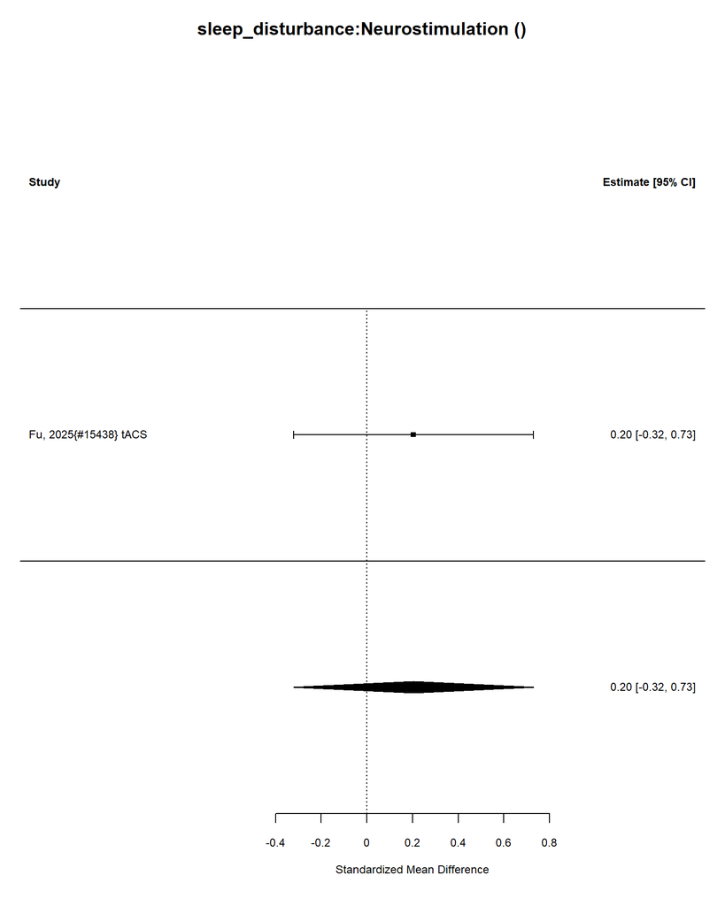

| estimate | conf.low | conf.high |
| --- | --- | --- |
| 0.2 | -0.32 | 0.73 |

Number of studies = 1

Intervention sample = 28

Control sample = 28

Total sample = 56.

I-squared = 0 %

Convert Effect Size to Real Units

Estimated effect in original units = 0.54.

### Outcome: sleep_disturbance:categorical Intervention: Neurostimulation

Outcome name: sleep_disturbance Analyzing 0 studies.

No data.

### Outcome: AEs:continuous Intervention: Neurostimulation

No data #1.

### Outcome: AEs:categorical Intervention: Neurostimulation

Outcome name: AEs Analyzing 1 studies.

Analyzing 1 studies.

### Control Types

| control | n |
| --- | --- |
| Placebo | 1 |

| ID | measure | yi | se | study.design |
| --- | --- | --- | --- | --- |
| Loughead, 2018{#6054} TMS | Number of participants who experienced at least one adverse event during the 4-week intervention period | 1.13 | 1.06 | RCT |

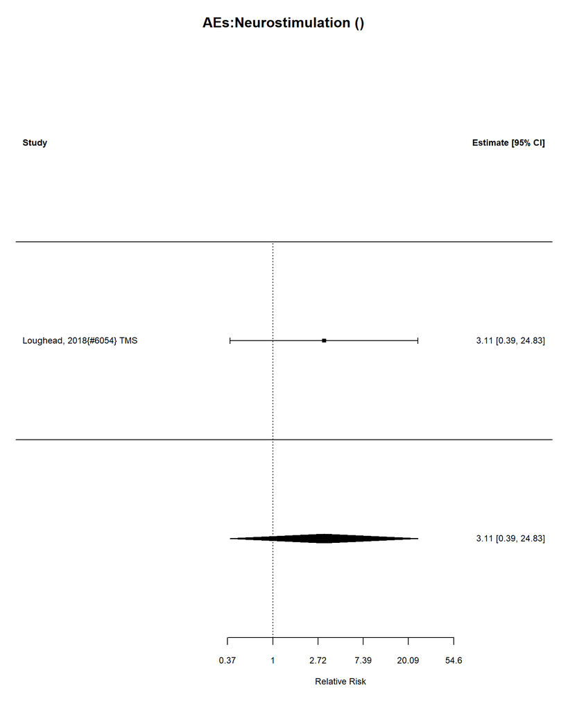

Number of studies = 1  
Intervention sample = 18  
Control sample = 14  
Total sample = 32

### Relative Risk Estimate

|  | estimate | se | zval | pval | ci.lb | ci.ub |
| --- | --- | --- | --- | --- | --- | --- |
| intrcpt | 3.095657 | 2.886371 | 2.915379 | 1.32313 | 0.3906278 | 24.77909 |

I-squared = 0 %

### Outcome: mortality:continuous Intervention: Neurostimulation

No data #1.

### Outcome: mortality:categorical Intervention: Neurostimulation

Outcome name: mortality Analyzing 1 studies.

Analyzing 1 studies.

### Control Types

| control | n |
| --- | --- |
| Placebo | 1 |

| ID | measure | yi | se | study.design |
| --- | --- | --- | --- | --- |
| Loughead, 2018{#6054} TMS | All-cause mortality | 0.24 | 1.97 | RCT |

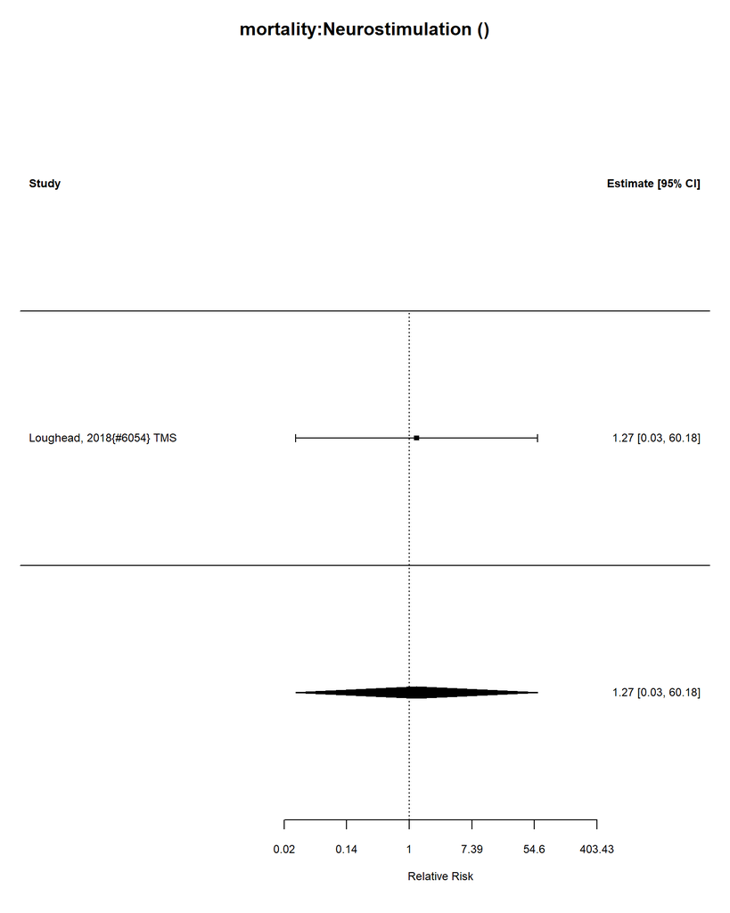

Number of studies = 1  
Intervention sample = 18  
Control sample = 14  
Total sample = 32

### Relative Risk Estimate

|  | estimate | se | zval | pval | ci.lb | ci.ub |
| --- | --- | --- | --- | --- | --- | --- |
| intrcpt | 1.271249 | 7.170676 | 1.127497 | 2.459603 | 0.0267827 | 60.34029 |

I-squared = 0 %

### Outcome: behavior:continuous Intervention: Neurostimulation

No data #1.

### Outcome: behavior:categorical Intervention: Neurostimulation

Outcome name: behavior Analyzing 0 studies.

No data.

### Outcome: appetite:continuous Intervention: Neurostimulation

No data #1.

### Outcome: appetite:categorical Intervention: Neurostimulation

Outcome name: appetite Analyzing 1 studies.

Analyzing 1 studies.

### Control Types

| control | n |
| --- | --- |
| Placebo | 1 |

| ID | measure | yi | se | study.design |
| --- | --- | --- | --- | --- |
| Fu, 2025{#15438} tACS | Loss of appetite | 0 | 1.98 | RCT |

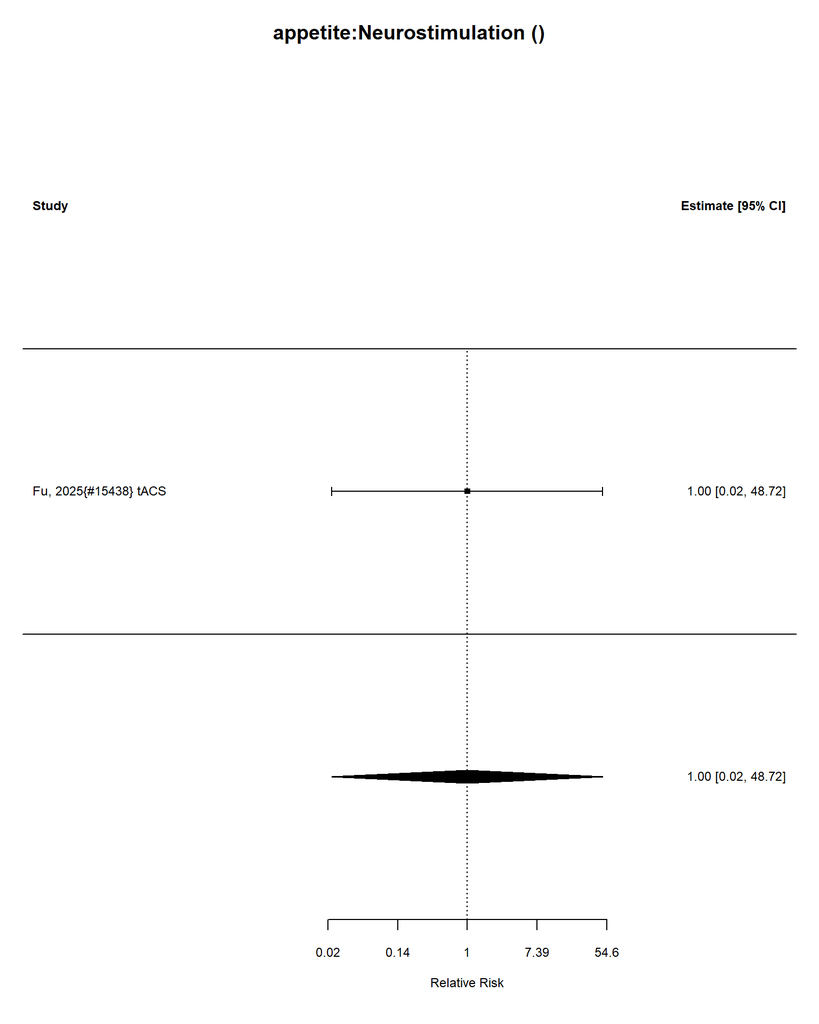

Number of studies = 1  
Intervention sample = 28  
Control sample = 28  
Total sample = 56

### Relative Risk Estimate

|  | estimate | se | zval | pval | ci.lb | ci.ub |
| --- | --- | --- | --- | --- | --- | --- |
| intrcpt | 1 | 7.242743 | 1 | 2.718282 | 0.0204453 | 48.91089 |

I-squared = 0 %

### Outcome: mood:continuous Intervention: Neurostimulation

No data #1.

### Outcome: mood:categorical Intervention: Neurostimulation

Outcome name: mood Analyzing 0 studies.

No data.

# Intervention: New pharmaceutical agent

### Outcome: functional:continuous Intervention: New pharmaceutical agent

| ID | measure | mean_ctrl_cont | SD_ctrl_cont | n_ctrl_cont | mean_int_cont | SD_int_cont | n_int_cont | yi | se | study.design |
| --- | --- | --- | --- | --- | --- | --- | --- | --- | --- | --- |
| Bain, 2012{#1094} | WPAI (Work Productivity and Activity Impairment scale) | 0.11 | 0.22 | 53 | 0.11 | 0.22 | 53 | 0.0000000 | 0.1942572 | RCT |
| Biederman, 2019{#1117} | SDS (Sheehan Disability Scale) | 0.60 | 0.90 | 20 | -1.40 | 1.10 | 20 | -1.9504926 | 0.3841292 | RCT |
| Ernst, 1996{#1290} | GAS (Global Assessment Scale) | 71.00 | 10.00 | 7 | 63.20 | 7.80 | 10 | -0.8462959 | 0.5137337 | RCT |
| Reimherr, 2005{#3108} | GAF (Global Assessment of Functioning) | 56.20 | 3.60 | 18 | 57.50 | 8.10 | 29 | 0.1890353 | 0.3006966 | RCT |
| Riahi, 2010{#1658} | GAF (Global Assessment of Functioning) Scale | 5.05 | 0.42 | 17 | 6.13 | 0.83 | 22 | -1.5476429 | 0.3674041 | RCT |
| Surman, 2024{#4951} | GAF (Global Assessment of Functioning), change from baseline | -0.30 | 4.97 | 31 | -4.80 | 4.80 | 29 | -0.9085328 | 0.2713290 | RCT |
| Theravance Biopharma, 2011{#10952} | BDEFS-SF (Barkley Deficits in Executive Functioning Scale – Short Form), change from baseline | -9.80 | 13.50 | 75 | -11.60 | 13.20 | 79 | -0.1341961 | 0.1614002 | RCT |
| Wilens, 2005{#1878} | GAF (Global Assessment of Functioning), change from baseline | 4.00 | 8.00 | 81 | 7.30 | 10.40 | 81 | -0.3540124 | 0.1583609 | RCT |

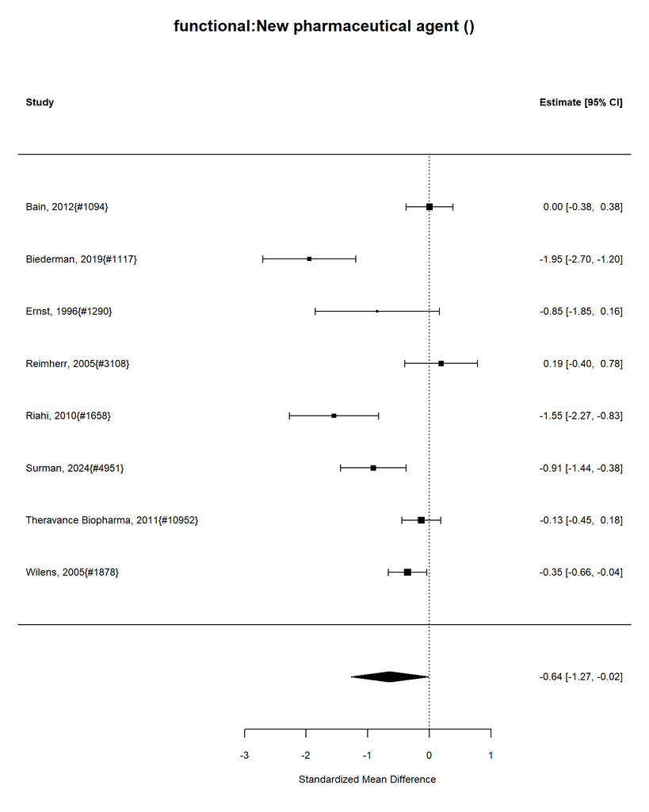

| estimate | conf.low | conf.high |
| --- | --- | --- |
| -0.64 | -1.27 | -0.02 |

Number of studies = 8

Intervention sample = 323

Control sample = 302

Total sample = 625.

I-squared = 89 %

Convert Effect Size to Real Units

Estimated effect in original units = -3.35.

##### Publication Bias Tests

###### Begg (non-parametric)

Rank Correlation Test for Funnel Plot Asymmetry Kendall’s tau = -0.3571, p = 0.2751

###### Egger (parametric)

Regression Test for Funnel Plot Asymmetry

Model: mixed-effects meta-regression model Predictor: standard error

Test for Funnel Plot Asymmetry: t = -1.9266, df = 6, p = 0.1023 Limit Estimate (as sei -> 0): b = 0.4525 (CI: -1.0113, 1.9162)

###### Trim and Fill

Estimate and Cis

|  | estimate | ci.lb | ci.ub |
| --- | --- | --- | --- |
| intrcpt | -0.64 | -1.27 | -0.02 |

### Meta-regression: stimulant vs non-stimulant

0 stimulant studies

0 nonstimulant studies

Not enough studies to compare stimulant and nonstimulant

### Meta-regression: AMPH vs MPH

### AMPH vs MPH meta-regression

0n AMPH studies

0 nMPH studies

Not enough studies to compare AMPH and MPH

## Meta-regression: Indirect comparison between combined vs(medication plus psychosocial) and medication

0 medication studies

0 combined studies

Not enough studies to compare medication and combined

## Meta-regression: Indirect comparison between combined vs(medication plus psychosocial) and psychosocial

0 psychosocial studies

0 combined studies

Not enough studies to compare psychosocial and combined

### Outcome: functional:categorical Intervention: New pharmaceutical agent

Outcome name: functional Analyzing 2 studies.

Analyzing 2 studies.

### Control Types

| control | n |
| --- | --- |
| Placebo | 2 |

| ID | measure | yi | se | study.design |
| --- | --- | --- | --- | --- |
| Theravance Biopharma, 2011{#10952} | Participants with ≥12-point improvement (reliable improvement) | 0.45 | 0.21 | RCT |
| Wigal, 2018{#1867} | Impairment target score 50% reduction | 1.26 | 0.46 | RCT |

[figure not shown]

Number of studies = 2  
Intervention sample = 127  
Control sample = 121  
Total sample = 248

### Relative Risk Estimate

|  | estimate | se | tval | df | pval | ci.lb | ci.ub |
| --- | --- | --- | --- | --- | --- | --- | --- |
| intrcpt | 2.117 | 1.476981 | 6.820958 | 2.718282 | 1.363425 | 0.0148464 | 301.8711 |

I-squared = 62 %

### Outcome: cognitive:continuous Intervention: New pharmaceutical agent

| ID | measure | mean_ctrl_cont | SD_ctrl_cont | n_ctrl_cont | mean_int_cont | SD_int_cont | n_int_cont | yi | se | study.design |
| --- | --- | --- | --- | --- | --- | --- | --- | --- | --- | --- |
| Ernst, 1996{#1290} | CPT-RT (Continuous Performance Task Reaction Time) | 53.400 | 17.800 | 7 | 47.900 | 7.700 | 10 | 0.4096941 | 0.4977890 | RCT |
| Hashemian, 2011{#2520} | RT (custom reaction time software Visual RT Tasks) | 0.632 | 0.105 | 12 | 0.646 | 0.075 | 18 | 0.1547604 | 0.3732132 | RCT |
| Manor, 2012{#1520} | TOVA (Test of Variables of Attention), change from baseline | 3.000 | 6.400 | 60 | 5.000 | 8.900 | 60 | 0.2563722 | 0.1833227 | RCT |
| Neurocentria, 2023{#4966} | PERMP-C (Permanent Product Measure of Performance – Correct), change from baseline at Week 6 | 18.900 | 19.150 | 89 | 21.800 | 19.530 | 81 | 0.1493404 | 0.1537766 | RCT |
| Taylor, 2000{#1778} S-AMPH-D-IR | COWAT (Controlled Oral Word Association Test) | 75.400 | 25.000 | 21 | 87.700 | 9.300 | 21 | 0.6398149 | 0.3164040 | RCT |
| Levin, 2001{#1478} S-MPH | C-CPT (Conners Continuous Performance Test) attention | 3.000 | 0.530 | 7 | 3.500 | 0.900 | 9 | 0.6188841 | 0.5156913 | RCT |
| Kuperman, 2001{#1461} S-MPH-IR | HVLT (Hopkins Verbal Learning Test), Immediate Recall, Change From Baseline | -0.200 | 5.200 | 10 | 3.500 | 3.000 | 11 | 0.8479153 | 0.4561000 | RCT |

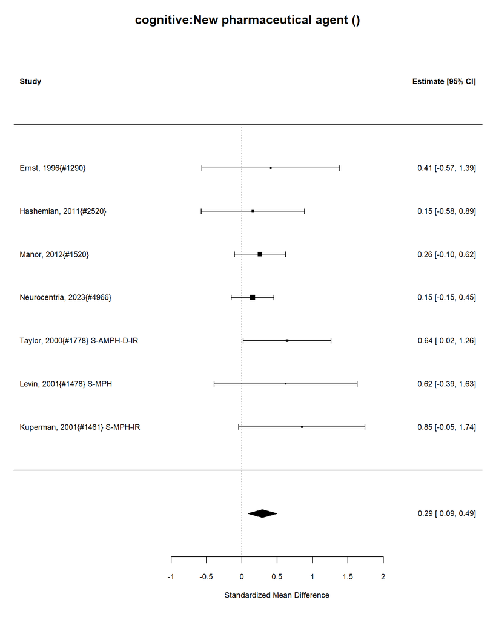

| estimate | conf.low | conf.high |
| --- | --- | --- |
| 0.29 | 0.09 | 0.49 |

Number of studies = 7

Intervention sample = 210

Control sample = 206

Total sample = 416.

I-squared = 0 %

Convert Effect Size to Real Units

Estimated effect in original units = 3.07.

##### Publication Bias Tests

###### Begg (non-parametric)

Rank Correlation Test for Funnel Plot Asymmetry Kendall’s tau = 0.4286, p = 0.2389

###### Egger (parametric)

Regression Test for Funnel Plot Asymmetry

Model: mixed-effects meta-regression model Predictor: standard error

Test for Funnel Plot Asymmetry: t = 2.3975, df = 5, p = 0.0618 Limit Estimate (as sei -> 0): b = -0.0106 (CI: -0.3696, 0.3485)

###### Trim and Fill

Estimate and Cis

|  | estimate | ci.lb | ci.ub |
| --- | --- | --- | --- |
| intrcpt | 0.2 | 0.02 | 0.38 |

### Meta-regression: stimulant vs non-stimulant

3 stimulant studies

0 nonstimulant studies

Not enough studies to compare stimulant and nonstimulant

### Meta-regression: AMPH vs MPH

### AMPH vs MPH meta-regression

1n AMPH studies

2 nMPH studies

Not enough studies to compare AMPH and MPH

## Meta-regression: Indirect comparison between combined vs(medication plus psychosocial) and medication

3 medication studies

0 combined studies

Not enough studies to compare medication and combined

## Meta-regression: Indirect comparison between combined vs(medication plus psychosocial) and psychosocial

0 psychosocial studies

0 combined studies

Not enough studies to compare psychosocial and combined

### Outcome: cognitive:categorical Intervention: New pharmaceutical agent

Outcome name: cognitive Analyzing 0 studies.

No data.

### Outcome: symptom:continuous Intervention: New pharmaceutical agent

| ID | measure | mean_ctrl_cont | SD_ctrl_cont | n_ctrl_cont | mean_int_cont | SD_int_cont | n_int_cont | yi | se | study.design |
| --- | --- | --- | --- | --- | --- | --- | --- | --- | --- | --- |
| Adler, 2021{#1052} | ADHD-RS-IV (ADHD Rating Scale, Version IV), change from baseline | 13.900 | 0.90000 | 211 | 16.5000 | 0.9000 | 206 | -2.8836643 | 0.1398726 | RCT |
| Amiri, 2012{#1079} | CAARS (Connors Adult ADHD Rating Scale), change from baseline | 13.550 | 12.83000 | 21 | 28.8000 | 12.2100 | 20 | -1.1933276 | 0.3390948 | RCT |
| Bain, 2012{#1094} | CAARS-INV (Conners’ Adult ADHD Rating Scale–Investigator Rated), change from baseline | -8.000 | 10.92000 | 53 | -7.5000 | 10.9200 | 53 | 0.0454564 | 0.1942823 | RCT |
| Biederman, 2006{#1118} | AISRS (ADHD Investigator Symptom Report Scale), change from baseline | -4.900 | 7.80000 | 18 | -5.5000 | 8.9000 | 18 | -0.0701056 | 0.3334357 | RCT |
| Biederman, 2019{#1117} | AISRS (Adult ADHD Investigator Symptom Rating Scale) change from baseline | -12.400 | 13.60000 | 109 | -11.6000 | 12.8000 | 34 | 0.0593078 | 0.1964647 | RCT |
| Bilodeau, 2014{#1125} | CAARS-S:L (Conners’ Adult ADHD Rating Scale) DSM-IV ADHD symptoms total | -0.336 | 11.93227 | 15 | -24.8645 | 23.2862 | 15 | -1.2898576 | 0.4013256 | RCT |
| Ernst, 1996{#1290} | Conners ATRS (ADHD Teacher Rating Scale, adapted for adults) | 9.000 | 3.40000 | 7 | 10.2000 | 3.5000 | 10 | 0.3291026 | 0.4960269 | RCT |
| Koblan, 2015{#1450} | ADHD RS-IV Total Score Change From Baseline | -9.700 | 11.50000 | 110 | -13.9000 | 12.4000 | 107 | -0.3501725 | 0.1368183 | RCT |
| Kuypers, 2026{#15827} | Adult ADHD investigator symptom rating scale | 29.000 | 8.47000 | 23 | 29.6000 | 8.2700 | 23 | 0.0704495 | 0.2949754 | RCT |
| Manor, 2012{#1520} | CAARS-INV (Conners Adult ADHD Rating Scale), Investigator-rated, change from baseline | -8.900 | 9.20000 | 60 | -12.5000 | 8.8000 | 60 | -0.3973532 | 0.1843670 | RCT |
| Mohammadzadeh, 2019{#1563} | CAARS-S:S (Conners’ Adult ADHD Rating Scale – Short Version), ADHD Index | 59.700 | 6.20000 | 20 | 36.7000 | 12.9000 | 20 | -2.2274084 | 0.4025132 | RCT |
| Mueller, 2025{#11349} | AISRS (Adult ADHD Investigator Symptom Rating Scale) | -8.900 | 8.06000 | 26 | -7.1000 | 8.0900 | 23 | 0.2193565 | 0.2871076 | RCT |
| Neurocentria, 2023{#4966} | AISRS (ADHD Investigator Symptom Rating Scale), change from baseline | -10.700 | 11.23000 | 89 | -12.0000 | 11.1600 | 81 | -0.1155862 | 0.1536910 | RCT |
| Otsuka Pharmaceutical, 2022{#4923} | AISRS (Adult ADHD Investigator Symptom Rating Scale), change from baseline | 6.980 | 11.76000 | 144 | 9.7300 | 11.8800 | 147 | -0.2320369 | 0.1176422 | RCT |
| Otsuka Pharmaceuticals, 2018{#10949} | AISRS (Adult ADHD Investigator Symptom Rating Scale), change from baseline | -8.070 | 11.16000 | 141 | -12.5000 | 11.7100 | 140 | -0.3862862 | 0.1204183 | RCT |
| Pfizer, 2016{#9229} | AISRS (Adult ADHD Investigator Symptom Rating Scale) | -6.789 | 8.57340 | 52 | -7.1960 | 8.7318 | 27 | -0.0467151 | 0.2372375 | RCT |
| Reimherr, 2005{#3108} | WRAADDS (Wender-Reimherr Adult Attention Deficit Disorder Scale) | 14.700 | 5.10000 | 18 | 12.9000 | 5.6000 | 29 | -0.3267408 | 0.3019504 | RCT |
| Reimherr, 2022{#1653} | CAARS (Conners’ Adult ADHD Rating Scales) | 22.800 | 11.00000 | 80 | 24.4000 | 10.7000 | 155 | 0.1476344 | 0.1378332 | RCT |
| Riahi, 2010{#1658} | CAARS-S (Conners’ Adult ADHD Rating Scale) total | 27.470 | 8.18000 | 17 | 21.8600 | 9.6300 | 22 | -0.6084623 | 0.3301887 | RCT |
| Spencer, 2018{#1740} | AISRS (Adult ADHD Investigator Symptom Report Scale) | 36.400 | 9.00000 | 16 | 38.5000 | 9.8000 | 15 | 0.2176902 | 0.3604594 | RCT |
| Surman, 2024{#4951} | AISRS (Adult ADHD Investigator Symptom Rating Scale), change from baseline | -2.100 | 1.13000 | 31 | -7.6000 | 1.1200 | 29 | -4.8245639 | 0.5105986 | RCT |
| Theravance Biopharma, 2011{#10952} | AISRS (Adult ADHD Investigator Symptom Rating Scale), change from baseline | -12.100 | 11.90000 | 97 | -12.2000 | 11.7000 | 99 | -0.0084422 | 0.1428652 | RCT |
| Weisler, 2014{#4890} | CAARS-Inv (Conners Adult ADHD Rating Scale), change from baseline | -9.900 | 12.24000 | 146 | -12.0000 | 12.1900 | 151 | -0.1714878 | 0.1162813 | RCT |
| Wilens, 1996{#1873} | ADHD-RS (ADHD Rating Scale) inattentiveness | 2.110 | 0.50000 | 22 | 1.0700 | 0.6000 | 19 | -1.8595988 | 0.3745106 | RCT |
| Wilens, 2001{#1882} | ADHD-RS-IV (ADHD Rating Scale) | 23.800 | 11.80000 | 19 | 19.2000 | 11.0000 | 21 | -0.3959709 | 0.3197038 | RCT |
| Wilens, 2005{#1878} | CAARS-SR (Conners’ Adult ADHD Rating Scale–Self-Report), change from baseline | -2.800 | 12.50000 | 81 | -6.9000 | 14.3000 | 81 | -0.3038487 | 0.1580389 | RCT |
| Wilens, 2008{#3473} | ADHD-RS (ADHD-rating scale) Investigator-rated | 6.400 | 1.30000 | 60 | 7.8000 | 1.3000 | 61 | 1.0701191 | 0.1944020 | RCT |
| Butterfield, 2016{#1177} GXR | ADHD-RS (Attention Deficit Hyperactivity Disorder Rating Scale) | 24.310 | 10.94000 | 13 | 24.0800 | 9.1200 | 13 | -0.0221149 | 0.3922443 | RCT |
| Arnold, 2014{#1084} Modafinil | AISRS (Adult ADHD Investigator Symptom Rating Scale), change from baseline | -12.100 | 11.91000 | 51 | -13.2000 | 11.2500 | 23 | -0.0929362 | 0.2512856 | RCT |
| Faraone, 2021{#1300} S-AMPH | AISRS (Adult ADHD Investigator Symptom Rating Scale), change from baseline | -11.200 | 13.28000 | 106 | -18.5000 | 13.4500 | 107 | -0.5442312 | 0.1395530 | RCT |
| Taylor, 2000{#1778} S-AMPH-D-IR | DSM-IV ADHD Behavior Checklist for Adults | 28.800 | 10.00000 | 21 | 18.3000 | 11.2000 | 21 | -0.9703032 | 0.3262611 | RCT |
| Kuperman, 2001{#1461} S-MPH-IR | ADHD-RS (ADHD Symptoms Checklist Severity Scale) change from baseline | 12.400 | 10.60000 | 8 | 13.7000 | 6.9000 | 11 | -0.1440740 | 0.4652476 | RCT |
| Hamedi, 2014{#1367} buproprion | CAARS (Conners’ Adult ADHD Rating Scales) | 34.430 | 10.09000 | 21 | 23.7100 | 15.3400 | 21 | -0.8100910 | 0.3210149 | RCT |

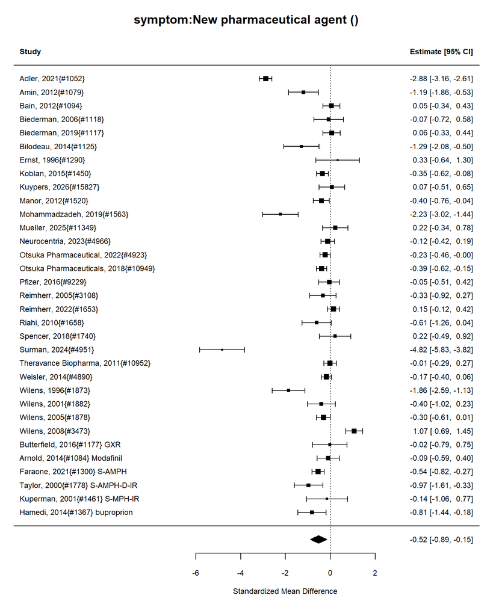

| estimate | conf.low | conf.high |
| --- | --- | --- |
| -0.52 | -0.89 | -0.15 |

Number of studies = 33

Intervention sample = 1862

Control sample = 1906

Total sample = 3768.

I-squared = 96 %

Convert Effect Size to Real Units

Estimated effect in original units = -4.74.

##### Publication Bias Tests

###### Begg (non-parametric)

Rank Correlation Test for Funnel Plot Asymmetry Kendall’s tau = -0.3182, p = 0.0089

###### Egger (parametric)

Regression Test for Funnel Plot Asymmetry

Model: mixed-effects meta-regression model Predictor: standard error

Test for Funnel Plot Asymmetry: t = -1.9650, df = 31, p = 0.0584 Limit Estimate (as sei -> 0): b = 0.2620 (CI: -0.6248, 1.1488)

###### Trim and Fill

Estimate and Cis

|  | estimate | ci.lb | ci.ub |
| --- | --- | --- | --- |
| intrcpt | -0.52 | -0.89 | -0.15 |

### Meta-regression: stimulant vs non-stimulant

0 nonstimulant studies

Not enough studies to compare stimulant and nonstimulant

### Meta-regression: AMPH vs MPH

### AMPH vs MPH meta-regression

1 nMPH studies

Not enough studies to compare AMPH and MPH

## Meta-regression: Indirect comparison between combined vs(medication plus psychosocial) and medication

2 medication studies

0 combined studies

Not enough studies to compare medication and combined

## Meta-regression: Indirect comparison between combined vs(medication plus psychosocial) and psychosocial

0 psychosocial studies

0 combined studies

Not enough studies to compare psychosocial and combined

### Outcome: symptom:categorical Intervention: New pharmaceutical agent

Outcome name: symptom Analyzing 13 studies.

Analyzing 13 studies.

### Control Types

| control | n |
| --- | --- |
| Placebo | 13 |

| ID | measure | yi | se | study.design |
| --- | --- | --- | --- | --- |
| Biederman, 2006{#1118} | AISRS, number with ≥ 30 % reduction | 0.00 | 0.62 | RCT |
| Manor, 2012{#1520} | CAARS-INV (Conners Adult ADHD Rating Scale), Investigator-rated, numberof patients responded (improved at least 25%) | -0.49 | 0.22 | RCT |
| Otsuka Pharmaceuticals, 2018{#10949} | AISRS, number who improved at least 30% | 0.39 | 0.14 | RCT |
| Pfizer, 2016{#9229} | AISRS Responders (≥30% reduction) | -0.04 | 0.36 | RCT |
| Reimherr, 2005{#3108} | WRAADDS (Wender-Reimherr Adult Attention Deficit Disorder Scale), number with at least 50% reduction | 1.23 | 0.71 | RCT |
| Surman, 2024{#4951} | Number of patients with ≥25% improvement in AISRS score and CGI much or very much improved | -2.15 | 1.03 | RCT |
| Theravance Biopharma, 2011{#10952} | AISRS (Adult ADHD Investigator Symptom Rating Scale), number responding, defined as ≥30% reduction from baseline | 0.12 | 0.16 | RCT |
| Wigal, 2018{#1867} | ADHD-RS, percent with reduction of at least 30% | -1.18 | 0.31 | RCT |
| Wilens, 2001{#1882} | DSM-IV ADHD symptom checklist, at least 30% improvement | -0.73 | 0.32 | RCT |
| Wilens, 2005{#1878} | ADHD-RS, at least a 30% reduction | -0.54 | 0.20 | RCT |
| Wilens, 2008{#3473} | ADHD RS, number who reduced by 30% | -0.21 | 0.28 | RCT |
| Faraone, 2021{#1300} S-AMPH | AISRS (Adult ADHD Investigator Symptom Rating Scale), total score, number improving at least 30% | -0.36 | 0.11 | RCT |
| Levin, 2006{#1483} S-MPH-ER | AARS (ADHD Rating Scale), number of participants who decreased score by at least 30% | 0.28 | 0.31 | RCT |

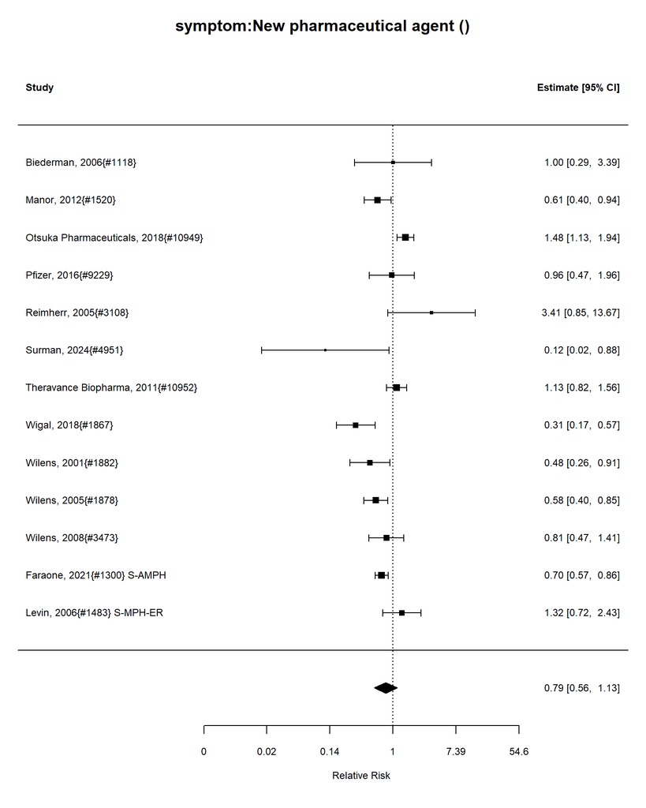

Number of studies = 13  
Intervention sample = 725  
Control sample = 736  
Total sample = 1461

### Relative Risk Estimate

|  | estimate | se | tval | df | pval | ci.lb | ci.ub |
| --- | --- | --- | --- | --- | --- | --- | --- |
| intrcpt | 0.7945336 | 1.173511 | 0.2441433 | 162754.8 | 1.197217 | 0.5543273 | 1.138828 |

I-squared = 78 %

##### Publication Bias Tests

###### Begg (non-parametric)

```
Rank Correlation Test for Funnel Plot Asymmetry

Kendall's tau = 0.0256, p = 0.9524
```

###### Egger (parametric)

```
Regression Test for Funnel Plot Asymmetry

Model:     mixed-effects meta-regression model
Predictor: standard error

Test for Funnel Plot Asymmetry: t = -0.3917, df = 11, p = 0.7028
Limit Estimate (as sei -> 0):   b = -0.1249 (CI: -0.8322, 0.5825)
```

###### Trim and Fill

Estimate and CIs

|  | estimate | ci.lb | ci.ub |
| --- | --- | --- | --- |
| intrcpt | 0.79 | 0.56 | 1.13 |

TrimFill Relative Risk Estimate: 1

###### int_stimulant vs int_nonstimulant meta-regression

### Meta-regression: stimulant vs non-stimulant

1 stimulant studies

0 nonstimulant studies

Not enough studies to compare stimulant and nonstimulant

### Meta-regression: AMPH vs MPH

### AMPH vs MPH meta-regression

0n AMPH studies

1 nMPH studies

Not enough studies to compare AMPH and MPH

## Meta-regression: Indirect comparison between combined vs(medication plus psychosocial) and medication

1 medication studies

0 combined studies

Not enough studies to compare medication and combined

## Meta-regression: Indirect comparison between combined vs(medication plus psychosocial) and psychosocial

0 psychosocial studies

0 combined studies

Not enough studies to compare psychosocial and combined

### Outcome: substance_use:continuous Intervention: New pharmaceutical agent

No data #1.

### Outcome: substance_use:categorical Intervention: New pharmaceutical agent

Outcome name: substance_use Analyzing 1 studies.

Analyzing 1 studies.

### Control Types

| control | n |
| --- | --- |
| Placebo | 1 |

| ID | measure | yi | se | study.design |
| --- | --- | --- | --- | --- |
| Levin, 2006{#1483} S-MPH-ER | Number of participants with 2 weeks abstinence from any illicit drug | 0.48 | 0.69 | RCT |

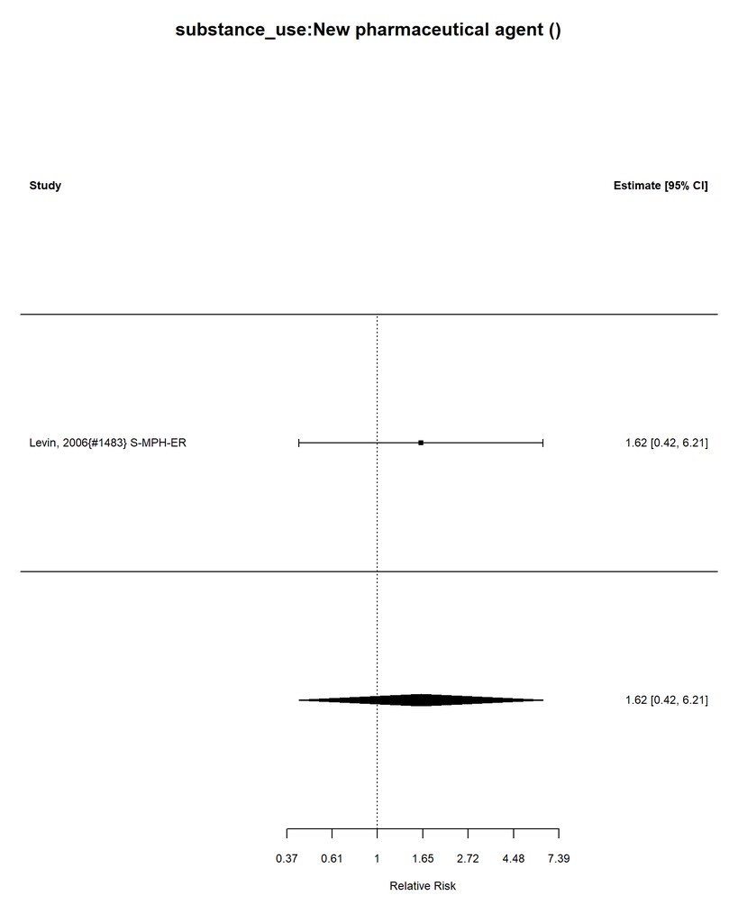

Number of studies = 1  
Intervention sample = 32  
Control sample = 33  
Total sample = 65

### Relative Risk Estimate

|  | estimate | se | zval | pval | ci.lb | ci.ub |
| --- | --- | --- | --- | --- | --- | --- |
| intrcpt | 1.616074 | 1.993715 | 2.013753 | 1.616074 | 0.4189515 | 6.233887 |

I-squared = 0 %

### Outcome: relationship:continuous Intervention: New pharmaceutical agent

No data #1.

### Outcome: relationship:categorical Intervention: New pharmaceutical agent

Outcome name: relationship Analyzing 0 studies.

No data.

### Outcome: BP:continuous Intervention: New pharmaceutical agent

| ID | measure | mean_ctrl_cont | SD_ctrl_cont | n_ctrl_cont | mean_int_cont | SD_int_cont | n_int_cont | yi | se | study.design |
| --- | --- | --- | --- | --- | --- | --- | --- | --- | --- | --- |
| Ernst, 1996{#1290} | Systolic blood pressure, sitting | 124.50 | 8.30 | 7 | 121.50 | 10.20 | 10 | -0.3001359 | 0.4954862 | RCT |
| Mueller, 2025{#11349} | Blood pressure millimeters of mercury (mm Hg) | 120.60 | 11.30 | 25 | 121.70 | 12.40 | 24 | 0.0913283 | 0.2859227 | RCT |
| Spencer, 2018{#1740} | Systolic blood pressure | 114.80 | 5.60 | 12 | 118.80 | 12.70 | 12 | 0.3934781 | 0.4121798 | RCT |
| Iwanami, 2020{#1408} GXR | Systolic blood pressure change | -0.41 | 10.59 | 101 | 0.76 | 11.48 | 101 | 0.1055423 | 0.1408174 | RCT |

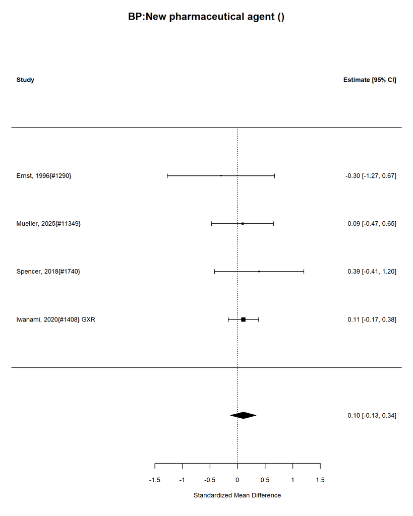

| estimate | conf.low | conf.high |
| --- | --- | --- |
| 0.1 | -0.13 | 0.34 |

Number of studies = 4

Intervention sample = 147

Control sample = 145

Total sample = 292.

I-squared = 0 %

Convert Effect Size to Real Units

Estimated effect in original units = 0.93.

##### Publication Bias Tests

###### Begg (non-parametric)

Rank Correlation Test for Funnel Plot Asymmetry Kendall’s tau = -0.3333, p = 0.7500

###### Egger (parametric)

Regression Test for Funnel Plot Asymmetry

Model: mixed-effects meta-regression model Predictor: standard error

Test for Funnel Plot Asymmetry: t = -0.2012, df = 2, p = 0.8591 Limit Estimate (as sei -> 0): b = 0.1372 (CI: -0.6729, 0.9472)

###### Trim and Fill

Estimate and Cis

|  | estimate | ci.lb | ci.ub |
| --- | --- | --- | --- |
| intrcpt | 0.13 | -0.1 | 0.35 |

### Meta-regression: stimulant vs non-stimulant

0 stimulant studies

0 nonstimulant studies

Not enough studies to compare stimulant and nonstimulant

### Meta-regression: AMPH vs MPH

### AMPH vs MPH meta-regression

0n AMPH studies

0 nMPH studies

Not enough studies to compare AMPH and MPH

## Meta-regression: Indirect comparison between combined vs(medication plus psychosocial) and medication

0 medication studies

0 combined studies

Not enough studies to compare medication and combined

## Meta-regression: Indirect comparison between combined vs(medication plus psychosocial) and psychosocial

0 psychosocial studies

0 combined studies

Not enough studies to compare psychosocial and combined

### Outcome: BP:categorical Intervention: New pharmaceutical agent

Outcome name: BP Analyzing 3 studies.

Analyzing 3 studies.

### Control Types

| control | n |
| --- | --- |
| Placebo | 3 |

| ID | measure | yi | se | study.design |
| --- | --- | --- | --- | --- |
| Biederman, 2019{#1117} | Increased blood pressure | 1.23 | 1.50 | RCT |
| Surman, 2024{#4951} | Blood pressure, patients with 2 readings > 140/90 mm Hg | -0.35 | 0.72 | RCT |
| Iwanami, 2020{#1408} GXR | Decreased blood pressure | 2.34 | 0.73 | RCT |

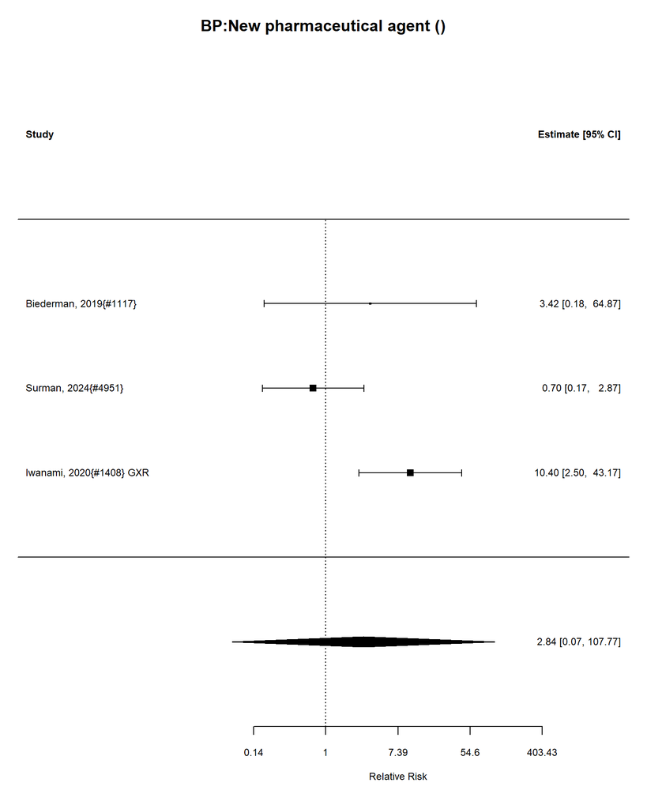

Number of studies = 3  
Intervention sample = 174  
Control sample = 222  
Total sample = 396

### Relative Risk Estimate

|  | estimate | se | tval | df | pval | ci.lb | ci.ub |
| --- | --- | --- | --- | --- | --- | --- | --- |
| intrcpt | 2.829217 | 2.339647 | 3.421229 | 7.389056 | 1.404948 | 0.07502 | 107.7701 |

I-squared = 68 %

##### Publication Bias Tests

###### Begg (non-parametric)

```
Rank Correlation Test for Funnel Plot Asymmetry

Kendall's tau = 0.3333, p = 1.0000
```

###### Egger (parametric)

```
Regression Test for Funnel Plot Asymmetry

Model:     mixed-effects meta-regression model
Predictor: standard error

Test for Funnel Plot Asymmetry: t = 0.0992, df = 1, p = 0.9370
Limit Estimate (as sei -> 0):   b = 0.7382 (CI: -42.0896, 43.5659)
```

###### Trim and Fill

Estimate and CIs

|  | estimate | ci.lb | ci.ub |
| --- | --- | --- | --- |
| intrcpt | 2.84 | 0.07 | 107.77 |

TrimFill Relative Risk Estimate: 3

###### int_stimulant vs int_nonstimulant meta-regression

### Meta-regression: stimulant vs non-stimulant

0 stimulant studies

0 nonstimulant studies

Not enough studies to compare stimulant and nonstimulant

### Meta-regression: AMPH vs MPH

### AMPH vs MPH meta-regression

0n AMPH studies

0 nMPH studies

Not enough studies to compare AMPH and MPH

## Meta-regression: Indirect comparison between combined vs(medication plus psychosocial) and medication

0 medication studies

0 combined studies

Not enough studies to compare medication and combined

## Meta-regression: Indirect comparison between combined vs(medication plus psychosocial) and psychosocial

0 psychosocial studies

0 combined studies

Not enough studies to compare psychosocial and combined

### Outcome: sleep_disturbance:continuous Intervention: New pharmaceutical agent

| ID | measure | mean_ctrl_cont | SD_ctrl_cont | n_ctrl_cont | mean_int_cont | SD_int_cont | n_int_cont | yi | se | study.design |
| --- | --- | --- | --- | --- | --- | --- | --- | --- | --- | --- |
| Reimherr, 2022{#1653} | ISI (Insomnia Severity Index), change | -4.86 | 0.60 | 69 | -4.58 | 0.44 | 147 | 0.5620112 | 0.1484137 | RCT |
| Butterfield, 2016{#1177} GXR | PSQI (Pittsburgh Sleep Quality Index) | 6.00 | 3.22 | 13 | 6.69 | 5.63 | 13 | 0.1456939 | 0.3927523 | RCT |

[figure not shown]

| estimate | conf.low | conf.high |
| --- | --- | --- |
| 0.51 | -1.24 | 2.26 |

Number of studies = 2

Intervention sample = 160

Control sample = 82

Total sample = 242.

I-squared = 0 %

Convert Effect Size to Real Units

Estimated effect in original units = 0.97.

### Outcome: sleep_disturbance:categorical Intervention: New pharmaceutical agent

Outcome name: sleep_disturbance Analyzing 4 studies.

Analyzing 4 studies.

### Control Types

| control | n |
| --- | --- |
| Placebo | 4 |

| ID | measure | yi | se | study.design |
| --- | --- | --- | --- | --- |
| Jucaite, 2014{#1431} | Insomnia | 1.33 | 1.14 | RCT |
| Radin, 2025a{#13645} | Insomnia | 0.92 | 0.80 | RCT |
| Wilens, 2005{#1878} | Insomnia | 0.51 | 0.49 | RCT |
| Faraone, 2021{#1300} S-AMPH | Number of participants experiencing insomnia | 0.91 | 0.58 | RCT |

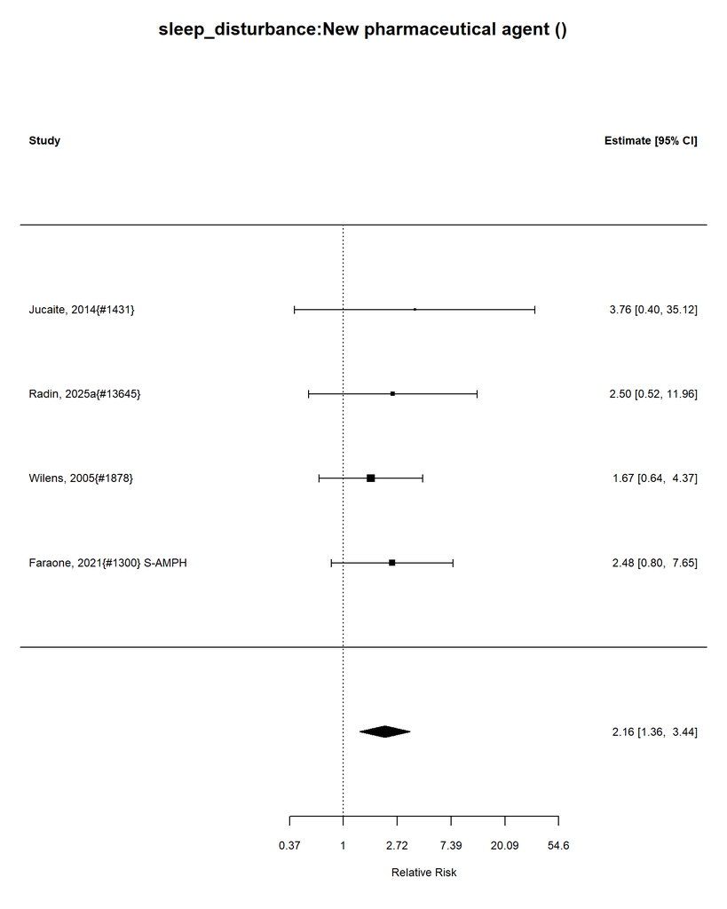

Number of studies = 4  
Intervention sample = 271  
Control sample = 283  
Total sample = 554

### Relative Risk Estimate

|  | estimate | se | tval | df | pval | ci.lb | ci.ub |
| --- | --- | --- | --- | --- | --- | --- | --- |
| intrcpt | 2.159766 | 1.161834 | 196.3699 | 20.08554 | 1.01005 | 1.363425 | 3.421229 |

I-squared = 0 %

##### Publication Bias Tests

###### Begg (non-parametric)

```
Rank Correlation Test for Funnel Plot Asymmetry

Kendall's tau = 0.6667, p = 0.3333
```

###### Egger (parametric)

```
Regression Test for Funnel Plot Asymmetry

Model:     mixed-effects meta-regression model
Predictor: standard error

Test for Funnel Plot Asymmetry: t = 2.3088, df = 2, p = 0.1473
Limit Estimate (as sei -> 0):   b = 0.0534 (CI: -1.3411, 1.4479)
```

###### Trim and Fill

Estimate and CIs

|  | estimate | ci.lb | ci.ub |
| --- | --- | --- | --- |
| intrcpt | 2.06 | 1.12 | 3.79 |

TrimFill Relative Risk Estimate: 2

###### int_stimulant vs int_nonstimulant meta-regression

### Meta-regression: stimulant vs non-stimulant

0 stimulant studies

0 nonstimulant studies

Not enough studies to compare stimulant and nonstimulant

### Meta-regression: AMPH vs MPH

### AMPH vs MPH meta-regression

0n AMPH studies

0 nMPH studies

Not enough studies to compare AMPH and MPH

## Meta-regression: Indirect comparison between combined vs(medication plus psychosocial) and medication

0 medication studies

0 combined studies

Not enough studies to compare medication and combined

## Meta-regression: Indirect comparison between combined vs(medication plus psychosocial) and psychosocial

0 psychosocial studies

0 combined studies

Not enough studies to compare psychosocial and combined

### Outcome: AEs:continuous Intervention: New pharmaceutical agent

No data #1.

### Outcome: AEs:categorical Intervention: New pharmaceutical agent

Outcome name: AEs Analyzing 25 studies.

Analyzing 25 studies.

### Control Types

| control | n |
| --- | --- |
| Other | 1 |
| Placebo | 24 |

| ID | measure | yi | se | study.design |
| --- | --- | --- | --- | --- |
| Adler, 2021{#1052} | Number with any adverse event | 0.28 | 0.06 | RCT |
| Bain, 2012{#1094} | Number of participants with adverse events | -0.03 | 0.15 | RCT |
| Biederman, 2017{#1116} | Participants with adverse events | -0.11 | 0.15 | RCT |
| Biederman, 2019{#1117} | Number of participants with adverse events | 0.23 | 0.12 | RCT |
| Bilodeau, 2014{#1125} | Number of participants with adverse events | 1.10 | 0.45 | RCT |
| Jucaite, 2014{#1431} | Participants with at least one adverse event | 0.47 | 0.19 | RCT |
| Koblan, 2015{#1450} | Number of Patients with Treatment-Emergent Adverse Events | 0.31 | 0.09 | RCT |
| Manor, 2012{#1520} | Number of participants with any adverse event | 0.09 | 0.11 | RCT |
| Mueller, 2025{#11349} | Number of participants with adverse events outcome | 0.27 | 0.29 | RCT |
| Neurocentria, 2023{#4966} | At least one treatment-emergent adverse event. | 0.21 | 0.18 | RCT |
| Otsuka Pharmaceutical, 2022{#4923} | Number of participants with adverse events | 0.19 | 0.30 | RCT |
| Otsuka Pharmaceuticals, 2018{#10949} | Number of participants with adverse events | 0.18 | 0.09 | RCT |
| Pfizer, 2016{#9229} | Number of participants with adverse events | 0.16 | 0.30 | RCT |
| Radin, 2025a{#13645} | Any treatment-emergent adverse event | 0.29 | 0.19 | RCT |
| Spencer, 2018{#1740} | Number of participants with adverse events | 0.17 | 0.11 | RCT |
| Surman, 2024{#4951} | Number of participants with adverse events | 0.07 | 0.07 | RCT |
| Theravance Biopharma, 2011{#10952} | Number of participants with at least one adverse event | 0.15 | 0.08 | RCT |
| Weisler, 2014{#4890} | Number of participants with adverse events | 0.23 | 0.17 | RCT |
| Wilens, 1996{#1873} | Participants with at least one adverse event | 0.90 | 0.29 | RCT |
| Wilens, 2001{#1882} | Number of participants with adverse events outcome | 0.14 | 0.25 | RCT |
| Wilens, 2005{#1878} | Number with any adverse event | 0.54 | 0.10 | RCT |
| Iwanami, 2020{#1408} GXR | Any treatment-emergent adverse event | 0.27 | 0.09 | RCT |
| Arnold, 2014{#1084} Modafinil | Number of participants with at least one treatment-emergent adverse event (TEAE) | 0.01 | 0.08 | RCT |
| Faraone, 2021{#1300} S-AMPH | Number of participants experiencing any treatment-emergent adverse event | 1.05 | 0.23 | RCT |
| Kuperman, 2001{#1461} S-MPH-IR | Number of participants with at least one adverse event | 0.12 | 0.26 | RCT |

[figure not shown]

Number of studies = 25  
Intervention sample = 1730  
Control sample = 1863  
Total sample = 3593

### Relative Risk Estimate

|  | estimate | se | tval | df | pval | ci.lb | ci.ub |
| --- | --- | --- | --- | --- | --- | --- | --- |
| intrcpt | 1.2586 | 1.051271 | 141.175 | 26489122130 | 1 | 1.138828 | 1.390968 |

I-squared = 59 %

##### Publication Bias Tests

###### Begg (non-parametric)

```
Rank Correlation Test for Funnel Plot Asymmetry

Kendall's tau = 0.2133, p = 0.1424
```

###### Egger (parametric)

```
Regression Test for Funnel Plot Asymmetry

Model:     mixed-effects meta-regression model
Predictor: standard error

Test for Funnel Plot Asymmetry: t = 1.9807, df = 23, p = 0.0597
Limit Estimate (as sei -> 0):   b = 0.0673 (CI: -0.1246, 0.2592)
```

###### Trim and Fill

Estimate and CIs

|  | estimate | ci.lb | ci.ub |
| --- | --- | --- | --- |
| intrcpt | 1.26 | 1.14 | 1.39 |

TrimFill Relative Risk Estimate: 1

###### int_stimulant vs int_nonstimulant meta-regression

### Meta-regression: stimulant vs non-stimulant

1 stimulant studies

0 nonstimulant studies

Not enough studies to compare stimulant and nonstimulant

### Meta-regression: AMPH vs MPH

### AMPH vs MPH meta-regression

0n AMPH studies

1 nMPH studies

Not enough studies to compare AMPH and MPH

## Meta-regression: Indirect comparison between combined vs(medication plus psychosocial) and medication

1 medication studies

0 combined studies

Not enough studies to compare medication and combined

## Meta-regression: Indirect comparison between combined vs(medication plus psychosocial) and psychosocial

0 psychosocial studies

0 combined studies

Not enough studies to compare psychosocial and combined

### Outcome: mortality:continuous Intervention: New pharmaceutical agent

No data #1.

### Outcome: mortality:categorical Intervention: New pharmaceutical agent

Outcome name: mortality Analyzing 14 studies.

Analyzing 14 studies.

### Control Types

| control | n |
| --- | --- |
| Placebo | 14 |

| ID | measure | yi | se | study.design |
| --- | --- | --- | --- | --- |
| Adler, 2021{#1052} | Number of deaths | -0.06 | 2.00 | RCT |
| Biederman, 2019{#1117} | Number of deaths | -0.41 | 1.99 | RCT |
| Neurocentria, 2023{#4966} | Number of participants who died from any cause | -0.09 | 1.99 | RCT |
| Otsuka Pharmaceutical, 2022{#4923} | All-cause mortality | 0.01 | 2.00 | RCT |
| Otsuka Pharmaceuticals, 2018{#10949} | All-cause mortality | 0.01 | 2.00 | RCT |
| Radin, 2025a{#13645} | Deaths | -0.12 | 1.97 | RCT |
| Reimherr, 2022{#1653} | All-cause mortality | 0.66 | 2.00 | RCT |
| Surman, 2024{#4951} | All-cause mortality | -0.06 | 1.98 | RCT |
| Theravance Biopharma, 2011{#10952} | All-cause mortality | 0.01 | 1.99 | RCT |
| Wigal, 2018{#1867} | Number of deaths | 0.02 | 1.99 | RCT |
| Butterfield, 2016{#1177} GXR | Death | 0.00 | 1.96 | RCT |
| Iwanami, 2020{#1408} GXR | Deaths | 0.01 | 2.00 | RCT |
| Arnold, 2014{#1084} Modafinil | Number of deaths | -0.55 | 1.99 | RCT |
| Faraone, 2021{#1300} S-AMPH | All-cause mortality | 0.01 | 2.00 | RCT |

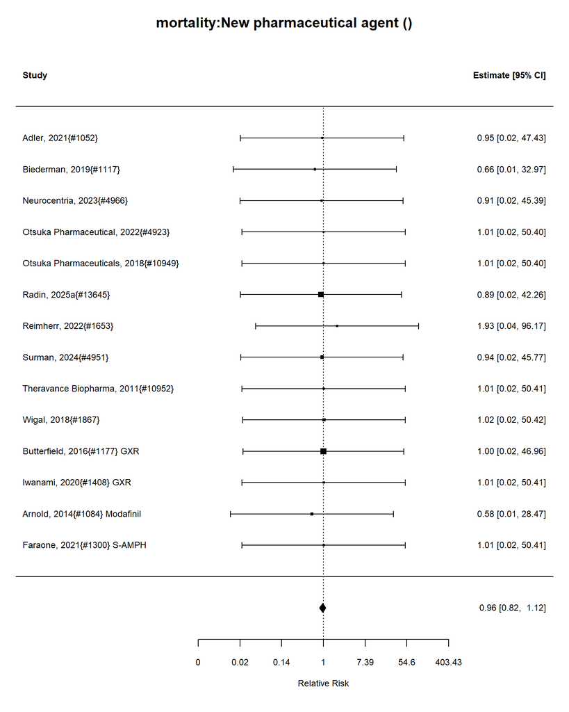

Number of studies = 14  
Intervention sample = 1242  
Control sample = 1247  
Total sample = 2489

### Relative Risk Estimate

|  | estimate | se | tval | df | pval | ci.lb | ci.ub |
| --- | --- | --- | --- | --- | --- | --- | --- |
| intrcpt | 0.9607894 | 1.072508 | 0.5598984 | 442413.4 | 1.768267 | 0.8269591 | 1.116278 |

I-squared = 0 %

##### Publication Bias Tests

###### Begg (non-parametric)

```
Rank Correlation Test for Funnel Plot Asymmetry

Kendall's tau = 0.1429, p = 0.5183
```

###### Egger (parametric)

```
Regression Test for Funnel Plot Asymmetry

Model:     mixed-effects meta-regression model
Predictor: standard error

Test for Funnel Plot Asymmetry: t =  0.3664, df = 12, p = 0.7205
Limit Estimate (as sei -> 0):   b = -5.3512 (CI: -36.9294, 26.2271)
```

###### Trim and Fill

Estimate and CIs

|  | estimate | ci.lb | ci.ub |
| --- | --- | --- | --- |
| intrcpt | 0.88 | 0.35 | 2.21 |

TrimFill Relative Risk Estimate: 1

###### int_stimulant vs int_nonstimulant meta-regression

### Meta-regression: stimulant vs non-stimulant

0 stimulant studies

0 nonstimulant studies

Not enough studies to compare stimulant and nonstimulant

### Meta-regression: AMPH vs MPH

### AMPH vs MPH meta-regression

0n AMPH studies

0 nMPH studies

Not enough studies to compare AMPH and MPH

## Meta-regression: Indirect comparison between combined vs(medication plus psychosocial) and medication

0 medication studies

0 combined studies

Not enough studies to compare medication and combined

## Meta-regression: Indirect comparison between combined vs(medication plus psychosocial) and psychosocial

0 psychosocial studies

0 combined studies

Not enough studies to compare psychosocial and combined

### Outcome: behavior:continuous Intervention: New pharmaceutical agent

No data #1.

### Outcome: behavior:categorical Intervention: New pharmaceutical agent

Outcome name: behavior Analyzing 0 studies.

No data.

### Outcome: appetite:continuous Intervention: New pharmaceutical agent

No data #1.

### Outcome: appetite:categorical Intervention: New pharmaceutical agent

Outcome name: appetite Analyzing 13 studies.

Analyzing 13 studies.

### Control Types

| control | n |
| --- | --- |
| Placebo | 13 |

| ID | measure | yi | se | study.design |
| --- | --- | --- | --- | --- |
| Adler, 2021{#1052} | Participants who experienced decreased appetite | -1.53 | 0.32 | RCT |
| Biederman, 2017{#1116} | Appetite decrease | -1.76 | 1.02 | RCT |
| Jucaite, 2014{#1431} | Decreased adverse event | -2.17 | 1.50 | RCT |
| Koblan, 2015{#1450} | Decreased appetite | -2.12 | 0.60 | RCT |
| Manor, 2012{#1520} | Decreased appetite | -0.92 | 1.54 | RCT |
| Otsuka Pharmaceutical, 2022{#4923} | Decreased appetite | -1.70 | 0.76 | RCT |
| Pfizer, 2016{#9229} | Decreased appetite | -1.92 | 1.62 | RCT |
| Surman, 2024{#4951} | Decreased appetite | -0.98 | 0.80 | RCT |
| Theravance Biopharma, 2011{#10952} | Decreased appetite | -1.17 | 0.55 | RCT |
| Wigal, 2018{#1867} | Decreased appetite | -1.08 | 1.13 | RCT |
| Faraone, 2021{#1300} S-AMPH | Decreased appetite | -0.78 | 0.52 | RCT |
| Taylor, 2000{#1778} S-AMPH-D-IR | Appetite suppression | -2.20 | 1.46 | RCT |
| Kuperman, 2001{#1461} S-MPH-IR | Appetite suppression | -1.95 | 1.46 | RCT |

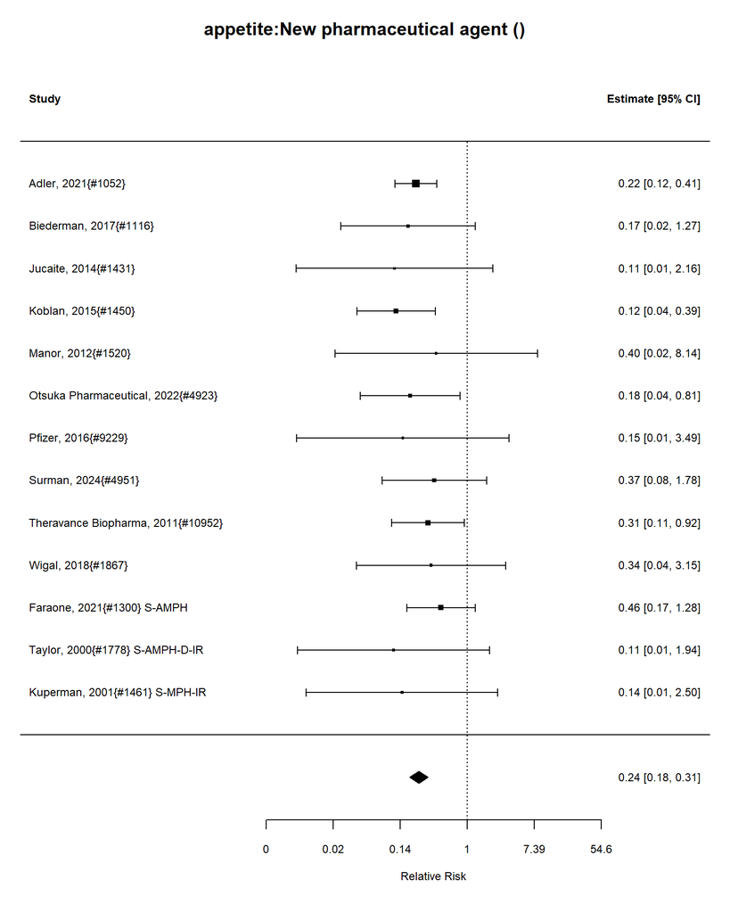

Number of studies = 13  
Intervention sample = 985  
Control sample = 983  
Total sample = 1968

### Relative Risk Estimate

|  | estimate | se | tval | df | pval | ci.lb | ci.ub |
| --- | --- | --- | --- | --- | --- | --- | --- |
| intrcpt | 0.2369278 | 1.127497 | 6.5e-06 | 162754.8 | 1 | 0.1808658 | 0.3072787 |

I-squared = 0 %

##### Publication Bias Tests

###### Begg (non-parametric)

```
Rank Correlation Test for Funnel Plot Asymmetry

Kendall's tau = -0.1282, p = 0.5900
```

###### Egger (parametric)

```
Regression Test for Funnel Plot Asymmetry

Model:     mixed-effects meta-regression model
Predictor: standard error

Test for Funnel Plot Asymmetry: t = -0.5900, df = 11, p = 0.5671
Limit Estimate (as sei -> 0):   b = -1.3133 (CI: -1.8728, -0.7538)
```

###### Trim and Fill

Estimate and CIs

|  | estimate | ci.lb | ci.ub |
| --- | --- | --- | --- |
| intrcpt | 0.27 | 0.19 | 0.38 |

TrimFill Relative Risk Estimate: 0

###### int_stimulant vs int_nonstimulant meta-regression

### Meta-regression: stimulant vs non-stimulant

2 stimulant studies

0 nonstimulant studies

Not enough studies to compare stimulant and nonstimulant

### Meta-regression: AMPH vs MPH

### AMPH vs MPH meta-regression

1n AMPH studies

1 nMPH studies

Not enough studies to compare AMPH and MPH

## Meta-regression: Indirect comparison between combined vs(medication plus psychosocial) and medication

2 medication studies

0 combined studies

Not enough studies to compare medication and combined

## Meta-regression: Indirect comparison between combined vs(medication plus psychosocial) and psychosocial

0 psychosocial studies

0 combined studies

Not enough studies to compare psychosocial and combined

### Outcome: mood:continuous Intervention: New pharmaceutical agent

No data #1.

### Outcome: mood:categorical Intervention: New pharmaceutical agent

Outcome name: mood Analyzing 8 studies.

Analyzing 8 studies.

### Control Types

| control | n |
| --- | --- |
| Placebo | 8 |

| ID | measure | yi | se | study.design |
| --- | --- | --- | --- | --- |
| Adler, 2021{#1052} | Irritability | -0.11 | 0.31 | RCT |
| Biederman, 2017{#1116} | Irritable | -0.15 | 0.92 | RCT |
| Pfizer, 2016{#9229} | Irritability | -0.44 | 0.88 | RCT |
| Riahi, 2010{#1658} | Irritability | -0.03 | 0.49 | RCT |
| Wilens, 2005{#1878} | Irritability | -0.92 | 0.82 | RCT |
| Wilens, 2008{#3473} | Irritability | -1.10 | 0.80 | RCT |
| Butterfield, 2016{#1177} GXR | Irritability | 0.41 | 0.82 | RCT |
| Taylor, 2000{#1778} S-AMPH-D-IR | Irritability | -0.41 | 0.86 | RCT |

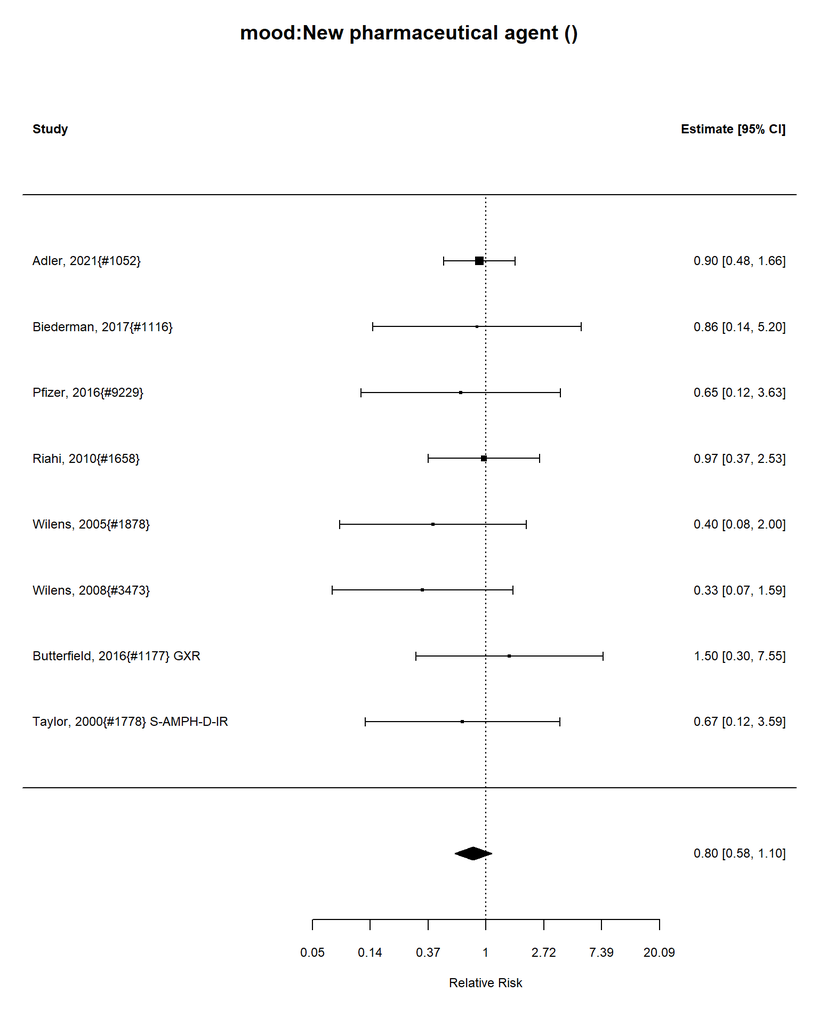

Number of studies = 8  
Intervention sample = 445  
Control sample = 486  
Total sample = 931

### Relative Risk Estimate

|  | estimate | se | tval | df | pval | ci.lb | ci.ub |
| --- | --- | --- | --- | --- | --- | --- | --- |
| intrcpt | 0.8025188 | 1.138828 | 0.1920499 | 1096.633 | 1.150274 | 0.5827483 | 1.105171 |

I-squared = 0 %

##### Publication Bias Tests

###### Begg (non-parametric)

```
Rank Correlation Test for Funnel Plot Asymmetry

Kendall's tau = -0.0714, p = 0.9049
```

###### Egger (parametric)

```
Regression Test for Funnel Plot Asymmetry

Model:     mixed-effects meta-regression model
Predictor: standard error

Test for Funnel Plot Asymmetry: t = -1.1288, df = 6, p = 0.3021
Limit Estimate (as sei -> 0):   b =  0.1128 (CI: -0.6836, 0.9091)
```

###### Trim and Fill

Estimate and CIs

|  | estimate | ci.lb | ci.ub |
| --- | --- | --- | --- |
| intrcpt | 0.9 | 0.61 | 1.33 |

TrimFill Relative Risk Estimate: 1

###### int_stimulant vs int_nonstimulant meta-regression

### Meta-regression: stimulant vs non-stimulant

1 stimulant studies

0 nonstimulant studies

Not enough studies to compare stimulant and nonstimulant

### Meta-regression: AMPH vs MPH

### AMPH vs MPH meta-regression

1n AMPH studies

0 nMPH studies

Not enough studies to compare AMPH and MPH

## Meta-regression: Indirect comparison between combined vs(medication plus psychosocial) and medication

1 medication studies

0 combined studies

Not enough studies to compare medication and combined

## Meta-regression: Indirect comparison between combined vs(medication plus psychosocial) and psychosocial

0 psychosocial studies

0 combined studies

Not enough studies to compare psychosocial and combined

# Intervention: Nutrition

### Outcome: functional:continuous Intervention: Nutrition

| ID | measure | mean_ctrl_cont | SD_ctrl_cont | n_ctrl_cont | mean_int_cont | SD_int_cont | n_int_cont | yi | se | study.design |
| --- | --- | --- | --- | --- | --- | --- | --- | --- | --- | --- |
| Rucklidge, 2024{#1677} Micronutrients | GAF (Global Assessment of Functioning) | 63.6 | 1.5 | 38 | 64.5 | 1.4 | 42 | -0.6154219 | 0.2291123 | RCT |

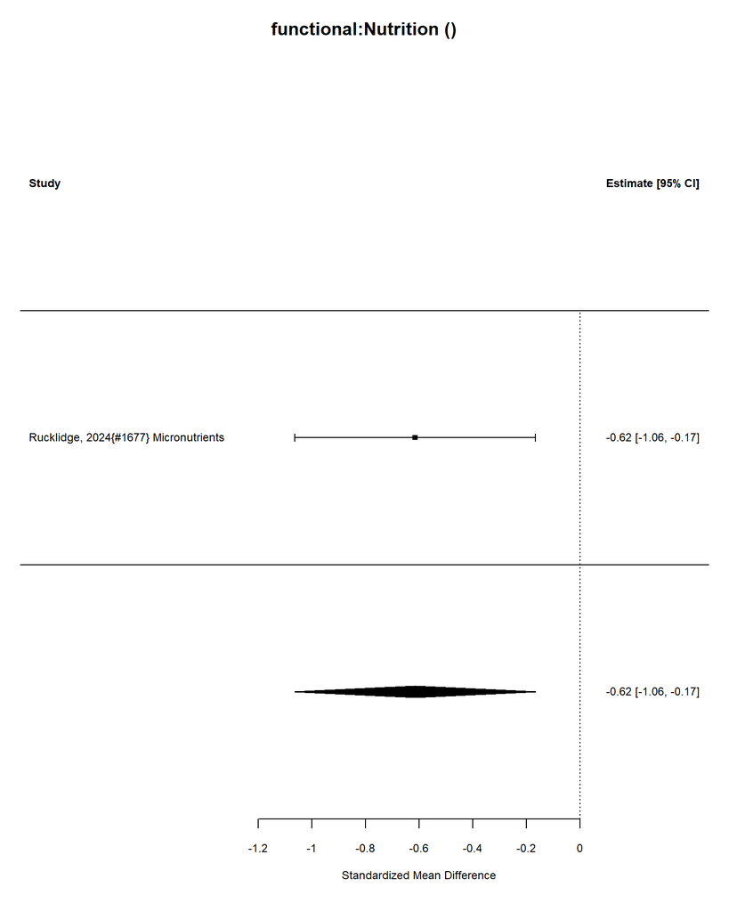

| estimate | conf.low | conf.high |
| --- | --- | --- |
| -0.62 | -1.06 | -0.17 |

Number of studies = 1

Intervention sample = 42

Control sample = 38

Total sample = 80.

I-squared = 0 %

Convert Effect Size to Real Units

Estimated effect in original units = -0.92.

### Outcome: functional:categorical Intervention: Nutrition

Outcome name: functional Analyzing 0 studies.

No data.

### Outcome: cognitive:continuous Intervention: Nutrition

No data #1.

### Outcome: cognitive:categorical Intervention: Nutrition

Outcome name: cognitive Analyzing 0 studies.

No data.

### Outcome: symptom:continuous Intervention: Nutrition

| ID | measure | mean_ctrl_cont | SD_ctrl_cont | n_ctrl_cont | mean_int_cont | SD_int_cont | n_int_cont | yi | se | study.design |
| --- | --- | --- | --- | --- | --- | --- | --- | --- | --- | --- |
| Surman 2019{#1759} 5-MTHF | AISRS (Adult ADHD Investigator Symptom Report Scale), change from baseline | 20.8 | 11.30 | 19 | 22.90 | 10.40 | 22 | -0.1902421 | 0.3138909 | RCT |
| Rucklidge, 2024{#1677} Micronutrients | CAARS (Conners’ Adult ADHD Rating Scales), self report | 70.5 | 2.30 | 38 | 67.30 | 2.20 | 42 | -1.4097547 | 0.2500932 | RCT |
| Pazoki, 2022{#7873} Saffron | ASRS (Adult ADHD Self-Report Scale) | 42.0 | 7.92 | 22 | 40.81 | 8.08 | 22 | -0.1460679 | 0.3019131 | RCT |

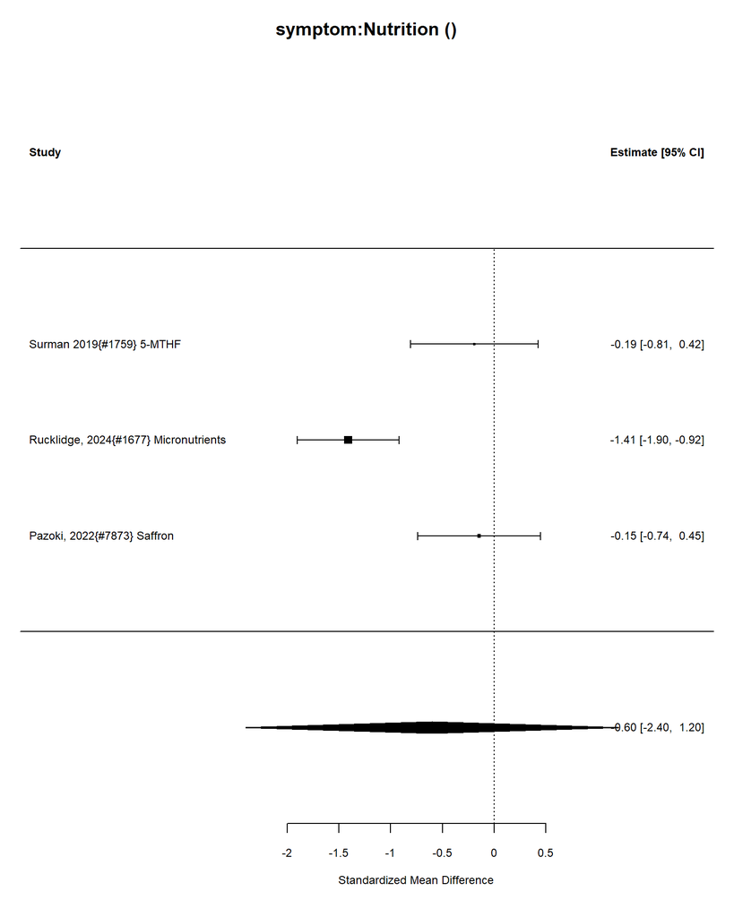

| estimate | conf.low | conf.high |
| --- | --- | --- |
| -0.6 | -2.4 | 1.2 |

Number of studies = 3

Intervention sample = 86

Control sample = 79

Total sample = 165.

I-squared = 85 %

Convert Effect Size to Real Units

Estimated effect in original units = -4.3.

##### Publication Bias Tests

###### Begg (non-parametric)

Rank Correlation Test for Funnel Plot Asymmetry Kendall’s tau = 0.3333, p = 1.0000

###### Egger (parametric)

Regression Test for Funnel Plot Asymmetry

Model: mixed-effects meta-regression model Predictor: standard error

Test for Funnel Plot Asymmetry: t = 5.3703, df = 1, p = 0.1172 Limit Estimate (as sei -> 0): b = -6.6318 (CI: -20.7332, 7.4696)

###### Trim and Fill

Estimate and Cis

|  | estimate | ci.lb | ci.ub |
| --- | --- | --- | --- |
| intrcpt | -0.6 | -2.4 | 1.2 |

### Meta-regression: stimulant vs non-stimulant

0 stimulant studies

0 nonstimulant studies

Not enough studies to compare stimulant and nonstimulant

### Meta-regression: AMPH vs MPH

### AMPH vs MPH meta-regression

0n AMPH studies

0 nMPH studies

Not enough studies to compare AMPH and MPH

## Meta-regression: Indirect comparison between combined vs(medication plus psychosocial) and medication

0 medication studies

0 combined studies

Not enough studies to compare medication and combined

## Meta-regression: Indirect comparison between combined vs(medication plus psychosocial) and psychosocial

0 psychosocial studies

0 combined studies

Not enough studies to compare psychosocial and combined

### Outcome: symptom:categorical Intervention: Nutrition

Outcome name: symptom Analyzing 2 studies.

Analyzing 2 studies.

### Control Types

| control | n |
| --- | --- |
| Placebo | 2 |

| ID | measure | yi | se | study.design |
| --- | --- | --- | --- | --- |
| Surman 2019{#1759} 5-MTHF | AISRS, reduction ≥30% | -0.01 | 0.14 | RCT |
| Rucklidge, 2024{#1677} Micronutrients | CAARS (Conners’ Adult ADHD Rating Scales), at least 30% improvement | -0.56 | 0.24 | RCT |

[figure not shown]

Number of studies = 2  
Intervention sample = 62  
Control sample = 57  
Total sample = 119

### Relative Risk Estimate

|  | estimate | se | tval | df | pval | ci.lb | ci.ub |
| --- | --- | --- | --- | --- | --- | --- | --- |
| intrcpt | 0.7788008 | 1.309964 | 0.4025242 | 2.718282 | 1.698932 | 0.024972 | 24.53253 |

I-squared = 74 %

### Outcome: substance_use:continuous Intervention: Nutrition

No data #1.

### Outcome: substance_use:categorical Intervention: Nutrition

Outcome name: substance_use Analyzing 0 studies.

No data.

### Outcome: relationship:continuous Intervention: Nutrition

No data #1.

### Outcome: relationship:categorical Intervention: Nutrition

Outcome name: relationship Analyzing 0 studies.

No data.

### Outcome: BP:continuous Intervention: Nutrition

No data #1.

### Outcome: BP:categorical Intervention: Nutrition

Outcome name: BP Analyzing 0 studies.

No data.

### Outcome: sleep_disturbance:continuous Intervention: Nutrition

No data #1.

### Outcome: sleep_disturbance:categorical Intervention: Nutrition

Outcome name: sleep_disturbance Analyzing 1 studies.

Analyzing 1 studies.